# Prosper Loan Data Exploration

## Preliminary Wrangling

#### In this project, I will be exploring the Prosper Loan Data set which contains 113,937 loans and 81 variables. I will focus on a subset of data/variables based on my research interests.

```python
# Import all packages, set up display options and set plots to be embedded inline
import numpy as np
import pandas as pd
import matplotlib.pyplot as plt
import seaborn as sb
from datetime import datetime

%matplotlib inline

# Set figure legend font size.
plt.rc('legend',**{'fontsize':12})

# Setting the options below enables Jupyter notebook to display all columns.
pd.set_option('display.max_columns', None)
pd.set_option('display.expand_frame_repr', False)
pd.set_option('max_colwidth', -1)
```

```python
# Load the dataset.
df = pd.read_csv('prosperLoanData.csv')
```

```python
# high-level overview of data shape and composition
print(df.shape)
df.sample(4)
```

```
(113937, 81)
```

|  | ListingKey | ListingNumber | ListingCreationDate | CreditGrade | Term | LoanStatus | ClosedDate | BorrowerAPR | BorrowerRate | LenderYield | EstimatedEffectiveYield | EstimatedLoss | EstimatedReturn | ProsperRating (numeric) | ProsperRating (Alpha) | ProsperScore | ListingCategory (numeric) | BorrowerState | Occupation | EmploymentStatus | EmploymentStatusDuration | IsBorrowerHomeowner | CurrentlyInGroup | GroupKey | DateCreditPulled | CreditScoreRangeLower | CreditScoreRangeUpper | FirstRecordedCreditLine | CurrentCreditLines | … |
| --- | --- | --- | --- | --- | --- | --- | --- | --- | --- | --- | --- | --- | --- | --- | --- | --- | --- | --- | --- | --- | --- | --- | --- | --- | --- | --- | --- | --- | --- | --- |
| 67698 | 94A53593715482536BA0460 | 1012949 | 2013-11-12 09:06:35.680000000 | NaN | 60 | Current | NaN | 0.27257 | 0.2469 | 0.2369 | 0.2165 | 0.1175 | 0.0990 | 3.0 | D | 4.0 | 1 | FL | Clerical | Employed | 40.0 | False | False | NaN | 2013-11-12 09:06:38 | 720.0 | 739.0 | 2001-03-02 00:00:00 | 14.0 | … |
| 11412 | 5CE235665758278105319E0 | 687873 | 2012-12-17 17:56:34 | NaN | 36 | Current | NaN | 0.29537 | 0.2566 | 0.2466 | 0.2254 | 0.1175 | 0.1079 | 3.0 | D | 7.0 | 1 | NJ | Professional | Employed | 101.0 | True | False | NaN | 2012-11-30 06:53:05 | 640.0 | 659.0 | 1994-09-26 00:00:00 | 16.0 | … |
| 86879 | DAA934207095701250C7BEF | 325748 | 2008-05-04 20:45:07.677000000 | AA | 36 | Defaulted | 2010-05-10 00:00:00 | 0.09186 | 0.0850 | 0.0750 | NaN | NaN | NaN | NaN | NaN | NaN | 7 | CO | Other | Part-time | 2.0 | True | False | NaN | 2008-05-04 20:34:49.820000000 | 780.0 | 799.0 | 1990-03-14 00:00:00 | 12.0 | … |
| 65559 | E206351085270079062B7D5 | 498220 | 2011-03-15 19:14:08.813000000 | NaN | 60 | Completed | 2012-07-24 00:00:00 | 0.31420 | 0.2899 | 0.2799 | 0.2729 | 0.1080 | 0.1649 | 3.0 | D | 7.0 | 6 | KY | Tradesman - Mechanic | Employed | 1.0 | False | False | NaN | 2011-03-15 19:13:57 | 740.0 | 759.0 | 2005-10-18 00:00:00 | 7.0 | … |

I'm interested in comparing characteristics of Defaulted loans vs non-Defaulted loans, so I first looked into the 'LoanStatus' variable to see how loan status was categorized.

```python
df.LoanStatus.value_counts()
```

```
Current                   56576
Completed                 38074
Chargedoff                11992
Defaulted                 5018
Past Due (1-15 days)      806
Past Due (31-60 days)     363
Past Due (61-90 days)     313
Past Due (91-120 days)    304
Past Due (16-30 days)     265
FinalPaymentInProgress    205
Past Due (>120 days)      16
Cancelled                 5
Name: LoanStatus, dtype: int64
```

As we can see: Loan Status has been characterized into several different categories. For this analysis, I will be focusing on loans that have been completed, charged off and defaulted. Since the Charged off loans also fall under the 'Defaulted' category, I will combine the Charged off loans with Defaulted loans (mark all 'Chargedoff' loans as 'Defaulted'). [More info about various loan status](https://help.bitbond.com/article/20-the-10-loan-status-variants-explained)

```python
# Subset the dataframe to include only "Completed", "Chargedoff", "Defaulted" loans, save in new variable 'df_sub'.
df_sub = df.query('LoanStatus in ["Completed", "Chargedoff", "Defaulted"]').copy()
```

```python
# Replace 'Chargedoff' loans with 'Defaulted'.
df_sub.LoanStatus = df_sub.LoanStatus.replace('Chargedoff', 'Defaulted')
```

```python
# Verify the replacement.
df_sub.LoanStatus.value_counts()
```

```
Completed    38074
Defaulted    17010
Name: LoanStatus, dtype: int64
```

```python
# Check for duplicated records
df_sub.duplicated().sum()
```

```
0
```

Fortunately, no duplicated records were found in the dataset.

```python
# Moving on, let's do a quick check on data types & missing values for the new dataframe 'df_sub'.
df_sub.info()
```

```
<class 'pandas.core.frame.DataFrame'>
Int64Index: 55084 entries, 0 to 113935
Data columns (total 81 columns):
ListingKey                             55084 non-null object
ListingNumber                          55084 non-null int64
ListingCreationDate                    55084 non-null object
CreditGrade                            28948 non-null object
Term                                   55084 non-null int64
LoanStatus                             55084 non-null object
ClosedDate                             55084 non-null object
BorrowerAPR                            55059 non-null float64
BorrowerRate                           55084 non-null float64
LenderYield                            55084 non-null float64
EstimatedEffectiveYield                26005 non-null float64
EstimatedLoss                          26005 non-null float64
EstimatedReturn                        26005 non-null float64
ProsperRating (numeric)                26005 non-null float64
ProsperRating (Alpha)                  26005 non-null object
ProsperScore                           26005 non-null float64
ListingCategory (numeric)              55084 non-null int64
BorrowerState                          49572 non-null object
Occupation                             52819 non-null object
EmploymentStatus                       52832 non-null object
EmploymentStatusDuration               47473 non-null float64
IsBorrowerHomeowner                    55084 non-null bool
CurrentlyInGroup                       55084 non-null bool
GroupKey                               12668 non-null object
DateCreditPulled                       55084 non-null object
CreditScoreRangeLower                  54494 non-null float64
CreditScoreRangeUpper                  54494 non-null float64
FirstRecordedCreditLine                54388 non-null object
CurrentCreditLines                     47484 non-null float64
OpenCreditLines                        47484 non-null float64
TotalCreditLinespast7years             54388 non-null float64
OpenRevolvingAccounts                  55084 non-null int64
OpenRevolvingMonthlyPayment            55084 non-null float64
InquiriesLast6Months                   54388 non-null float64
TotalInquiries                         53929 non-null float64
CurrentDelinquencies                   54388 non-null float64
AmountDelinquent                       47466 non-null float64
```

[output cut: 31 more lines]

```
LP_CustomerPayments                    55084 non-null float64
LP_CustomerPrincipalPayments           55084 non-null float64
LP_InterestandFees                     55084 non-null float64
LP_ServiceFees                         55084 non-null float64
LP_CollectionFees                      55084 non-null float64
LP_GrossPrincipalLoss                  55084 non-null float64
LP_NetPrincipalLoss                    55084 non-null float64
LP_NonPrincipalRecoverypayments        55084 non-null float64
PercentFunded                          55084 non-null float64
Recommendations                        55084 non-null int64
InvestmentFromFriendsCount             55084 non-null int64
InvestmentFromFriendsAmount            55084 non-null float64
Investors                              55084 non-null int64
dtypes: bool(3), float64(50), int64(11), object(17)
memory usage: 33.4+ MB
```

Interestingly, we see several columns such as `CreditGrade`, `EstimatedEffectiveYield` etc.. have a lot of missing values. After reviewing the [Prosper Loan variable data dictionary](https://docs.google.com/spreadsheets/d/1gDyi_L4UvIrLTEC6Wri5nbaMmkGmLQBk-Yx3z0XDEtI/edit#gid=0), I discovered the reason. It turns out that Prosper changed their rating system for loans originated after July 2009. Some new features such as 'EstimatedEffectiveYield' and 'EstimatedLoss' were also introduced after July 2009. This generates good opportunity to compare loans originated before/after July 2009.

Also, I noticed several columns have incorrect data types. As the dataset has 81 columns, I will only focus on wrangling the columns of interest and keep the unused columns for future analysis.

```python
# First, let's convert the 'ListingCreationDate' column into datetime format.
df_sub['ListingCreationDate'] = pd.to_datetime(df_sub.ListingCreationDate)
```

```python
# Next, convert the 'Term' column into object datatype.
# The reason for this conversion is that I will use the get_text() method for barchart visualization later on.
df_sub['Term'] = df_sub['Term'].astype(str)
```

```python
# Further, convert 'LoanStatus', 'CreditGrade', 'ProsperRating (Alpha)', 'Term', 'IncomeRange' into ordered categorical types.
# I will ignore the 'NC' 'CreditGrade' as I could not find any reliable information about this credit rating.

ordinal_var_dict = {'LoanStatus': ['Completed', 'Defaulted'],
                    'CreditGrade': ['HR', 'E', 'D', 'C', 'B', 'A', 'AA'],
                    'ProsperRating (Alpha)': ['HR', 'E', 'D', 'C', 'B', 'A', 'AA'],
                    'Term': ['12', '36', '60'],
                    'IncomeRange': ['Not displayed', 'Not employed', '$0', '$1-24,999',
                                    '$25,000-49,999', '$50,000-74,999', '$75,000-99,999', '$100,000+']}

for var in ordinal_var_dict:
    ordered_var = pd.api.types.CategoricalDtype(ordered = True,
                                                categories = ordinal_var_dict[var])
    df_sub[var] = df_sub[var].astype(ordered_var)
```

```python
# Moving on, I noticed there are missing values for 'DebtToIncomeRatio'.
# Select the missing values and examine the results.
df_sub[df_sub.DebtToIncomeRatio.isna()]
```

|  | ListingKey | ListingNumber | ListingCreationDate | CreditGrade | Term | LoanStatus | ClosedDate | BorrowerAPR | BorrowerRate | LenderYield | EstimatedEffectiveYield | EstimatedLoss | EstimatedReturn | ProsperRating (numeric) | ProsperRating (Alpha) | ProsperScore | ListingCategory (numeric) | BorrowerState | Occupation | EmploymentStatus | EmploymentStatusDuration | IsBorrowerHomeowner | CurrentlyInGroup | GroupKey | DateCreditPulled | CreditScoreRangeLower | CreditScoreRangeUpper | FirstRecordedCreditLine | CurrentCreditLines | … |
| --- | --- | --- | --- | --- | --- | --- | --- | --- | --- | --- | --- | --- | --- | --- | --- | --- | --- | --- | --- | --- | --- | --- | --- | --- | --- | --- | --- | --- | --- | --- |
| 78 | 0DFE3425061927556BB8A75 | 359657 | 2008-06-29 23:23:40.157 | A | 36 | Defaulted | 2009-04-09 00:00:00 | 0.18454 | 0.1700 | 0.1600 | NaN | NaN | NaN | NaN | NaN | NaN | 3 | CA | Realtor | Full-time | 68.0 | True | False | NaN | 2008-06-29 23:13:04.860000000 | 720.0 | 739.0 | 1995-11-29 00:00:00 | 14.0 | … |
| 100 | 0F67356860455769574096F | 704916 | 2013-01-25 11:48:26.040 | NaN | 36 | Defaulted | 2013-08-30 00:00:00 | 0.35356 | 0.3134 | 0.3034 | 0.27600 | 0.1575 | 0.11850 | 1.0 | HR | 3.0 | 13 | CA | Other | Not employed | 12.0 | False | False | NaN | 2013-01-11 12:10:13 | 720.0 | 739.0 | 2000-09-10 00:00:00 | 3.0 | … |
| 103 | 0F843543787869030F017F8 | 579737 | 2012-04-17 11:58:52.270 | NaN | 36 | Defaulted | 2013-03-22 00:00:00 | 0.26681 | 0.2287 | 0.2187 | 0.21340 | 0.0990 | 0.11440 | 3.0 | D | 2.0 | 3 | CO | Truck Driver | Self-employed | 29.0 | True | False | NaN | 2012-04-17 11:58:46 | 680.0 | 699.0 | 1993-10-26 00:00:00 | 9.0 | … |
| 105 | 0F873523720624525E00B20 | 521989 | 2011-08-16 20:24:41.713 | NaN | 36 | Defaulted | 2012-04-01 00:00:00 | 0.30532 | 0.2699 | 0.2599 | 0.25340 | 0.1120 | 0.14140 | 3.0 | D | 6.0 | 6 | WI | Sales - Commission | Employed | 1.0 | False | False | NaN | 2011-08-01 09:40:14 | 640.0 | 659.0 | 2003-05-05 00:00:00 | 4.0 | … |
| 108 | 10C034203841683992703F1 | 321000 | 2008-04-29 08:26:00.340 | C | 36 | Completed | 2011-03-17 00:00:00 | 0.28320 | 0.2600 | 0.2500 | NaN | NaN | NaN | NaN | NaN | NaN | 1 | GA | Executive | Full-time | 27.0 | False | False | NaN | 2008-04-17 18:17:49.897000000 | 640.0 | 659.0 | 2001-06-22 00:00:00 | 11.0 | … |
| 131 | 11193430644352832E11281 | 396451 | 2008-09-11 03:34:20.130 | A | 36 | Completed | 2011-09-23 00:00:00 | 0.20623 | 0.1915 | 0.1815 | NaN | NaN | NaN | NaN | NaN | NaN | 1 | SC | Other | Part-time | 13.0 | False | False | NaN | 2008-09-11 03:33:56.223000000 | 740.0 | 759.0 | 1995-06-01 00:00:00 | 7.0 | … |
| 170 | 34D1354489785280859E146 | 578652 | 2012-04-14 05:39:18.747 | NaN | 36 | Completed | 2012-07-26 00:00:00 | 0.28851 | 0.2499 | 0.2399 | 0.23400 | 0.1190 | 0.11500 | 3.0 | D | 5.0 | 7 | FL | Other | Not employed | 9.0 | True | False | NaN | 2012-04-11 06:52:37 | 760.0 | 779.0 | 1985-12-01 00:00:00 | 7.0 | … |
| 185 | 2D593491034220560C1708E | 469092 | 2010-07-29 16:13:12.967 | NaN | 36 | Defaulted | 2012-05-10 00:00:00 | 0.27119 | 0.2365 | 0.2265 | 0.13410 | 0.0870 | 0.13410 | 4.0 | C | 6.0 | 1 | CA | Teacher | Self-employed | 3.0 | True | False | NaN | 2010-07-07 14:35:37 | 860.0 | 879.0 | 1999-10-08 00:00:00 | 5.0 | … |
| 186 | 2D59353745185472301C839 | 556219 | 2012-02-03 05:13:30.487 | NaN | 36 | Defaulted | 2013-09-15 00:00:00 | 0.35797 | 0.3177 | 0.3077 | 0.28960 | 0.1650 | 0.12460 | 1.0 | HR | 5.0 | 2 | MD | Other | Not employed | 7.0 | False | False | NaN | 2012-02-03 05:13:24 | 660.0 | 679.0 | 1979-03-01 00:00:00 | 3.0 | … |
| 218 | 10583571884290224529BF5 | 724719 | 2013-03-07 15:46:17.840 | NaN | 36 | Defaulted | 2014-01-18 00:00:00 | 0.19236 | 0.1559 | 0.1459 | 0.13820 | 0.0524 | 0.08580 | 5.0 | B | 4.0 | 1 | WA | Other | Self-employed | 26.0 | True | False | NaN | 2013-03-07 15:46:14 | 720.0 | 739.0 | 1996-09-18 00:00:00 | 5.0 | … |
| 255 | 300534705117226858F0631 | 439062 | 2009-12-18 13:45:45.153 | NaN | 36 | Completed | 2013-01-15 00:00:00 | 0.26079 | 0.2379 | 0.2279 | 0.12230 | 0.1000 | 0.12230 | 3.0 | D | 7.0 | 7 | AL | Computer Programmer | Full-time | 46.0 | False | False | NaN | 2009-12-18 13:37:24 | 660.0 | 679.0 | 2005-01-31 00:00:00 | 4.0 | … |
| 303 | 008C3508301726590943A48 | 493365 | 2011-02-10 11:31:37.840 | NaN | 36 | Defaulted | 2011-08-16 00:00:00 | 0.30532 | 0.2699 | 0.2599 | 0.25340 | 0.1080 | 0.14540 | 3.0 | D | 6.0 | 1 | CA | Architect | Self-employed | 18.0 | False | False | NaN | 2011-02-10 11:31:30 | 660.0 | 679.0 | 1998-12-01 00:00:00 | 4.0 | … |
| 330 | 08E134244479824305E38AA | 361026 | 2008-07-02 10:32:23.160 | B | 36 | Defaulted | 2010-12-10 00:00:00 | 0.15377 | 0.1395 | 0.1295 | NaN | NaN | NaN | NaN | NaN | NaN | 2 | NY | Executive | Self-employed | 158.0 | True | False | NaN | 2008-07-02 10:26:20.010000000 | 680.0 | 699.0 | 1990-05-01 00:00:00 | 8.0 | … |
| 335 | 00AD35425251122022457F4 | 570039 | 2012-03-19 00:16:29.950 | NaN | 36 | Completed | 2012-10-19 00:00:00 | 0.35797 | 0.3177 | 0.3077 | 0.28960 | 0.1650 | 0.12460 | 1.0 | HR | 3.0 | 7 | NJ | Other | Not employed | 2.0 | False | False | NaN | 2012-03-19 00:16:25 | 760.0 | 779.0 | 2007-02-23 00:00:00 | 1.0 | … |
| 354 | 09543466789756942ED5B40 | 430051 | 2009-10-24 06:33:50.757 | NaN | 36 | Completed | 2013-05-26 00:00:00 | 0.37699 | 0.3400 | 0.3300 | 0.07050 | 0.2400 | 0.07050 | 1.0 | HR | 2.0 | 3 | CO | Truck Driver | Self-employed | 1.0 | False | False | NaN | 2010-11-16 00:07:25 | 640.0 | 659.0 | 2000-06-28 00:00:00 | 9.0 | … |
| 372 | 314E34271460439110FA9B2 | 372402 | 2008-07-23 21:09:47.293 | D | 36 | Defaulted | 2010-07-31 00:00:00 | 0.37453 | 0.3500 | 0.3400 | NaN | NaN | NaN | NaN | NaN | NaN | 1 | MI | Postal Service | Full-time | 33.0 | True | False | NaN | 2008-06-26 21:24:13.477000000 | 600.0 | 619.0 | 1997-10-18 00:00:00 | 14.0 | … |
| 390 | 410A3519266917711582802 | 515071 | 2011-07-06 13:53:21.627 | NaN | 36 | Completed | 2013-01-04 00:00:00 | 0.30532 | 0.2699 | 0.2599 | 0.25340 | 0.1120 | 0.14140 | 3.0 | D | 5.0 | 7 | CT | Professional | Self-employed | 110.0 | True | False | NaN | 2011-07-06 13:53:17 | 740.0 | 759.0 | 1997-05-01 00:00:00 | 8.0 | … |
| 395 | 412934312165894856C0F8B | 391113 | 2008-08-31 20:19:33.923 | AA | 36 | Completed | 2009-05-04 00:00:00 | 0.15512 | 0.1480 | 0.1380 | NaN | NaN | NaN | NaN | NaN | NaN | 7 | WI | Other | Self-employed | 37.0 | True | False | NaN | 2008-08-31 20:19:22.613000000 | 760.0 | 779.0 | 2001-05-25 00:00:00 | 13.0 | … |
| 429 | 44BF34322836122899CEBC2 | 402325 | 2008-09-22 12:13:00.897 | AA | 36 | Completed | 2010-12-31 00:00:00 | 0.23748 | 0.2300 | 0.2200 | NaN | NaN | NaN | NaN | NaN | NaN | 3 | VA | Principal | Self-employed | 79.0 | True | False | NaN | 2008-09-24 08:44:58.640000000 | 840.0 | 859.0 | 1987-02-01 00:00:00 | 8.0 | … |
| 432 | 01013430425290444C60735 | 390737 | 2008-08-30 15:17:30.877 | AA | 36 | Completed | 2011-03-29 00:00:00 | 0.08001 | 0.0629 | 0.0529 | NaN | NaN | NaN | NaN | NaN | NaN | 7 | OK | Other | Self-employed | 7.0 | False | False | NaN | 2008-08-30 15:17:17.123000000 | 760.0 | 779.0 | 1984-09-07 00:00:00 | 1.0 | … |
| 493 | 450B35441332938961FF323 | 577569 | 2012-04-11 09:39:53.360 | NaN | 36 | Defaulted | 2012-10-17 00:00:00 | 0.35797 | 0.3177 | 0.3077 | 0.28960 | 0.1650 | 0.12460 | 1.0 | HR | 4.0 | 1 | NJ | Other | Other | 21.0 | False | False | NaN | 2012-04-11 09:39:49 | 700.0 | 719.0 | 2000-06-27 00:00:00 | 9.0 | … |
| 497 | 45133492295495646AB7671 | 470568 | 2010-08-08 14:26:15.410 | NaN | 36 | Completed | 2011-06-21 00:00:00 | 0.31053 | 0.2750 | 0.2650 | 0.15040 | 0.1080 | 0.15040 | 3.0 | D | 6.0 | 3 | WA | Other | Retired | 39.0 | True | False | NaN | 2010-08-06 17:24:02 | 760.0 | 779.0 | 2000-10-18 00:00:00 | 10.0 | … |
| 561 | 00E9357631185472594BC5A | 746763 | 2013-04-08 11:30:47.260 | NaN | 36 | Completed | 2013-10-17 00:00:00 | 0.25781 | 0.2199 | 0.2099 | 0.19370 | 0.0925 | 0.10120 | 3.0 | D | 2.0 | 18 | TX | Other | Employed | 37.0 | True | False | NaN | 2013-04-08 11:30:44 | 660.0 | 679.0 | 1999-08-11 00:00:00 | 5.0 | … |
| 565 | 32563595673920080D07C8A | 1030928 | 2013-11-24 12:10:49.083 | NaN | 60 | Completed | 2014-02-24 00:00:00 | 0.24856 | 0.2235 | 0.2135 | 0.19571 | 0.1075 | 0.08821 | 3.0 | D | 4.0 | 1 | CO | Homemaker | Self-employed | 1.0 | False | False | NaN | 2013-11-24 12:10:52 | 660.0 | 679.0 | 1984-05-01 00:00:00 | 9.0 | … |
| 575 | 3C0735689465562535178E3 | 696973 | 2013-01-09 13:50:08.893 | NaN | 60 | Completed | 2014-01-30 00:00:00 | 0.32321 | 0.2962 | 0.2862 | 0.26100 | 0.1275 | 0.13350 | 2.0 | E | 6.0 | 1 | FL | Truck Driver | Employed | 3.0 | False | False | NaN | 2013-01-06 13:06:51 | 620.0 | 639.0 | 2005-05-26 00:00:00 | 10.0 | … |
| 608 | 00D53487827278990464FBA | 463422 | 2010-06-18 20:12:31.137 | NaN | 36 | Completed | 2010-07-14 00:00:00 | 0.07439 | 0.0710 | 0.0610 | 0.05500 | 0.0060 | 0.05500 | 7.0 | AA | 10.0 | 2 | FL | Attorney | Full-time | 200.0 | True | False | NaN | 2010-06-18 20:12:26 | 820.0 | 839.0 | 1969-02-20 00:00:00 | 11.0 | … |
| 634 | 08033527874827419A0CBFD | 530332 | 2011-09-30 09:00:14.257 | NaN | 36 | Completed | 2013-03-26 00:00:00 | 0.34887 | 0.3125 | 0.3025 | 0.28480 | 0.1700 | 0.11480 | 1.0 | HR | 1.0 | 3 | MO | Other | Self-employed | 46.0 | False | False | NaN | 2011-09-20 08:42:40 | 640.0 | 659.0 | 1992-03-10 00:00:00 | 9.0 | … |
| 688 | 3CDE3504358322133D73C12 | 489339 | 2010-12-29 15:01:49.863 | NaN | 36 | Completed | 2011-12-22 00:00:00 | 0.30532 | 0.2699 | 0.2599 | 0.25340 | 0.1120 | 0.14140 | 3.0 | D | 7.0 | 7 | WA | Other | Not employed | 23.0 | False | False | NaN | 2011-07-17 16:38:41 | 720.0 | 739.0 | 2001-03-10 00:00:00 | 5.0 | … |
| 725 | 0A333418840357177C59FEC | 319423 | 2008-04-27 19:21:57.207 | NaN | 36 | Completed | 2011-11-22 00:00:00 | 0.10082 | 0.0800 | 0.0700 | NaN | NaN | NaN | NaN | NaN | NaN | 1 | OH | Food Service Management | Full-time | 37.0 | False | True | 72043366788878145C82141 | 2009-10-22 11:37:32 | 740.0 | 759.0 | 2003-12-26 00:00:00 | 5.0 | … |
| 728 | 3D133460840417887C06DE0 | 420162 | 2009-08-11 15:30:38.663 | NaN | 36 | Completed | 2012-05-11 00:00:00 | 0.39153 | 0.3500 | 0.3400 | 0.18430 | 0.1400 | 0.18430 | 2.0 | E | 6.0 | 3 | PA | Professional | Self-employed | 70.0 | True | False | NaN | 2009-07-30 06:31:01 | 660.0 | 679.0 | 1990-06-01 00:00:00 | 3.0 | … |
| ... | ... | ... | ... | ... | ... | ... | ... | ... | ... | ... | ... | ... | ... | ... | ... | ... | ... | ... | ... | ... | ... | ... | ... | ... | ... | ... | ... | ... | ... | … |
| 113466 | F62435472409911835E3D58 | 590864 | 2012-05-19 09:11:22.590 | NaN | 36 | Completed | 2013-01-15 00:00:00 | 0.25259 | 0.2148 | 0.2048 | 0.20000 | 0.0890 | 0.11100 | 4.0 | C | 6.0 | 1 | UT | Other | Other | 0.0 | True | False | NaN | 2012-05-19 09:11:18 | 740.0 | 759.0 | 1993-11-29 00:00:00 | 7.0 | … |
| 113481 | F6813535768596942033AE4 | 548972 | 2012-01-04 16:16:28.030 | NaN | 36 | Completed | 2012-08-24 00:00:00 | 0.35285 | 0.3127 | 0.3027 | 0.28500 | 0.1650 | 0.12000 | 1.0 | HR | 2.0 | 3 | OH | Other | Self-employed | 126.0 | True | False | NaN | 2012-01-04 16:16:23 | 740.0 | 759.0 | 1995-11-15 00:00:00 | 10.0 | … |
| 113485 | DA153422134287105784C7D | 341388 | 2008-05-29 19:20:20.503 | B | 36 | Completed | 2011-06-09 00:00:00 | 0.18756 | 0.1730 | 0.1630 | NaN | NaN | NaN | NaN | NaN | NaN | 4 | GA | Skilled Labor | Full-time | 12.0 | True | False | NaN | 2008-05-29 18:27:16.033000000 | 680.0 | 699.0 | 2001-01-01 00:00:00 | 7.0 | … |
| 113503 | F6603476725567851F722F8 | 446127 | 2010-02-09 21:35:14.517 | NaN | 36 | Defaulted | 2011-02-24 00:00:00 | 0.36438 | 0.3400 | 0.3300 | 0.22160 | 0.1000 | 0.22160 | 3.0 | D | 7.0 | 7 | OK | Professional | Full-time | 0.0 | False | False | NaN | 2010-02-09 21:20:02 | 760.0 | 779.0 | 1987-10-19 00:00:00 | 2.0 | … |
| 113508 | F6793430004356250613A30 | 385561 | 2008-08-20 08:44:19.070 | AA | 36 | Defaulted | 2009-05-29 00:00:00 | 0.33172 | 0.3238 | 0.3138 | NaN | NaN | NaN | NaN | NaN | NaN | 7 | CA | Executive | Full-time | 91.0 | True | False | NaN | 2008-08-20 08:43:21.553000000 | 760.0 | 779.0 | 1994-11-21 00:00:00 | 15.0 | … |
| 113521 | DA473525288513997A256AA | 525275 | 2011-09-03 05:57:10.990 | NaN | 36 | Completed | 2011-11-16 00:00:00 | 0.34887 | 0.3125 | 0.3025 | 0.28480 | 0.1700 | 0.11480 | 1.0 | HR | 1.0 | 3 | FL | Construction | Self-employed | 315.0 | True | False | NaN | 2011-09-03 05:57:08 | 660.0 | 679.0 | 1986-02-01 00:00:00 | 11.0 | … |
| 113541 | D8FF34246098289569ECC6D | 361914 | 2008-07-03 19:57:05.290 | D | 36 | Completed | 2011-06-10 00:00:00 | 0.37453 | 0.3500 | 0.3400 | NaN | NaN | NaN | NaN | NaN | NaN | 7 | CA | Military Enlisted | Full-time | 48.0 | False | False | NaN | 2008-07-03 19:39:21.590000000 | 600.0 | 619.0 | 2005-08-21 00:00:00 | 7.0 | … |
| 113550 | FB7C34891738372088EBDF1 | 468279 | 2010-07-23 18:47:30.520 | NaN | 36 | Completed | 2013-06-13 00:00:00 | 0.23682 | 0.1990 | 0.1890 | 0.11960 | 0.0650 | 0.11960 | 4.0 | C | 9.0 | 1 | OH | Other | Part-time | 12.0 | False | False | NaN | 2010-07-23 18:47:26 | 640.0 | 659.0 | 1994-10-04 00:00:00 | 16.0 | … |
| 113552 | FB90348340286522525FB81 | 456267 | 2010-04-29 13:09:41.957 | NaN | 36 | Completed | 2010-08-03 00:00:00 | 0.23631 | 0.1985 | 0.1885 | 0.11910 | 0.0650 | 0.11910 | 4.0 | C | 9.0 | 5 | NC | Other | Full-time | 45.0 | True | False | NaN | 2010-04-29 12:59:15 | 640.0 | 659.0 | 2002-05-30 00:00:00 | 9.0 | … |
| 113600 | FBAA3540555507788BE5D3B | 567077 | 2012-03-10 12:31:05.980 | NaN | 36 | Completed | 2013-12-31 00:00:00 | 0.28370 | 0.2452 | 0.2352 | 0.22940 | 0.1190 | 0.11040 | 3.0 | D | 5.0 | 2 | OR | Other | Other | 51.0 | False | False | NaN | 2012-03-10 12:31:01 | 720.0 | 739.0 | 1976-09-01 00:00:00 | 13.0 | … |
| 113608 | CA873521306712899AD8000 | 517677 | 2011-07-21 20:39:21.660 | NaN | 60 | Defaulted | 2012-03-30 00:00:00 | 0.24252 | 0.2199 | 0.2099 | 0.20500 | 0.0610 | 0.14400 | 4.0 | C | 6.0 | 1 | GA | Sales - Commission | Employed | 8.0 | False | False | NaN | 2011-07-21 20:39:16 | 660.0 | 679.0 | 1987-04-23 00:00:00 | 14.0 | … |
| 113617 | C2493464219717831D1AE7D | 426289 | 2009-09-29 12:46:07.890 | NaN | 36 | Completed | 2010-02-02 00:00:00 | 0.37453 | 0.3500 | 0.3400 | -0.02510 | 0.3450 | -0.02510 | 1.0 | HR | 1.0 | 3 | TX | Sales - Retail | Self-employed | 29.0 | True | False | NaN | 2009-09-10 11:12:07 | 640.0 | 659.0 | 2004-05-27 00:00:00 | 2.0 | … |
| 113622 | C25C3536501353932589E51 | 551280 | 2012-01-13 10:19:31.653 | NaN | 36 | Defaulted | 2012-09-02 00:00:00 | 0.34577 | 0.3058 | 0.2958 | 0.28220 | 0.1470 | 0.13520 | 2.0 | E | 6.0 | 7 | OR | Other | Not employed | 10.0 | False | False | NaN | 2012-01-13 10:19:28 | 640.0 | 659.0 | 1999-10-01 00:00:00 | 4.0 | … |
| 113628 | DFB83585217775225F1862A | 856007 | 2013-07-30 17:50:33.003 | NaN | 60 | Completed | 2013-10-01 00:00:00 | 0.24589 | 0.2209 | 0.2109 | 0.19570 | 0.0824 | 0.11330 | 4.0 | C | 3.0 | 7 | CT | Professional | Self-employed | 134.0 | True | False | NaN | 2013-07-30 17:50:11 | 740.0 | 759.0 | 1997-05-01 00:00:00 | 13.0 | … |
| 113672 | CCCD3545860388538EEDD70 | 580671 | 2012-04-20 09:52:45.413 | NaN | 36 | Completed | 2013-07-24 00:00:00 | 0.35797 | 0.3177 | 0.3077 | 0.28960 | 0.1650 | 0.12460 | 1.0 | HR | 2.0 | 1 | GA | Sales - Commission | Self-employed | 20.0 | True | False | NaN | 2012-04-20 09:52:39 | 760.0 | 779.0 | 1999-01-14 00:00:00 | 7.0 | … |
| 113682 | FDA5353588009083364115D | 550857 | 2012-01-11 15:43:17.020 | NaN | 60 | Defaulted | 2013-02-16 00:00:00 | 0.32680 | 0.2997 | 0.2897 | 0.28240 | 0.1190 | 0.16340 | 3.0 | D | 5.0 | 1 | PA | Other | Not employed | 87.0 | True | False | NaN | 2011-04-12 10:30:34 | 760.0 | 779.0 | 1967-02-01 00:00:00 | 14.0 | … |
| 113686 | FDD83406389901620745200 | 244319 | 2007-12-04 18:18:14.747 | A | 36 | Completed | 2008-09-24 00:00:00 | 0.21588 | 0.2085 | 0.1985 | NaN | NaN | NaN | NaN | NaN | NaN | 0 | CA | Other | Full-time | 26.0 | False | False | NaN | 2007-11-26 11:36:18.257000000 | 740.0 | 759.0 | 1999-09-16 00:00:00 | 1.0 | … |
| 113689 | E1FA3555618980253B5578E | 623670 | 2012-08-13 14:17:53.500 | NaN | 12 | Completed | 2013-08-20 00:00:00 | 0.29901 | 0.2199 | 0.2099 | 0.20050 | 0.1325 | 0.06800 | 2.0 | E | 1.0 | 3 | AR | Executive | Self-employed | 16.0 | True | False | NaN | 2012-08-13 14:17:50 | 680.0 | 699.0 | 1972-01-01 00:00:00 | 16.0 | … |
| 113704 | C49234285929885832A3A62 | 380216 | 2008-08-09 11:06:48.420 | D | 36 | Completed | 2011-08-15 00:00:00 | 0.05104 | 0.0500 | 0.0400 | NaN | NaN | NaN | NaN | NaN | NaN | 6 | TX | Other | Full-time | 6.0 | False | False | NaN | 2008-07-28 19:22:58.007000000 | 620.0 | 639.0 | 2001-12-26 00:00:00 | 5.0 | … |
| 113711 | DC083429979529800792FA6 | 389465 | 2008-08-27 18:44:17.027 | C | 36 | Completed | 2011-09-05 00:00:00 | 0.25278 | 0.2300 | 0.2100 | NaN | NaN | NaN | NaN | NaN | NaN | 2 | CO | Tradesman - Mechanic | Self-employed | 27.0 | True | False | NaN | 2008-08-27 18:44:01.527000000 | 660.0 | 679.0 | 1991-09-01 00:00:00 | 7.0 | … |
| 113725 | FDE13471061587426103C01 | 438981 | 2009-12-18 05:33:23.383 | NaN | 36 | Completed | 2012-10-31 00:00:00 | 0.11323 | 0.0840 | 0.0740 | 0.05290 | 0.0210 | 0.05290 | 6.0 | A | 9.0 | 1 | GA | Other | Part-time | 60.0 | False | False | NaN | 2009-12-13 13:31:48 | 700.0 | 719.0 | 2000-04-10 00:00:00 | 11.0 | … |
| 113767 | DE48341184370727282B3F4 | 269403 | 2008-01-22 07:15:09.207 | HR | 36 | Defaulted | 2009-06-05 00:00:00 | 0.36945 | 0.3450 | 0.3350 | NaN | NaN | NaN | NaN | NaN | NaN | 3 | NC | Other | Self-employed | 22.0 | False | True | 9BBE337094173775621CD34 | 2008-01-10 11:01:03.310000000 | 520.0 | 539.0 | 2002-08-29 00:00:00 | 0.0 | … |
| 113792 | E43C3548328183436FD70FD | 592262 | 2012-05-23 15:08:31.490 | NaN | 36 | Completed | 2013-11-05 00:00:00 | 0.26681 | 0.2287 | 0.2187 | 0.21340 | 0.0990 | 0.11440 | 3.0 | D | 3.0 | 1 | MO | Sales - Commission | Self-employed | 114.0 | True | False | NaN | 2012-05-23 15:08:28 | 680.0 | 699.0 | 1984-07-01 00:00:00 | 20.0 | … |
| 113803 | DEA93427782854712C73CB8 | 376274 | 2008-08-01 01:42:00.820 | B | 36 | Defaulted | 2010-08-12 00:00:00 | 0.11293 | 0.0990 | 0.0890 | NaN | NaN | NaN | NaN | NaN | NaN | 7 | CA | Sales - Retail | Self-employed | 34.0 | True | True | 8BAB34083705675975C9772 | 2008-08-01 01:40:12.270000000 | 680.0 | 699.0 | 1988-08-01 00:00:00 | 11.0 | … |
| 113836 | E4B6348994332478452DDF2 | 467776 | 2010-07-22 06:55:00.673 | NaN | 36 | Completed | 2013-06-30 00:00:00 | 0.23794 | 0.2001 | 0.1901 | 0.12070 | 0.0650 | 0.12070 | 4.0 | C | 9.0 | 3 | WA | Truck Driver | Self-employed | 267.0 | True | False | NaN | 2010-07-08 15:38:00 | 640.0 | 659.0 | 1992-07-22 00:00:00 | 14.0 | … |
| 113848 | FFF0338012502972731B2C1 | 94872 | 2007-02-07 15:04:40.563 | NaN | 36 | Completed | 2010-02-13 00:00:00 | 0.30709 | 0.2875 | 0.2825 | NaN | NaN | NaN | NaN | NaN | NaN | 0 | NaN | Administrative Assistant | Not available | NaN | False | False | NaN | 2007-01-27 21:05:41.030000000 | 0.0 | 19.0 | NaN | NaN | … |
| 113866 | C9563467992330262C23724 | 433774 | 2009-11-16 19:11:53.663 | NaN | 36 | Completed | 2010-01-12 00:00:00 | 0.20504 | 0.1829 | 0.1729 | -0.18160 | 0.3450 | -0.18160 | 1.0 | HR | 1.0 | 3 | OR | Truck Driver | Self-employed | 153.0 | False | True | 3D4D3366260257624AB272D | 2009-10-19 18:56:09 | 640.0 | 659.0 | 1983-04-27 00:00:00 | 11.0 | … |
| 113894 | E32734699821101105178D8 | 438537 | 2009-12-15 18:50:46.193 | NaN | 36 | Completed | 2010-02-26 00:00:00 | 0.07339 | 0.0700 | 0.0600 | 0.05400 | 0.0060 | 0.05400 | 7.0 | AA | 10.0 | 3 | VA | Investor | Full-time | 4.0 | True | False | NaN | 2009-12-15 18:44:41 | 800.0 | 819.0 | 2003-07-15 00:00:00 | 10.0 | … |
| 113899 | E6BB34788205132176FCDD9 | 449436 | 2010-03-08 20:48:58.387 | NaN | 36 | Completed | 2013-03-18 00:00:00 | 0.11296 | 0.0920 | 0.0820 | 0.06080 | 0.0210 | 0.06080 | 6.0 | A | 8.0 | 3 | CA | Military Enlisted | Full-time | 51.0 | False | False | NaN | 2010-03-08 20:46:31 | 760.0 | 779.0 | 2000-07-18 00:00:00 | 8.0 | … |
| 113908 | C9843500054876019D611A1 | 486057 | 2010-11-29 10:40:09.730 | NaN | 36 | Completed | 2011-01-31 00:00:00 | 0.35858 | 0.3220 | 0.3120 | 0.15570 | 0.1420 | 0.15570 | 2.0 | E | 5.0 | 3 | NY | Sales - Commission | Employed | 68.0 | False | False | NaN | 2010-11-22 20:51:48 | 700.0 | 719.0 | 2005-09-26 00:00:00 | 17.0 | … |

4230 rows × 81 columns

It seems that most of the loans with Null 'DebtToIncomeRatio' also could not verify their income ('IncomeVerifiable' is 'False'). This makes sense because if the borrower's income could not be verified, their 'DebtToIncomeRatio' results may also be unreliable. For the purpose of this analysis, I will drop all records with missing 'DebtToIncomeRatio' as below.

```python
# create a mask and use it to select records with not null 'DebtToIncomeRatio'.
mask = df_sub.DebtToIncomeRatio.notna()
df_sub = df_sub.loc[mask, :]
```

```python
# Further check to see if there are any records with non-varifialble income.
df_sub.IncomeVerifiable.value_counts()
```

```
True     50622
False    232
Name: IncomeVerifiable, dtype: int64
```

```python
# Let's drop these 'False' records as well.
mask2 = df_sub.IncomeVerifiable != False
df_sub = df_sub.loc[mask2, :]
```

```python
# Next, a quick check on summary statistics of numerical columns.
df_sub.describe()
```

|  | ListingNumber | BorrowerAPR | BorrowerRate | LenderYield | EstimatedEffectiveYield | EstimatedLoss | EstimatedReturn | ProsperRating (numeric) | ProsperScore | ListingCategory (numeric) | EmploymentStatusDuration | CreditScoreRangeLower | CreditScoreRangeUpper | CurrentCreditLines | OpenCreditLines | TotalCreditLinespast7years | OpenRevolvingAccounts | OpenRevolvingMonthlyPayment | InquiriesLast6Months | TotalInquiries | CurrentDelinquencies | AmountDelinquent | DelinquenciesLast7Years | PublicRecordsLast10Years | PublicRecordsLast12Months | RevolvingCreditBalance | BankcardUtilization | AvailableBankcardCredit | TotalTrades | … |
| --- | --- | --- | --- | --- | --- | --- | --- | --- | --- | --- | --- | --- | --- | --- | --- | --- | --- | --- | --- | --- | --- | --- | --- | --- | --- | --- | --- | --- | --- | --- |
| count | 5.062200e+04 | 50597.000000 | 50622.000000 | 50622.000000 | 23032.000000 | 23032.000000 | 23032.000000 | 23032.000000 | 23032.000000 | 50622.000000 | 43216.000000 | 50048.000000 | 50048.000000 | 43221.000000 | 43221.000000 | 50048.000000 | 50622.000000 | 50622.00000 | 50048.000000 | 49504.000000 | 50048.000000 | 43223.000000 | 49763.000000 | 50048.000000 | 43221.000000 | 4.322100e+04 | 43221.000000 | 43279.000000 | 43279.000000 | … |
| mean | 3.618085e+05 | 0.218736 | 0.197572 | 0.187435 | 0.172903 | 0.090821 | 0.106519 | 3.763546 | 6.420936 | 2.313263 | 82.379535 | 670.509511 | 689.509511 | 9.675227 | 8.415909 | 25.539242 | 6.093694 | 322.75319 | 2.104759 | 7.352497 | 0.951766 | 1086.069037 | 4.740289 | 0.340473 | 0.024409 | 1.549580e+04 | 0.536195 | 10621.179902 | 22.085261 | … |
| std | 2.149907e+05 | 0.087266 | 0.080679 | 0.080076 | 0.080368 | 0.054379 | 0.037933 | 1.814772 | 2.280720 | 3.362038 | 84.873552 | 79.808627 | 79.808627 | 5.592494 | 4.991171 | 14.304765 | 4.543151 | 442.37975 | 3.192681 | 8.337088 | 2.670320 | 6842.895425 | 10.872717 | 0.798528 | 0.183496 | 3.337862e+04 | 0.351153 | 21369.584356 | 12.474657 | … |
| min | 4.000000e+00 | 0.006530 | 0.000000 | -0.010000 | -0.181600 | 0.004900 | -0.181600 | 1.000000 | 1.000000 | 0.000000 | 0.000000 | 0.000000 | 19.000000 | 0.000000 | 0.000000 | 2.000000 | 0.000000 | 0.00000 | 0.000000 | 0.000000 | 0.000000 | 0.000000 | 0.000000 | 0.000000 | 0.000000 | 0.000000e+00 | 0.000000 | 0.000000 | 0.000000 | … |
| 25% | 1.728068e+05 | 0.147090 | 0.131425 | 0.122400 | 0.105175 | 0.049900 | 0.077100 | 2.000000 | 5.000000 | 0.000000 | 22.000000 | 620.000000 | 639.000000 | 6.000000 | 5.000000 | 15.000000 | 3.000000 | 60.00000 | 0.000000 | 2.000000 | 0.000000 | 0.000000 | 0.000000 | 0.000000 | 0.000000 | 1.648000e+03 | 0.220000 | 494.000000 | 13.000000 | … |
| 50% | 3.735335e+05 | 0.208150 | 0.190000 | 0.179900 | 0.166900 | 0.089000 | 0.111500 | 4.000000 | 7.000000 | 1.000000 | 54.000000 | 680.000000 | 699.000000 | 9.000000 | 8.000000 | 24.000000 | 5.000000 | 184.00000 | 1.000000 | 5.000000 | 0.000000 | 0.000000 | 0.000000 | 0.000000 | 0.000000 | 6.118000e+03 | 0.570000 | 3138.000000 | 20.000000 | … |
| 75% | 5.194658e+05 | 0.293340 | 0.262500 | 0.252400 | 0.243700 | 0.130000 | 0.135700 | 5.000000 | 8.000000 | 3.000000 | 114.000000 | 720.000000 | 739.000000 | 13.000000 | 11.000000 | 34.000000 | 8.000000 | 417.00000 | 3.000000 | 9.000000 | 1.000000 | 0.000000 | 4.000000 | 0.000000 | 0.000000 | 1.612600e+04 | 0.850000 | 11766.500000 | 29.000000 | … |
| max | 1.204824e+06 | 0.512290 | 0.497500 | 0.492500 | 0.319900 | 0.366000 | 0.266700 | 7.000000 | 11.000000 | 20.000000 | 755.000000 | 880.000000 | 899.000000 | 59.000000 | 51.000000 | 136.000000 | 51.000000 | 14985.00000 | 105.000000 | 379.000000 | 83.000000 | 444745.000000 | 99.000000 | 30.000000 | 7.000000 | 1.435667e+06 | 5.950000 | 572427.000000 | 126.000000 | … |

I noticed the minimal 'MonthlyLoanPayment' is 0, which doesn't make sense.  
From the minimal loan amount of \$1000, with maximium loan Term of 60 months, even with 0% borrower rate,<br> the minimal 'MonthlyLoanPayment' should be greater than \\$16.66.

```python
# Query records with 'MonthlyLoanPayment' below and equal to $16.66
df_sub[df_sub.MonthlyLoanPayment <= 16.66]
```

|  | ListingKey | ListingNumber | ListingCreationDate | CreditGrade | Term | LoanStatus | ClosedDate | BorrowerAPR | BorrowerRate | LenderYield | EstimatedEffectiveYield | EstimatedLoss | EstimatedReturn | ProsperRating (numeric) | ProsperRating (Alpha) | ProsperScore | ListingCategory (numeric) | BorrowerState | Occupation | EmploymentStatus | EmploymentStatusDuration | IsBorrowerHomeowner | CurrentlyInGroup | GroupKey | DateCreditPulled | CreditScoreRangeLower | CreditScoreRangeUpper | FirstRecordedCreditLine | CurrentCreditLines | … |
| --- | --- | --- | --- | --- | --- | --- | --- | --- | --- | --- | --- | --- | --- | --- | --- | --- | --- | --- | --- | --- | --- | --- | --- | --- | --- | --- | --- | --- | --- | --- |
| 27 | 0F5034867864161084F3789 | 463083 | 2010-06-16 16:23:44.533 | NaN | 36 | Completed | 2013-07-03 00:00:00 | 0.11296 | 0.0920 | 0.0820 | 0.0608 | 0.0210 | 0.0608 | 6.0 | A | 9.0 | 1 | CO | Executive | Full-time | 10.0 | True | False | NaN | 2010-06-04 10:18:55 | 700.0 | 719.0 | 2000-04-11 00:00:00 | 16.0 | … |
| 66 | 0F1D338731363098438C9F5 | 122819 | 2007-04-12 17:00:57.690 | D | 36 | Completed | 2010-04-17 00:00:00 | 0.16802 | 0.1500 | 0.1200 | NaN | NaN | NaN | NaN | NaN | NaN | 0 | NE | Other | Not employed | 1.0 | False | True | EE3833815612811323B64D2 | 2007-03-26 12:16:26.363000000 | 620.0 | 639.0 | 1991-09-16 00:00:00 | 4.0 | … |
| 113 | 10CB3381860531415ABCC0F | 102723 | 2007-02-23 01:40:19.853 | HR | 36 | Completed | 2010-02-28 00:00:00 | 0.30564 | 0.2900 | 0.2800 | NaN | NaN | NaN | NaN | NaN | NaN | 0 | NaN | Other | Self-employed | 37.0 | False | False | NaN | 2007-02-22 17:31:18.487000000 | 520.0 | 539.0 | 1999-04-02 00:00:00 | 1.0 | … |
| 117 | 0F4B341445393357179A9C5 | 291853 | 2008-03-11 15:31:20.480 | A | 36 | Completed | 2011-03-20 00:00:00 | 0.10235 | 0.0885 | 0.0785 | NaN | NaN | NaN | NaN | NaN | NaN | 1 | CA | Professional | Part-time | 18.0 | False | False | NaN | 2008-03-11 15:25:11.810000000 | 740.0 | 759.0 | 1987-04-21 00:00:00 | 7.0 | … |
| 198 | 10BC3490850656956BA3148 | 469529 | 2010-08-01 08:26:42.480 | NaN | 36 | Completed | 2013-08-09 00:00:00 | 0.29265 | 0.2575 | 0.2475 | 0.1434 | 0.0980 | 0.1434 | 3.0 | D | 8.0 | 7 | NY | Professional | Employed | 3.0 | False | False | NaN | 2010-07-30 05:02:41 | 660.0 | 679.0 | 1998-08-21 00:00:00 | 9.0 | … |
| 310 | 09153364358698231A8518D | 21076 | 2006-06-22 04:42:40.490 | D | 36 | Completed | 2009-07-03 00:00:00 | 0.12724 | 0.1175 | 0.1125 | NaN | NaN | NaN | NaN | NaN | NaN | 0 | SC | NaN | NaN | NaN | False | False | 6A3B336601725506917317E | 2006-06-05 05:01:07.200000000 | 600.0 | 619.0 | 1996-01-10 00:00:00 | NaN | … |
| 367 | 00EA3417467785833467587 | 312524 | 2008-04-17 06:10:43.373 | E | 36 | Completed | 2011-04-25 00:00:00 | 0.30704 | 0.2835 | 0.2735 | NaN | NaN | NaN | NaN | NaN | NaN | 4 | MI | Sales - Retail | Full-time | 13.0 | False | False | NaN | 2008-04-09 12:30:43.863000000 | 560.0 | 579.0 | 1986-09-01 00:00:00 | 12.0 | … |
| 694 | 01123384365699904F9B854 | 116795 | 2007-03-28 22:13:48.363 | A | 36 | Completed | 2010-03-15 00:00:00 | 0.11749 | 0.1000 | 0.0900 | NaN | NaN | NaN | NaN | NaN | NaN | 0 | NaN | Professional | Full-time | 12.0 | False | True | 783C3371218786870A73D20 | 2007-03-28 21:59:25.853000000 | 740.0 | 759.0 | 1998-09-28 00:00:00 | 6.0 | … |
| 710 | 376F3494682304277A1C7EC | 475473 | 2010-09-14 06:47:12.347 | NaN | 36 | Completed | 2013-09-24 00:00:00 | 0.15803 | 0.1365 | 0.1265 | 0.0749 | 0.0495 | 0.0749 | 5.0 | B | 8.0 | 3 | GA | Professional | Employed | 112.0 | True | False | NaN | 2010-08-24 10:52:29 | 820.0 | 839.0 | 1996-07-01 00:00:00 | 13.0 | … |
| 732 | 3D49339081624908188719E | 148410 | 2007-06-07 11:59:54.850 | D | 36 | Defaulted | 2009-05-13 00:00:00 | 0.22995 | 0.2225 | 0.2125 | NaN | NaN | NaN | NaN | NaN | NaN | 0 | ME | Other | Full-time | 21.0 | False | False | NaN | 2007-06-07 11:57:18.697000000 | 600.0 | 619.0 | 2004-11-23 00:00:00 | 10.0 | … |
| 790 | 012034185451269012303F2 | 317701 | 2008-04-24 16:42:57.920 | E | 36 | Completed | 2011-05-02 00:00:00 | 0.07045 | 0.0500 | 0.0400 | NaN | NaN | NaN | NaN | NaN | NaN | 4 | FL | Teacher | Full-time | 32.0 | False | False | NaN | 2008-04-24 16:40:37.840000000 | 580.0 | 599.0 | 1994-07-25 00:00:00 | 8.0 | … |
| 880 | 3DDA3429940114855A9F3D6 | 392304 | 2008-09-03 10:35:43.123 | D | 36 | Completed | 2011-06-28 00:00:00 | 0.22237 | 0.2000 | 0.1900 | NaN | NaN | NaN | NaN | NaN | NaN | 5 | WA | Fireman | Full-time | 140.0 | False | False | NaN | 2008-09-02 14:09:18.563000000 | 620.0 | 639.0 | 1993-09-08 00:00:00 | 4.0 | … |
| 1064 | 35983541133056379F4AA5F | 568108 | 2012-03-13 11:00:22.230 | NaN | 12 | Completed | 2013-04-13 00:00:00 | 0.13696 | 0.0608 | 0.0508 | 0.0508 | 0.0330 | 0.0178 | 6.0 | A | 10.0 | 3 | CA | Computer Programmer | Employed | 32.0 | False | False | NaN | 2012-03-13 11:00:18 | 760.0 | 779.0 | 2001-07-03 00:00:00 | 5.0 | … |
| 1144 | 02913490596974830E7F037 | 469353 | 2010-07-30 21:39:37.237 | NaN | 36 | Completed | 2013-08-11 00:00:00 | 0.35811 | 0.3200 | 0.3100 | 0.1088 | 0.1830 | 0.1088 | 1.0 | HR | 5.0 | 7 | AR | Waiter/Waitress | Full-time | 69.0 | False | False | NaN | 2010-07-07 20:48:50 | 640.0 | 659.0 | 2007-07-12 00:00:00 | 5.0 | … |
| 1372 | 5C74342902338613782F8B3 | 381976 | 2008-08-13 04:46:41.140 | HR | 36 | Defaulted | 2011-09-25 00:00:00 | 0.37453 | 0.3500 | 0.3400 | NaN | NaN | NaN | NaN | NaN | NaN | 1 | GA | Retail Management | Full-time | 3.0 | True | False | NaN | 2008-07-26 06:32:36.563000000 | 520.0 | 539.0 | 1986-08-01 00:00:00 | 10.0 | … |
| 1428 | 7B483384510888948AA69F5 | 113843 | 2007-03-21 06:32:27.763 | HR | 36 | Completed | 2010-04-02 00:00:00 | 0.16802 | 0.1500 | 0.1300 | NaN | NaN | NaN | NaN | NaN | NaN | 0 | MI | Professional | Part-time | 11.0 | False | True | 2D523366875352960F3C033 | 2007-03-20 07:12:32.847000000 | 520.0 | 539.0 | 2004-10-13 00:00:00 | 1.0 | … |
| 1588 | 6FF23426272098899579C78 | 366826 | 2008-07-14 09:59:54.830 | E | 36 | Completed | 2011-08-05 00:00:00 | 0.37453 | 0.3500 | 0.3400 | NaN | NaN | NaN | NaN | NaN | NaN | 3 | HI | Other | Full-time | 14.0 | False | False | NaN | 2008-06-15 12:08:43.503000000 | 580.0 | 599.0 | 1999-04-29 00:00:00 | 6.0 | … |
| 1973 | 543034288287789333802D7 | 381775 | 2008-08-12 16:14:34.220 | D | 36 | Completed | 2011-05-10 00:00:00 | 0.18031 | 0.1585 | 0.1485 | NaN | NaN | NaN | NaN | NaN | NaN | 1 | CA | Clerical | Full-time | 22.0 | False | True | 53B43365132049036C341A5 | 2008-08-12 15:21:05.603000000 | 600.0 | 619.0 | 2001-05-25 00:00:00 | 4.0 | … |
| 2239 | 0C76340120962285791CE51 | 208934 | 2007-09-30 13:39:06.377 | E | 36 | Completed | 2010-10-11 00:00:00 | 0.19683 | 0.1785 | 0.1685 | NaN | NaN | NaN | NaN | NaN | NaN | 0 | IL | Truck Driver | Full-time | 16.0 | False | False | NaN | 2007-09-30 13:19:50.257000000 | 580.0 | 599.0 | 1999-08-28 00:00:00 | 1.0 | … |
| 2294 | 0C973481737689626C9D721 | 454418 | 2010-04-15 17:56:43.700 | NaN | 36 | Completed | 2013-09-17 00:00:00 | 0.40243 | 0.3500 | 0.3400 | 0.0799 | 0.2400 | 0.0799 | 1.0 | HR | 3.0 | 1 | UT | Professional | Employed | 75.0 | False | True | FEF83377364176536637E50 | 2010-09-09 11:01:55 | 620.0 | 639.0 | 1997-08-25 00:00:00 | 9.0 | … |
| 2371 | 46583552598658623EF9DC4 | 610843 | 2012-07-11 19:13:27.307 | NaN | 12 | Completed | 2013-07-16 00:00:00 | 0.17969 | 0.1224 | 0.1124 | 0.1106 | 0.0565 | 0.0541 | 5.0 | B | 8.0 | 6 | MA | Professional | Employed | 45.0 | True | False | NaN | 2012-07-11 19:13:22 | 760.0 | 779.0 | 1999-04-09 00:00:00 | 8.0 | … |
| 2447 | 6CAA34925543687971FC5B6 | 472266 | 2010-08-19 13:00:04.147 | NaN | 36 | Completed | 2013-08-31 00:00:00 | 0.38723 | 0.3500 | 0.3400 | 0.1369 | 0.1830 | 0.1369 | 1.0 | HR | 4.0 | 3 | LA | Accountant/CPA | Part-time | 48.0 | True | True | B0473364376920128370B13 | 2010-08-19 13:00:01 | 700.0 | 719.0 | 1988-02-25 00:00:00 | 7.0 | … |
| 2475 | 27DC3499800845582383D0A | 485104 | 2010-11-19 09:17:21.910 | NaN | 36 | Completed | 2013-12-01 00:00:00 | 0.19158 | 0.1490 | 0.1390 | 0.0772 | 0.0595 | 0.0772 | 5.0 | B | 8.0 | 7 | OH | Other | Retired | 120.0 | False | False | NaN | 2010-11-18 05:41:34 | 740.0 | 759.0 | 1997-01-01 00:00:00 | 2.0 | … |
| 2666 | 29B733849926856942F7433 | 110782 | 2007-03-13 22:13:43.290 | HR | 36 | Completed | 2010-03-28 00:00:00 | 0.23870 | 0.2199 | 0.2099 | NaN | NaN | NaN | NaN | NaN | NaN | 0 | IL | Other | Full-time | 33.0 | False | True | 9A0B3365565609581265D57 | 2007-03-08 14:40:55.840000000 | 520.0 | 539.0 | 2001-02-03 00:00:00 | 1.0 | … |
| 2680 | 04F53389408045160C52C93 | 140497 | 2007-05-20 20:22:14.123 | HR | 36 | Completed | 2010-09-07 00:00:00 | 0.30271 | 0.2900 | 0.2700 | NaN | NaN | NaN | NaN | NaN | NaN | 0 | CA | Sales - Commission | Full-time | 23.0 | True | True | FEF83377364176536637E50 | 2007-05-12 12:28:17.167000000 | 540.0 | 559.0 | 1989-05-01 00:00:00 | 3.0 | … |
| 2880 | 47CF3484070853138D482A9 | 458180 | 2010-05-13 08:20:34.690 | NaN | 36 | Completed | 2013-07-16 00:00:00 | 0.16627 | 0.1300 | 0.1200 | 0.0524 | 0.0650 | 0.0524 | 4.0 | C | 9.0 | 1 | PA | Other | Full-time | 37.0 | False | True | FEF83377364176536637E50 | 2010-05-13 08:20:30 | 640.0 | 659.0 | 1996-02-28 00:00:00 | 14.0 | … |
| 3233 | 0535342370488762281382A | 345346 | 2008-06-05 15:14:01.677 | E | 36 | Completed | 2011-06-16 00:00:00 | 0.22135 | 0.1990 | 0.1890 | NaN | NaN | NaN | NaN | NaN | NaN | 4 | MS | Other | Full-time | 19.0 | False | False | NaN | 2008-05-15 13:08:55.437000000 | 560.0 | 579.0 | 1995-08-29 00:00:00 | 3.0 | … |
| 3235 | 485A34119778890095F3B1A | 269167 | 2008-01-21 17:09:22.557 | E | 36 | Completed | 2011-01-29 00:00:00 | 0.37453 | 0.3500 | 0.3400 | NaN | NaN | NaN | NaN | NaN | NaN | 4 | IL | Other | Full-time | 23.0 | False | False | NaN | 2008-01-18 14:41:13.760000000 | 560.0 | 579.0 | 1990-08-23 00:00:00 | 6.0 | … |
| 3639 | 958A3460055107782CBEC54 | 420662 | 2009-08-14 13:54:25.877 | NaN | 36 | Completed | 2012-08-23 00:00:00 | 0.13745 | 0.1138 | 0.1038 | 0.0825 | 0.0210 | 0.0825 | 6.0 | A | 10.0 | 1 | DC | Analyst | Full-time | 4.0 | False | False | NaN | 2009-08-14 13:41:43 | 700.0 | 719.0 | 2001-08-09 00:00:00 | 9.0 | … |
| 3697 | 05BD3389889526024C6B647 | 139437 | 2007-05-18 05:17:55.463 | HR | 36 | Defaulted | 2010-09-28 00:00:00 | 0.23983 | 0.2248 | 0.1948 | NaN | NaN | NaN | NaN | NaN | NaN | 0 | OH | Civil Service | Full-time | 83.0 | True | True | 783C3371218786870A73D20 | 2007-05-11 03:36:58.820000000 | 520.0 | 539.0 | 1998-09-25 00:00:00 | 1.0 | … |
| ... | ... | ... | ... | ... | ... | ... | ... | ... | ... | ... | ... | ... | ... | ... | ... | ... | ... | ... | ... | ... | ... | ... | ... | ... | ... | ... | ... | ... | ... | … |
| 111066 | 2BA33472714815784FCD9EE | 441327 | 2010-01-06 14:25:49.800 | NaN | 36 | Completed | 2013-01-20 00:00:00 | 0.36716 | 0.3400 | 0.3300 | 0.2570 | 0.0650 | 0.2570 | 4.0 | C | 9.0 | 7 | MD | Skilled Labor | Full-time | 8.0 | False | False | NaN | 2009-12-07 17:18:22 | 640.0 | 659.0 | 1994-06-11 00:00:00 | 7.0 | … |
| 111123 | 2C58343262506159147A12B | 398811 | 2008-09-15 15:37:56.927 | HR | 36 | Completed | 2011-09-24 00:00:00 | 0.30339 | 0.2799 | 0.2699 | NaN | NaN | NaN | NaN | NaN | NaN | 5 | GA | Administrative Assistant | Full-time | 56.0 | False | False | NaN | 2008-09-15 15:36:50.177000000 | 520.0 | 539.0 | 1996-10-08 00:00:00 | 3.0 | … |
| 111278 | 2C243425123718542EEBC3C | 366006 | 2008-07-12 07:38:56.083 | E | 36 | Completed | 2011-07-22 00:00:00 | 0.37453 | 0.3500 | 0.3400 | NaN | NaN | NaN | NaN | NaN | NaN | 1 | GA | Teacher | Full-time | 59.0 | False | False | NaN | 2008-07-12 07:38:14.630000000 | 580.0 | 599.0 | 1990-04-01 00:00:00 | 2.0 | … |
| 111336 | 91113552662520010F9A6DD | 610428 | 2012-07-11 15:08:49.983 | NaN | 12 | Completed | 2013-07-11 00:00:00 | 0.17969 | 0.1224 | 0.1124 | 0.1106 | 0.0565 | 0.0541 | 5.0 | B | 8.0 | 18 | OR | Other | Employed | 305.0 | True | False | NaN | 2012-07-11 15:08:43 | 740.0 | 759.0 | 1960-01-17 00:00:00 | 13.0 | … |
| 111344 | D0883367023868374135A0F | 37188 | 2006-09-06 12:39:32.623 | E | 36 | Defaulted | 2009-07-15 00:00:00 | 0.27767 | 0.2700 | 0.2650 | NaN | NaN | NaN | NaN | NaN | NaN | 0 | NaN | Analyst | Not available | NaN | False | True | 6A3B336601725506917317E | 2006-08-25 10:12:43.870000000 | 540.0 | 559.0 | 1987-10-01 00:00:00 | NaN | … |
| 111406 | 2CC9349546652416240E935 | 477283 | 2010-09-27 09:51:35.417 | NaN | 36 | Completed | 2013-10-12 00:00:00 | 0.30647 | 0.2469 | 0.2369 | 0.1231 | 0.1080 | 0.1231 | 3.0 | D | 8.0 | 6 | CT | Professional | Employed | 4.0 | True | False | NaN | 2010-09-27 09:51:32 | 640.0 | 659.0 | 1999-09-07 00:00:00 | 8.0 | … |
| 111443 | BB833505117592393132A1F | 489857 | 2011-01-04 09:02:52.570 | NaN | 36 | Completed | 2014-01-10 00:00:00 | 0.17069 | 0.1490 | 0.1390 | 0.1367 | 0.0595 | 0.0772 | 5.0 | B | 8.0 | 2 | NY | Other | Other | 88.0 | False | False | NaN | 2011-01-04 09:02:33 | 720.0 | 739.0 | 1985-03-07 00:00:00 | 13.0 | … |
| 111583 | 2E0E3479165103554683FAC | 451024 | 2010-03-18 13:07:24.143 | NaN | 36 | Completed | 2013-03-23 00:00:00 | 0.28574 | 0.2625 | 0.2525 | 0.1463 | 0.1000 | 0.1463 | 3.0 | D | 7.0 | 1 | WA | Student - Community College | Full-time | 48.0 | False | False | NaN | 2010-03-11 11:29:21 | 660.0 | 679.0 | 1996-05-31 00:00:00 | 1.0 | … |
| 111870 | 2AE1350672242030165E4ED | 491785 | 2011-01-26 07:34:28.140 | NaN | 36 | Completed | 2014-01-31 00:00:00 | 0.06888 | 0.0655 | 0.0555 | 0.0555 | 0.0155 | 0.0400 | 7.0 | AA | 10.0 | 6 | OH | Professional | Employed | 17.0 | False | False | NaN | 2011-01-26 07:34:21 | 780.0 | 799.0 | 1996-08-26 00:00:00 | 4.0 | … |
| 111876 | 87C83388973679953BCAEAA | 130875 | 2007-04-30 20:34:39.810 | C | 36 | Defaulted | 2010-04-10 00:00:00 | 0.20735 | 0.2000 | 0.1900 | NaN | NaN | NaN | NaN | NaN | NaN | 0 | MD | Executive | Full-time | 8.0 | True | False | NaN | 2007-04-30 20:23:10.633000000 | 640.0 | 659.0 | 2001-08-09 00:00:00 | 5.0 | … |
| 111954 | 887A34260356775679EA2E4 | 363402 | 2008-07-07 17:35:31.417 | C | 36 | Completed | 2011-07-16 00:00:00 | 0.17322 | 0.1515 | 0.1415 | NaN | NaN | NaN | NaN | NaN | NaN | 3 | GA | Truck Driver | Full-time | 9.0 | False | False | NaN | 2008-07-07 17:34:31.917000000 | 640.0 | 659.0 | 1991-09-30 00:00:00 | 2.0 | … |
| 112056 | 339E3380014476102093200 | 93688 | 2007-02-05 13:11:09.850 | HR | 36 | Completed | 2010-02-15 00:00:00 | 0.26762 | 0.2600 | 0.2350 | NaN | NaN | NaN | NaN | NaN | NaN | 0 | NaN | Clerical | Not available | NaN | True | True | 5EA73366320555283BA0246 | 2007-01-25 07:22:05.010000000 | 500.0 | 519.0 | 1989-09-01 00:00:00 | NaN | … |
| 112288 | D99F34974391116263A9EB0 | 480631 | 2010-10-19 15:51:36.043 | NaN | 36 | Completed | 2013-11-08 00:00:00 | 0.35701 | 0.3100 | 0.3000 | -0.0836 | 0.3660 | -0.0836 | 1.0 | HR | 1.0 | 2 | WA | Other | Employed | 57.0 | True | False | NaN | 2010-09-25 22:08:15 | 640.0 | 659.0 | 2000-06-15 00:00:00 | 4.0 | … |
| 112561 | D78C3365376463242AAD3E0 | 4425 | 2006-03-30 23:55:34.503 | HR | 36 | Completed | 2009-04-11 00:00:00 | 0.24502 | 0.2375 | 0.2200 | NaN | NaN | NaN | NaN | NaN | NaN | 0 | NaN | NaN | NaN | NaN | False | False | F555336594467179889CEFB | 2006-03-30 23:18:48.687000000 | NaN | NaN | NaN | NaN | … |
| 112614 | FACD3471041145559AF599E | 438346 | 2009-12-14 07:51:39.620 | NaN | 36 | Completed | 2012-12-30 00:00:00 | 0.07339 | 0.0700 | 0.0600 | 0.0540 | 0.0060 | 0.0540 | 7.0 | AA | 10.0 | 7 | PA | Administrative Assistant | Full-time | 16.0 | False | False | NaN | 2009-12-14 07:49:01 | 740.0 | 759.0 | 1997-01-09 00:00:00 | 8.0 | … |
| 112737 | CDFD3550832654795B68271 | 602105 | 2012-06-20 12:37:40.067 | NaN | 12 | Completed | 2013-06-22 00:00:00 | 0.17969 | 0.1224 | 0.1124 | 0.1106 | 0.0565 | 0.0541 | 5.0 | B | 8.0 | 1 | TN | Teacher | Employed | 94.0 | False | False | NaN | 2012-06-20 12:37:35 | 640.0 | 659.0 | 1993-09-09 00:00:00 | 4.0 | … |
| 112811 | DFB03499278624699B8488E | 483229 | 2010-11-07 15:47:47.670 | NaN | 36 | Completed | 2013-11-13 00:00:00 | 0.26456 | 0.2300 | 0.2200 | 0.1167 | 0.0980 | 0.1167 | 3.0 | D | 8.0 | 7 | CA | Nurse (RN) | Full-time | 59.0 | True | False | NaN | 2010-11-07 15:47:12 | 700.0 | 719.0 | 1998-12-01 00:00:00 | 8.0 | … |
| 112911 | D2AF3475186346796A87D72 | 444183 | 2010-01-25 16:23:08.947 | NaN | 36 | Completed | 2013-05-09 00:00:00 | 0.15144 | 0.1300 | 0.1200 | 0.0986 | 0.0210 | 0.0986 | 6.0 | A | 9.0 | 3 | MA | Doctor | Full-time | 80.0 | True | False | NaN | 2010-01-07 10:05:36 | 700.0 | 719.0 | 1987-05-01 00:00:00 | 23.0 | … |
| 113037 | E821348584124763962FFA4 | 462701 | 2010-06-16 05:22:15.123 | NaN | 36 | Completed | 2013-06-23 00:00:00 | 0.22135 | 0.1990 | 0.1890 | 0.1196 | 0.0650 | 0.1196 | 4.0 | C | 10.0 | 2 | KY | Professional | Full-time | 63.0 | True | False | NaN | 2010-06-16 05:22:06 | 680.0 | 699.0 | 1990-01-01 00:00:00 | 9.0 | … |
| 113039 | E82934170606908928BAA8C | 300300 | 2008-03-27 13:00:38.727 | E | 36 | Completed | 2011-04-06 00:00:00 | 0.30750 | 0.2879 | 0.2779 | NaN | NaN | NaN | NaN | NaN | NaN | 4 | CA | Teacher's Aide | Part-time | 79.0 | False | False | NaN | 2008-03-16 21:55:25.173000000 | 580.0 | 599.0 | 1987-12-10 00:00:00 | 21.0 | … |
| 113048 | CDB83508729841811616D0C | 494384 | 2011-02-17 12:26:48.790 | NaN | 36 | Completed | 2014-02-22 00:00:00 | 0.13109 | 0.1099 | 0.0999 | 0.0983 | 0.0495 | 0.0488 | 5.0 | B | 8.0 | 6 | ID | Analyst | Part-time | 10.0 | True | False | NaN | 2011-02-17 12:26:41 | 820.0 | 839.0 | 1988-01-01 00:00:00 | 10.0 | … |
| 113156 | D09134848241837090EA11F | 460593 | 2010-05-28 11:40:15.060 | NaN | 36 | Completed | 2013-06-16 00:00:00 | 0.07439 | 0.0710 | 0.0610 | 0.0550 | 0.0060 | 0.0550 | 7.0 | AA | 10.0 | 1 | AR | Sales - Commission | Full-time | 125.0 | True | False | NaN | 2010-05-28 11:40:09 | 760.0 | 779.0 | 1996-02-20 00:00:00 | 11.0 | … |
| 113213 | EFE63500636527482DE41D8 | 485491 | 2010-11-22 19:10:44.940 | NaN | 36 | Completed | 2013-12-08 00:00:00 | 0.06688 | 0.0635 | 0.0535 | 0.0380 | 0.0155 | 0.0380 | 7.0 | AA | 10.0 | 7 | OH | Analyst | Employed | 46.0 | True | False | NaN | 2010-11-22 19:10:34 | 760.0 | 779.0 | 1998-06-01 00:00:00 | 4.0 | … |
| 113241 | DC02342760707046473E662 | 379558 | 2008-08-07 17:38:00.907 | D | 36 | Defaulted | 2011-12-19 00:00:00 | 0.34661 | 0.3225 | 0.3125 | NaN | NaN | NaN | NaN | NaN | NaN | 5 | GA | Professional | Full-time | 90.0 | True | False | NaN | 2008-07-15 18:35:45.430000000 | 600.0 | 619.0 | 1992-10-14 00:00:00 | 4.0 | … |
| 113447 | D9F03489885698819BC5751 | 467751 | 2010-07-21 03:51:32.153 | NaN | 36 | Completed | 2013-08-02 00:00:00 | 0.33512 | 0.2950 | 0.2850 | 0.1320 | 0.1400 | 0.1320 | 2.0 | E | 6.0 | 1 | MN | Administrative Assistant | Full-time | 39.0 | False | False | NaN | 2010-07-21 03:51:24 | 640.0 | 659.0 | 1994-08-01 00:00:00 | 1.0 | … |
| 113588 | D9613391911325872DF6CCC | 153233 | 2007-06-16 15:44:53.770 | D | 36 | Completed | 2010-07-19 00:00:00 | 0.19957 | 0.1850 | 0.1700 | NaN | NaN | NaN | NaN | NaN | NaN | 0 | IL | Student - College Graduate Student | Part-time | 2.0 | False | True | FEF83377364176536637E50 | 2007-06-16 15:39:33.837000000 | 600.0 | 619.0 | 1993-02-01 00:00:00 | 7.0 | … |
| 113614 | CABD3413208203621FB889E | 283823 | 2008-02-24 20:38:30.613 | HR | 36 | Defaulted | 2011-02-04 00:00:00 | 0.37453 | 0.3500 | 0.3400 | NaN | NaN | NaN | NaN | NaN | NaN | 1 | MO | Professional | Full-time | 2.0 | True | False | NaN | 2008-02-24 20:38:14.393000000 | 520.0 | 539.0 | 1995-10-06 00:00:00 | 5.0 | … |
| 113717 | CD28349694166217180A5E0 | 480167 | 2010-10-17 20:45:12.530 | NaN | 36 | Completed | 2013-10-28 00:00:00 | 0.12663 | 0.1055 | 0.0955 | 0.0627 | 0.0325 | 0.0627 | 6.0 | A | 9.0 | 1 | NY | Professor | Employed | 2.0 | True | True | FEF83377364176536637E50 | 2010-10-05 20:24:14 | 760.0 | 779.0 | 1995-08-08 00:00:00 | 5.0 | … |
| 113840 | DF02347078638032910ED21 | 436741 | 2009-12-03 13:48:16.773 | NaN | 36 | Defaulted | 2011-09-13 00:00:00 | 0.22674 | 0.2000 | 0.1900 | 0.1206 | 0.0650 | 0.1206 | 4.0 | C | 10.0 | 7 | NC | Teacher's Aide | Full-time | 21.0 | False | False | NaN | 2009-11-23 16:07:37 | 660.0 | 679.0 | 1988-03-01 00:00:00 | 4.0 | … |
| 113915 | D2053427325575423785798 | 374730 | 2008-07-29 05:22:29.390 | D | 36 | Completed | 2011-09-28 00:00:00 | 0.22237 | 0.2000 | 0.1900 | NaN | NaN | NaN | NaN | NaN | NaN | 7 | MA | Other | Full-time | 43.0 | True | True | 41F83374830943275CE6888 | 2008-07-23 07:48:01.427000000 | 620.0 | 639.0 | 2001-01-31 00:00:00 | 13.0 | … |

982 rows × 81 columns

I will drop these invalid records as below.

```python
df_sub = df_sub[df_sub.MonthlyLoanPayment > 16.66]
```

```python
# Let's recheck datatypes & missing values for 'df_sub' dataframe.
df_sub.info()
```

```
<class 'pandas.core.frame.DataFrame'>
Int64Index: 49640 entries, 0 to 113935
Data columns (total 81 columns):
ListingKey                             49640 non-null object
ListingNumber                          49640 non-null int64
ListingCreationDate                    49640 non-null datetime64[ns]
CreditGrade                            26865 non-null category
Term                                   49640 non-null category
LoanStatus                             49640 non-null category
ClosedDate                             49640 non-null object
BorrowerAPR                            49617 non-null float64
BorrowerRate                           49640 non-null float64
LenderYield                            49640 non-null float64
EstimatedEffectiveYield                22579 non-null float64
EstimatedLoss                          22579 non-null float64
EstimatedReturn                        22579 non-null float64
ProsperRating (numeric)                22579 non-null float64
ProsperRating (Alpha)                  22579 non-null category
ProsperScore                           22579 non-null float64
ListingCategory (numeric)              49640 non-null int64
BorrowerState                          44408 non-null object
Occupation                             47481 non-null object
EmploymentStatus                       47494 non-null object
EmploymentStatusDuration               42376 non-null float64
IsBorrowerHomeowner                    49640 non-null bool
CurrentlyInGroup                       49640 non-null bool
GroupKey                               11779 non-null object
DateCreditPulled                       49640 non-null object
CreditScoreRangeLower                  49079 non-null float64
CreditScoreRangeUpper                  49079 non-null float64
FirstRecordedCreditLine                49079 non-null object
CurrentCreditLines                     42381 non-null float64
OpenCreditLines                        42381 non-null float64
TotalCreditLinespast7years             49079 non-null float64
OpenRevolvingAccounts                  49640 non-null int64
OpenRevolvingMonthlyPayment            49640 non-null float64
InquiriesLast6Months                   49079 non-null float64
TotalInquiries                         48542 non-null float64
CurrentDelinquencies                   49079 non-null float64
AmountDelinquent                       42383 non-null float64
```

[output cut: 31 more lines]

```
LP_CustomerPayments                    49640 non-null float64
LP_CustomerPrincipalPayments           49640 non-null float64
LP_InterestandFees                     49640 non-null float64
LP_ServiceFees                         49640 non-null float64
LP_CollectionFees                      49640 non-null float64
LP_GrossPrincipalLoss                  49640 non-null float64
LP_NetPrincipalLoss                    49640 non-null float64
LP_NonPrincipalRecoverypayments        49640 non-null float64
PercentFunded                          49640 non-null float64
Recommendations                        49640 non-null int64
InvestmentFromFriendsCount             49640 non-null int64
InvestmentFromFriendsAmount            49640 non-null float64
Investors                              49640 non-null int64
dtypes: bool(3), category(5), datetime64[ns](1), float64(50), int64(10), object(12)
memory usage: 28.4+ MB
```

We see that after the data wrangling above, our dataset 'df_sub' has 49640 loan records in total.

```python
# As I wanted to compare loans originated before July 2009 and after July 2009 with their different rating systems,
# I will further subset 'df_sub' into two new dataframes: 'df_old_loans' for loans originated before July 2009,
# and 'df_new_loans' which contains all loans originated after July 2009.
df_old_loans = df_sub[df_sub['ListingCreationDate'] < '2009-07-01'].copy()
df_new_loans = df_sub[df_sub['ListingCreationDate'] > '2009-07-01'].copy()
```

Recall that for loans originated before July 2009, 'CreditGrade' was used as a rating mechanism. So let's see if there are any missing values for 'CreditGrade' within the 'df_old_loans' dataset.

```python
df_old_loans[df_old_loans.CreditGrade.isna()]
```

|  | ListingKey | ListingNumber | ListingCreationDate | CreditGrade | Term | LoanStatus | ClosedDate | BorrowerAPR | BorrowerRate | LenderYield | EstimatedEffectiveYield | EstimatedLoss | EstimatedReturn | ProsperRating (numeric) | ProsperRating (Alpha) | ProsperScore | ListingCategory (numeric) | BorrowerState | Occupation | EmploymentStatus | EmploymentStatusDuration | IsBorrowerHomeowner | CurrentlyInGroup | GroupKey | DateCreditPulled | CreditScoreRangeLower | CreditScoreRangeUpper | FirstRecordedCreditLine | CurrentCreditLines | … |
| --- | --- | --- | --- | --- | --- | --- | --- | --- | --- | --- | --- | --- | --- | --- | --- | --- | --- | --- | --- | --- | --- | --- | --- | --- | --- | --- | --- | --- | --- | --- |
| 150 | 10683423770994576084943 | 349447 | 2008-06-12 11:59:55.217 | NaN | 36 | Completed | 2011-04-21 00:00:00 | 0.08641 | 0.0830 | 0.0730 | NaN | NaN | NaN | NaN | NaN | NaN | 7 | CO | Professional | Full-time | 10.0 | True | False | NaN | 2010-05-07 09:12:07 | 840.0 | 859.0 | 2001-02-17 00:00:00 | 9.0 | … |
| 528 | 3BBA345088754410516372A | 415089 | 2009-04-28 14:08:57.100 | NaN | 36 | Completed | 2010-11-04 00:00:00 | 0.17170 | 0.1500 | 0.1400 | NaN | NaN | NaN | NaN | NaN | NaN | 1 | OH | Food Service | Full-time | 72.0 | True | False | NaN | 2010-04-16 02:06:58 | 720.0 | 739.0 | 2002-04-09 00:00:00 | 15.0 | … |
| 912 | 7A41337257909407897EB67 | 61512 | 2006-11-14 08:23:08.430 | NaN | 36 | Defaulted | 2007-11-18 00:00:00 | 0.27276 | 0.2600 | 0.2450 | NaN | NaN | NaN | NaN | NaN | NaN | 0 | IL | Clerical | Not available | NaN | False | True | FE113364863511529673D04 | 2006-11-10 06:15:36.980000000 | 0.0 | 19.0 | 2001-03-21 00:00:00 | NaN | … |
| 1977 | 293D3420634449375CF70CE | 322485 | 2008-04-30 16:33:46.990 | NaN | 36 | Completed | 2013-03-01 00:00:00 | 0.17291 | 0.1365 | 0.1265 | NaN | NaN | NaN | NaN | NaN | NaN | 1 | TX | Other | Retired | 304.0 | False | True | 4707336438924330015F446 | 2010-08-16 09:45:35 | 740.0 | 759.0 | 1959-10-01 00:00:00 | 5.0 | … |
| 3487 | 04F334232790941784498F1 | 348957 | 2008-06-11 16:48:13.620 | NaN | 36 | Completed | 2011-05-06 00:00:00 | 0.16005 | 0.1385 | 0.1285 | NaN | NaN | NaN | NaN | NaN | NaN | 2 | CA | Executive | Full-time | 36.0 | False | False | NaN | 2010-03-05 08:59:54 | 720.0 | 739.0 | 1992-05-15 00:00:00 | 35.0 | … |
| 4290 | 4B4C33658186085093BB6B4 | 7055 | 2006-04-23 14:19:41.030 | NaN | 36 | Defaulted | 2007-12-25 00:00:00 | 0.24502 | 0.2375 | 0.2325 | NaN | NaN | NaN | NaN | NaN | NaN | 0 | NaN | NaN | NaN | NaN | False | False | F4E13366162858013BE1046 | 2006-04-23 14:08:38.650000000 | 0.0 | 19.0 | 2000-08-21 00:00:00 | NaN | … |
| 4672 | 0F9033811472160316BD511 | 91037 | 2007-01-30 18:37:09.950 | NaN | 36 | Defaulted | 2008-12-07 00:00:00 | 0.20836 | 0.1930 | 0.1580 | NaN | NaN | NaN | NaN | NaN | NaN | 0 | NaN | Clerical | Not available | NaN | False | True | 783C3371218786870A73D20 | 2007-01-17 18:44:02.840000000 | 0.0 | 19.0 | 2002-05-27 00:00:00 | NaN | … |
| 5684 | 3A653376194703222361286 | 76064 | 2006-12-18 16:19:43.230 | NaN | 36 | Completed | 2009-07-03 00:00:00 | 0.23748 | 0.2300 | 0.1950 | NaN | NaN | NaN | NaN | NaN | NaN | 0 | CA | Food Service | Not available | NaN | False | True | 783C3371218786870A73D20 | 2006-12-16 13:21:32.720000000 | 0.0 | 19.0 | 2005-10-12 00:00:00 | NaN | … |
| 6500 | 4CF63418975035324957F83 | 314919 | 2008-04-21 07:36:34.787 | NaN | 36 | Completed | 2012-05-22 00:00:00 | 0.07339 | 0.0700 | 0.0600 | NaN | NaN | NaN | NaN | NaN | NaN | 5 | VA | Student - College Graduate Student | Full-time | 51.0 | True | False | NaN | 2009-12-09 11:54:43 | 720.0 | 739.0 | 1992-03-17 00:00:00 | 9.0 | … |
| 6629 | 9DBC34072579020712417D6 | 249518 | 2007-12-12 09:17:58.200 | NaN | 36 | Completed | 2012-01-23 00:00:00 | 0.20210 | 0.1800 | 0.1700 | NaN | NaN | NaN | NaN | NaN | NaN | 2 | GA | Administrative Assistant | Full-time | 9.0 | True | False | NaN | 2009-11-12 09:00:41 | 720.0 | 739.0 | 1995-04-05 00:00:00 | 13.0 | … |
| 7277 | 54A534342339131622B530C | 414823 | 2008-10-16 20:58:14.297 | NaN | 36 | Completed | 2010-12-10 00:00:00 | 0.22287 | 0.2005 | 0.1905 | NaN | NaN | NaN | NaN | NaN | NaN | 1 | CA | Civil Service | Full-time | 75.0 | False | False | NaN | 2009-08-18 21:06:46 | 660.0 | 679.0 | 1983-05-01 00:00:00 | 18.0 | … |
| 7739 | 3E7D3371258592156E88753 | 45244 | 2006-10-05 21:23:10.147 | NaN | 36 | Defaulted | 2008-07-16 00:00:00 | 0.29776 | 0.2900 | 0.2725 | NaN | NaN | NaN | NaN | NaN | NaN | 0 | NaN | Other | Not available | NaN | False | True | DD17336621690487632377B | 2006-09-16 13:15:04.260000000 | 0.0 | 19.0 | 2006-03-03 00:00:00 | NaN | … |
| 8602 | E26234329319258215067B2 | 402435 | 2008-09-22 14:31:17.130 | NaN | 36 | Completed | 2010-07-07 00:00:00 | 0.28777 | 0.2645 | 0.2545 | NaN | NaN | NaN | NaN | NaN | NaN | 1 | PA | Skilled Labor | Full-time | 119.0 | False | False | NaN | 2009-11-15 11:42:59 | 660.0 | 679.0 | 2000-01-04 00:00:00 | 5.0 | … |
| 9048 | 0A9133755411414749FFC97 | 73797 | 2006-12-12 14:37:31.763 | NaN | 36 | Defaulted | 2007-07-17 00:00:00 | 0.30962 | 0.2900 | 0.2850 | NaN | NaN | NaN | NaN | NaN | NaN | 0 | TX | Other | Not available | NaN | False | False | NaN | 2006-12-06 08:24:17.997000000 | 0.0 | 19.0 | 1999-07-27 00:00:00 | NaN | … |
| 9177 | 0B7D3419070139548758BF2 | 312805 | 2008-04-17 11:51:19.233 | NaN | 36 | Completed | 2011-01-28 00:00:00 | 0.10335 | 0.0825 | 0.0725 | NaN | NaN | NaN | NaN | NaN | NaN | 7 | NY | Analyst | Full-time | 20.0 | False | False | NaN | 2010-03-19 10:11:22 | 720.0 | 739.0 | 2003-10-21 00:00:00 | 9.0 | … |
| 9473 | 3FEF3370631318965A7BAB2 | 43300 | 2006-09-29 13:50:00.277 | NaN | 36 | Defaulted | 2008-08-10 00:00:00 | 0.25757 | 0.2500 | 0.2450 | NaN | NaN | NaN | NaN | NaN | NaN | 0 | NaN | Laborer | Not available | NaN | False | True | 3D4D3366260257624AB272D | 2006-09-20 16:34:33.900000000 | 0.0 | 19.0 | 2003-04-21 00:00:00 | NaN | … |
| 9778 | 9A5B33657249119794C3EA6 | 3063 | 2006-03-22 17:07:20.597 | NaN | 36 | Defaulted | 2006-09-26 00:00:00 | 0.33745 | 0.3295 | 0.3245 | NaN | NaN | NaN | NaN | NaN | NaN | 0 | NaN | NaN | NaN | NaN | False | False | NaN | 2006-03-09 11:48:08.753000000 | NaN | NaN | NaN | NaN | … |
| 10441 | 5DF734197458610793BA49F | 315050 | 2008-04-21 10:56:13.547 | NaN | 36 | Completed | 2012-08-18 00:00:00 | 0.09171 | 0.0710 | 0.0610 | NaN | NaN | NaN | NaN | NaN | NaN | 3 | CT | Professional | Full-time | 203.0 | True | False | NaN | 2009-07-20 03:02:54 | 860.0 | 879.0 | 1997-01-20 00:00:00 | 7.0 | … |
| 13395 | 55B63366106394873285B0C | 9849 | 2006-04-29 18:34:51.497 | NaN | 36 | Defaulted | 2007-06-03 00:00:00 | 0.24502 | 0.2375 | 0.2200 | NaN | NaN | NaN | NaN | NaN | NaN | 0 | CA | NaN | NaN | NaN | True | False | C8023365164599360FC4F40 | 2006-04-29 18:22:18.770000000 | 0.0 | 19.0 | 1987-06-01 00:00:00 | NaN | … |
| 13938 | D8A1337211741379429834B | 59033 | 2006-11-08 16:45:39.990 | NaN | 36 | Defaulted | 2007-07-20 00:00:00 | 0.18824 | 0.1700 | 0.1250 | NaN | NaN | NaN | NaN | NaN | NaN | 0 | FL | Other | Not available | NaN | False | True | 783C3371218786870A73D20 | 2006-11-06 15:41:41.590000000 | 0.0 | 19.0 | 2004-09-14 00:00:00 | NaN | … |
| 14725 | AA973366380115439C65535 | 31551 | 2006-08-15 12:49:27.613 | NaN | 36 | Defaulted | 2008-02-19 00:00:00 | 0.18132 | 0.1700 | 0.1650 | NaN | NaN | NaN | NaN | NaN | NaN | 0 | WV | Other | Not available | NaN | False | True | 3D4D3366260257624AB272D | 2006-07-29 15:52:00.780000000 | 0.0 | 19.0 | 1985-04-30 00:00:00 | NaN | … |
| 14865 | 06FF342963152332574DF05 | 383608 | 2008-08-16 04:25:34.360 | NaN | 36 | Completed | 2011-06-15 00:00:00 | 0.23794 | 0.2001 | 0.1901 | NaN | NaN | NaN | NaN | NaN | NaN | 6 | WA | Other | Full-time | 44.0 | True | False | NaN | 2010-07-10 15:27:03 | 660.0 | 679.0 | 2004-04-02 00:00:00 | 13.0 | … |
| 15093 | 19D23366056467857330E3C | 35524 | 2006-08-30 19:02:23.163 | NaN | 36 | Defaulted | 2007-04-11 00:00:00 | 0.29972 | 0.2900 | 0.2725 | NaN | NaN | NaN | NaN | NaN | NaN | 0 | AL | NaN | NaN | NaN | False | True | BAE93365625072437A1CBD9 | 2006-08-23 15:44:44.710000000 | 0.0 | 19.0 | 2002-04-16 00:00:00 | NaN | … |
| 16232 | 074D34332390704967725E5 | 402500 | 2008-09-22 16:25:17.520 | NaN | 36 | Completed | 2013-09-17 00:00:00 | 0.17069 | 0.1490 | 0.1390 | NaN | NaN | NaN | NaN | NaN | NaN | 6 | SC | Retail Management | Full-time | 102.0 | False | False | NaN | 2010-10-24 17:05:16 | 720.0 | 739.0 | 1995-06-13 00:00:00 | 4.0 | … |
| 17189 | 196F3408483318507B013D3 | 249469 | 2007-12-12 07:54:54.010 | NaN | 36 | Completed | 2013-04-20 00:00:00 | 0.23200 | 0.2095 | 0.1995 | NaN | NaN | NaN | NaN | NaN | NaN | 1 | TX | Professional | Full-time | 221.0 | False | True | FEF83377364176536637E50 | 2010-04-05 05:51:52 | 620.0 | 639.0 | 2004-04-20 00:00:00 | 6.0 | … |
| 17513 | CF043430697009381CCC31D | 392870 | 2008-09-04 09:21:00.340 | NaN | 36 | Completed | 2012-05-15 00:00:00 | 0.20766 | 0.1830 | 0.1730 | NaN | NaN | NaN | NaN | NaN | NaN | 5 | WI | Professional | Full-time | 28.0 | False | False | NaN | 2010-06-08 13:43:00 | 660.0 | 679.0 | 2002-10-09 00:00:00 | 7.0 | … |
| 18167 | D0FC3364475811753022690 | 2523 | 2006-03-20 12:29:11.053 | NaN | 36 | Defaulted | 2007-01-27 00:00:00 | 0.30781 | 0.3000 | 0.2950 | NaN | NaN | NaN | NaN | NaN | NaN | 0 | NaN | NaN | NaN | NaN | False | False | NaN | 2006-03-20 12:29:11.053000000 | NaN | NaN | NaN | NaN | … |
| 18774 | 14C33369903928385CDC65F | 42012 | 2006-09-25 09:08:42.530 | NaN | 36 | Defaulted | 2007-10-02 00:00:00 | 0.28771 | 0.2800 | 0.2625 | NaN | NaN | NaN | NaN | NaN | NaN | 0 | AL | NaN | NaN | NaN | False | True | 06753364566532560CE88A2 | 2006-09-08 14:07:12.277000000 | 0.0 | 19.0 | 2001-03-28 00:00:00 | NaN | … |
| 19813 | 1CA934278468298748508E1 | 372891 | 2008-07-24 19:44:50.887 | NaN | 36 | Completed | 2013-02-01 00:00:00 | 0.26247 | 0.2265 | 0.2165 | NaN | NaN | NaN | NaN | NaN | NaN | 7 | MO | Professional | Employed | 39.0 | True | False | NaN | 2010-09-16 08:50:19 | 660.0 | 679.0 | 1997-09-15 00:00:00 | 9.0 | … |
| 20736 | 16063374551930942E5E2D6 | 71334 | 2006-12-06 15:48:00.640 | NaN | 36 | Completed | 2009-12-13 00:00:00 | 0.29972 | 0.2900 | 0.2850 | NaN | NaN | NaN | NaN | NaN | NaN | 0 | MT | Other | Not available | NaN | False | False | NaN | 2006-12-05 13:08:10.780000000 | 0.0 | 19.0 | 2001-12-21 00:00:00 | NaN | … |
| ... | ... | ... | ... | ... | ... | ... | ... | ... | ... | ... | ... | ... | ... | ... | ... | ... | ... | ... | ... | ... | ... | ... | ... | ... | ... | ... | ... | ... | ... | … |
| 94247 | 298F3434512459428F02782 | 414448 | 2008-10-16 11:08:52.870 | NaN | 36 | Defaulted | 2012-03-03 00:00:00 | 0.22338 | 0.2010 | 0.1910 | NaN | NaN | NaN | NaN | NaN | NaN | 6 | MO | Nurse (RN) | Full-time | 38.0 | False | False | NaN | 2009-08-26 15:04:40 | 660.0 | 679.0 | 2003-01-24 00:00:00 | 8.0 | … |
| 95819 | E91733795491321183EFDF9 | 86448 | 2007-01-18 17:54:00.660 | NaN | 36 | Defaulted | 2007-10-06 00:00:00 | 0.29776 | 0.2900 | 0.2750 | NaN | NaN | NaN | NaN | NaN | NaN | 0 | MO | Other | Not available | NaN | False | True | 687233764026411222BADBA | 2007-01-18 17:27:15.683000000 | 0.0 | 19.0 | 1996-11-26 00:00:00 | NaN | … |
| 97389 | 656333658931500844B270F | 2162 | 2006-03-16 07:19:13.180 | NaN | 36 | Defaulted | 2006-09-19 00:00:00 | 0.17560 | 0.1575 | 0.1400 | NaN | NaN | NaN | NaN | NaN | NaN | 0 | NaN | NaN | NaN | NaN | False | False | F555336594467179889CEFB | 2006-03-10 06:51:16.007000000 | NaN | NaN | NaN | NaN | … |
| 98327 | B1FF34041432554803F9A1F | 230509 | 2007-11-12 10:34:56.957 | NaN | 36 | Completed | 2011-06-01 00:00:00 | 0.17018 | 0.1485 | 0.1385 | NaN | NaN | NaN | NaN | NaN | NaN | 1 | IL | Computer Programmer | Full-time | 39.0 | True | False | NaN | 2010-02-26 06:46:21 | 720.0 | 739.0 | 1996-08-01 00:00:00 | 10.0 | … |
| 98946 | B8E73419693744969206718 | 315886 | 2008-04-22 12:14:56.703 | NaN | 36 | Completed | 2010-08-30 00:00:00 | 0.11296 | 0.0920 | 0.0820 | NaN | NaN | NaN | NaN | NaN | NaN | 1 | OR | Other | Full-time | 86.0 | False | True | A09233657177526781D8A4C | 2009-11-13 17:34:48 | 720.0 | 739.0 | 1998-08-19 00:00:00 | 10.0 | … |
| 99799 | 68B033651290578649212BF | 13924 | 2006-05-17 05:06:46.843 | NaN | 36 | Defaulted | 2009-09-19 00:00:00 | 0.22615 | 0.2075 | 0.2025 | NaN | NaN | NaN | NaN | NaN | NaN | 0 | NaN | NaN | NaN | NaN | False | False | 3D4D3366260257624AB272D | 2006-05-05 13:23:53.580000000 | 0.0 | 19.0 | 1998-11-14 00:00:00 | NaN | … |
| 99826 | EEC53379394592789AFFEB8 | 84034 | 2007-01-11 15:09:52.103 | NaN | 36 | Completed | 2010-02-01 00:00:00 | 0.16802 | 0.1500 | 0.1050 | NaN | NaN | NaN | NaN | NaN | NaN | 0 | NC | Clerical | Not available | NaN | False | True | 00343376901312423168731 | 2006-12-23 22:04:57.220000000 | 0.0 | 19.0 | 2003-09-10 00:00:00 | NaN | … |
| 100942 | 93EE3369588967694BAD40C | 45153 | 2006-10-05 15:13:08.517 | NaN | 36 | Defaulted | 2009-09-14 00:00:00 | 0.15713 | 0.1500 | 0.1450 | NaN | NaN | NaN | NaN | NaN | NaN | 0 | NaN | Skilled Labor | Not available | NaN | False | True | F3BE336490588367617A2BA | 2006-10-05 15:04:53.623000000 | 0.0 | 19.0 | 2005-12-16 00:00:00 | NaN | … |
| 100973 | BB0633654136923923B00B7 | 17815 | 2006-06-05 07:36:12.540 | NaN | 36 | Defaulted | 2007-06-14 00:00:00 | 0.27767 | 0.2700 | 0.2650 | NaN | NaN | NaN | NaN | NaN | NaN | 0 | GA | NaN | NaN | NaN | False | False | NaN | 2006-06-05 07:18:50.943000000 | 0.0 | 19.0 | 2003-04-04 00:00:00 | NaN | … |
| 101018 | 94763378070506272D91D19 | 78538 | 2006-12-27 13:22:24.133 | NaN | 36 | Defaulted | 2007-12-02 00:00:00 | 0.30962 | 0.2900 | 0.2850 | NaN | NaN | NaN | NaN | NaN | NaN | 0 | IL | Laborer | Not available | NaN | False | False | NaN | 2006-12-08 16:14:19.777000000 | 0.0 | 19.0 | 2002-04-05 00:00:00 | NaN | … |
| 101965 | 7C9E341918675406393DB62 | 316718 | 2008-04-23 12:23:41.433 | NaN | 36 | Completed | 2012-06-28 00:00:00 | 0.20767 | 0.1855 | 0.1755 | NaN | NaN | NaN | NaN | NaN | NaN | 3 | FL | Food Service Management | Full-time | 19.0 | False | False | NaN | 2010-07-06 12:34:06 | 700.0 | 719.0 | 1998-11-11 00:00:00 | 7.0 | … |
| 102032 | 9DC53365271329253D69F9C | 22545 | 2006-07-01 16:43:29.480 | NaN | 36 | Defaulted | 2009-10-08 00:00:00 | 0.26526 | 0.2500 | 0.2200 | NaN | NaN | NaN | NaN | NaN | NaN | 0 | NaN | NaN | NaN | NaN | False | False | 6338336459459487768A1E1 | 2006-07-01 16:18:05.370000000 | 0.0 | 19.0 | 2002-12-05 00:00:00 | NaN | … |
| 102090 | 40BD33647855691360BC32B | 27890 | 2006-07-31 14:07:30.360 | NaN | 36 | Defaulted | 2007-05-08 00:00:00 | 0.12198 | 0.1150 | 0.1100 | NaN | NaN | NaN | NaN | NaN | NaN | 0 | NC | Other | Not available | NaN | False | False | NaN | 2006-07-21 12:29:37.560000000 | 0.0 | 19.0 | 2000-12-05 00:00:00 | NaN | … |
| 102456 | 78EE34504401361063C1222 | 415641 | 2009-05-02 23:09:38.770 | NaN | 36 | Completed | 2013-01-10 00:00:00 | 0.12663 | 0.1055 | 0.0955 | NaN | NaN | NaN | NaN | NaN | NaN | 1 | CT | Scientist | Full-time | 64.0 | False | False | NaN | 2010-12-19 17:35:04 | 740.0 | 759.0 | 1991-02-01 00:00:00 | 13.0 | … |
| 103577 | AB99342644811455645B156 | 375133 | 2008-07-29 17:49:02.663 | NaN | 36 | Completed | 2012-03-19 00:00:00 | 0.18183 | 0.1600 | 0.1500 | NaN | NaN | NaN | NaN | NaN | NaN | 3 | TX | Sales - Retail | Full-time | 28.0 | True | False | NaN | 2009-08-05 13:58:44 | 640.0 | 659.0 | 2001-07-02 00:00:00 | 13.0 | … |
| 103617 | 80033424977102237CC8543 | 360322 | 2008-07-01 07:13:02.713 | NaN | 36 | Completed | 2011-12-28 00:00:00 | 0.22135 | 0.1990 | 0.1890 | NaN | NaN | NaN | NaN | NaN | NaN | 6 | WA | Other | Full-time | 8.0 | False | False | NaN | 2010-06-20 08:00:37 | 660.0 | 679.0 | 1992-07-01 00:00:00 | 14.0 | … |
| 104665 | 92C3343434944652380B1EC | 410132 | 2008-10-07 21:55:11.097 | NaN | 36 | Completed | 2013-04-22 00:00:00 | 0.07439 | 0.0710 | 0.0610 | NaN | NaN | NaN | NaN | NaN | NaN | 1 | CA | Computer Programmer | Full-time | 74.0 | False | True | CC8D33653247904019A9059 | 2010-03-26 20:26:00 | 720.0 | 739.0 | 1998-10-22 00:00:00 | 16.0 | … |
| 104963 | CF8534128974501415E660C | 283626 | 2008-02-24 08:37:06.950 | NaN | 36 | Completed | 2011-04-21 00:00:00 | 0.07830 | 0.0749 | 0.0649 | NaN | NaN | NaN | NaN | NaN | NaN | 1 | KY | Other | Employed | 3.0 | True | False | NaN | 2010-12-02 21:04:50 | 780.0 | 799.0 | 1991-09-21 00:00:00 | 4.0 | … |
| 105032 | 95FF3365358878100898AD8 | 26465 | 2006-07-25 02:21:31.797 | NaN | 36 | Defaulted | 2007-01-06 00:00:00 | 0.29776 | 0.2900 | 0.2850 | NaN | NaN | NaN | NaN | NaN | NaN | 0 | GA | Clergy | Not available | NaN | False | False | NaN | 2006-07-25 02:10:01.050000000 | 0.0 | 19.0 | 2002-04-30 00:00:00 | NaN | … |
| 106465 | B8D63366141679436131B1C | 23 | 2005-11-20 13:21:31.993 | NaN | 36 | Completed | 2006-01-06 00:00:00 | NaN | 0.0900 | 0.0850 | NaN | NaN | NaN | NaN | NaN | NaN | 0 | NaN | NaN | NaN | NaN | False | False | 12D7336581480170815332C | 2005-11-09 12:01:07.900000000 | NaN | NaN | NaN | NaN | … |
| 106897 | C3B33376707487412A1E350 | 73515 | 2006-12-11 22:04:10.833 | NaN | 36 | Defaulted | 2008-06-19 00:00:00 | 0.29776 | 0.2900 | 0.2850 | NaN | NaN | NaN | NaN | NaN | NaN | 0 | NaN | Skilled Labor | Not available | NaN | False | False | NaN | 2006-11-28 20:36:19.780000000 | 0.0 | 19.0 | 2002-06-01 00:00:00 | NaN | … |
| 107371 | 732C34247762413701D9DF4 | 359801 | 2008-06-30 09:27:28.380 | NaN | 36 | Completed | 2012-03-06 00:00:00 | 0.09069 | 0.0700 | 0.0600 | NaN | NaN | NaN | NaN | NaN | NaN | 1 | MO | Fireman | Full-time | 183.0 | False | False | NaN | 2009-07-22 21:54:05 | 700.0 | 719.0 | 1989-05-01 00:00:00 | 8.0 | … |
| 107379 | D8F0341107719388409171F | 263035 | 2008-01-10 14:47:48.627 | NaN | 36 | Completed | 2011-04-13 00:00:00 | 0.31633 | 0.2900 | 0.2800 | NaN | NaN | NaN | NaN | NaN | NaN | 6 | MN | Engineer - Mechanical | Full-time | 40.0 | False | False | NaN | 2009-11-02 06:26:18 | 620.0 | 639.0 | 2001-03-17 00:00:00 | 13.0 | … |
| 108762 | 54DC3365802328009FF20B9 | 23308 | 2006-07-06 15:05:40.293 | NaN | 36 | Defaulted | 2007-01-11 00:00:00 | 0.25903 | 0.2400 | 0.2350 | NaN | NaN | NaN | NaN | NaN | NaN | 0 | MI | Other | Not available | NaN | False | False | NaN | 2006-07-06 14:53:40.827000000 | 0.0 | 19.0 | 1994-10-21 00:00:00 | NaN | … |
| 109682 | 68E7345113889289677F89B | 415552 | 2009-05-02 11:05:29.940 | NaN | 36 | Completed | 2010-09-15 00:00:00 | 0.11418 | 0.0790 | 0.0690 | NaN | NaN | NaN | NaN | NaN | NaN | 7 | VT | Skilled Labor | Full-time | 63.0 | True | True | 783C3371218786870A73D20 | 2010-02-07 05:15:27 | 760.0 | 779.0 | 1990-07-30 00:00:00 | 5.0 | … |
| 109855 | FE063379142663462D83FD4 | 85920 | 2007-01-17 13:07:35.540 | NaN | 36 | Completed | 2010-02-08 00:00:00 | 0.22643 | 0.2190 | 0.1840 | NaN | NaN | NaN | NaN | NaN | NaN | 0 | NaN | Administrative Assistant | Not available | NaN | False | True | A48C336490143957101528C | 2007-01-05 02:23:33.810000000 | 0.0 | 19.0 | 2004-09-30 00:00:00 | NaN | … |
| 110290 | 7AB333803121117292D39C0 | 97521 | 2007-02-10 21:22:12.553 | NaN | 36 | Defaulted | 2009-08-22 00:00:00 | 0.17752 | 0.1594 | 0.1244 | NaN | NaN | NaN | NaN | NaN | NaN | 0 | NaN | Skilled Labor | Not available | NaN | False | True | 783C3371218786870A73D20 | 2007-01-22 18:05:03.023000000 | 0.0 | 19.0 | 2002-07-31 00:00:00 | NaN | … |
| 112118 | B7BC34031073845860911F4 | 221427 | 2007-10-25 16:34:33.430 | NaN | 36 | Completed | 2012-06-04 00:00:00 | 0.09221 | 0.0715 | 0.0615 | NaN | NaN | NaN | NaN | NaN | NaN | 3 | DE | Other | Retired | 9.0 | True | False | NaN | 2009-07-14 06:32:11 | 800.0 | 819.0 | 1973-10-01 00:00:00 | 14.0 | … |
| 112763 | CFF234009881996896708E3 | 205333 | 2007-09-22 13:15:28.047 | NaN | 36 | Completed | 2011-08-02 00:00:00 | 0.09932 | 0.0715 | 0.0615 | NaN | NaN | NaN | NaN | NaN | NaN | 3 | CA | Professional | Full-time | 23.0 | True | False | NaN | 2009-08-04 08:17:28 | 760.0 | 779.0 | 2000-05-11 00:00:00 | 6.0 | … |
| 113403 | F3663418572519768B8434E | 311781 | 2008-04-16 08:42:10.580 | NaN | 36 | Completed | 2011-08-09 00:00:00 | 0.25786 | 0.2000 | 0.1900 | NaN | NaN | NaN | NaN | NaN | NaN | 1 | IL | Truck Driver | Employed | 124.0 | False | False | NaN | 2010-09-02 20:26:37 | 640.0 | 659.0 | 2000-05-09 00:00:00 | 6.0 | … |

196 rows × 81 columns

Interestingly, there are 196 records have missing 'CreditGrade'. I will drop these records as below.

```python
# create a mask and use it to select records with not null 'CreditGrade'.
mask3 = df_old_loans.CreditGrade.notnull()
df_old_loans = df_old_loans.loc[mask3, :]
```

```python
# A quick check of datatypes & missing values for 'df_old_loans' dataframe.
df_old_loans.info()
```

```
<class 'pandas.core.frame.DataFrame'>
Int64Index: 26865 entries, 0 to 113927
Data columns (total 81 columns):
ListingKey                             26865 non-null object
ListingNumber                          26865 non-null int64
ListingCreationDate                    26865 non-null datetime64[ns]
CreditGrade                            26865 non-null category
Term                                   26865 non-null category
LoanStatus                             26865 non-null category
ClosedDate                             26865 non-null object
BorrowerAPR                            26843 non-null float64
BorrowerRate                           26865 non-null float64
LenderYield                            26865 non-null float64
EstimatedEffectiveYield                0 non-null float64
EstimatedLoss                          0 non-null float64
EstimatedReturn                        0 non-null float64
ProsperRating (numeric)                0 non-null float64
ProsperRating (Alpha)                  0 non-null category
ProsperScore                           0 non-null float64
ListingCategory (numeric)              26865 non-null int64
BorrowerState                          21662 non-null object
Occupation                             24743 non-null object
EmploymentStatus                       24743 non-null object
EmploymentStatusDuration               19683 non-null float64
IsBorrowerHomeowner                    26865 non-null bool
CurrentlyInGroup                       26865 non-null bool
GroupKey                               10563 non-null object
DateCreditPulled                       26865 non-null object
CreditScoreRangeLower                  26311 non-null float64
CreditScoreRangeUpper                  26311 non-null float64
FirstRecordedCreditLine                26311 non-null object
CurrentCreditLines                     19684 non-null float64
OpenCreditLines                        19684 non-null float64
TotalCreditLinespast7years             26311 non-null float64
OpenRevolvingAccounts                  26865 non-null int64
OpenRevolvingMonthlyPayment            26865 non-null float64
InquiriesLast6Months                   26311 non-null float64
TotalInquiries                         25780 non-null float64
CurrentDelinquencies                   26311 non-null float64
AmountDelinquent                       19686 non-null float64
```

[output cut: 31 more lines]

```
LP_CustomerPayments                    26865 non-null float64
LP_CustomerPrincipalPayments           26865 non-null float64
LP_InterestandFees                     26865 non-null float64
LP_ServiceFees                         26865 non-null float64
LP_CollectionFees                      26865 non-null float64
LP_GrossPrincipalLoss                  26865 non-null float64
LP_NetPrincipalLoss                    26865 non-null float64
LP_NonPrincipalRecoverypayments        26865 non-null float64
PercentFunded                          26865 non-null float64
Recommendations                        26865 non-null int64
InvestmentFromFriendsCount             26865 non-null int64
InvestmentFromFriendsAmount            26865 non-null float64
Investors                              26865 non-null int64
dtypes: bool(3), category(5), datetime64[ns](1), float64(50), int64(10), object(12)
memory usage: 15.4+ MB
```

Results showed 'df_old_loans' contains 26865 loan records.

Since columns: 'EstimatedEffectiveYield', 'EstimatedLoss', 'EstimatedReturn', 'ProsperRating (numeric)', 'ProsperRating (Alpha)', 'ProsperScore' contain info for loans originated after July 2009, it is no surprise they have 0 non-null values (in the 'df_old_loans' dataset). Let's drop these columns as below.

```python
col_to_drop = ['EstimatedEffectiveYield', 'EstimatedLoss', 'EstimatedReturn',
               'ProsperRating (numeric)', 'ProsperRating (Alpha)', 'ProsperScore' ]

df_old_loans.drop(col_to_drop, axis=1, inplace=True)
```

```python
# A final check on the shape of 'df_old_loans' dataframe.
df_old_loans.shape
```

```
(26865, 75)
```

Moving on, let's also have a quick check on the datatypes and missing values of 'df_new_loans' dataset.

```python
df_new_loans.info()
```

```
<class 'pandas.core.frame.DataFrame'>
Int64Index: 22579 entries, 15 to 113935
Data columns (total 81 columns):
ListingKey                             22579 non-null object
ListingNumber                          22579 non-null int64
ListingCreationDate                    22579 non-null datetime64[ns]
CreditGrade                            0 non-null category
Term                                   22579 non-null category
LoanStatus                             22579 non-null category
ClosedDate                             22579 non-null object
BorrowerAPR                            22579 non-null float64
BorrowerRate                           22579 non-null float64
LenderYield                            22579 non-null float64
EstimatedEffectiveYield                22579 non-null float64
EstimatedLoss                          22579 non-null float64
EstimatedReturn                        22579 non-null float64
ProsperRating (numeric)                22579 non-null float64
ProsperRating (Alpha)                  22579 non-null category
ProsperScore                           22579 non-null float64
ListingCategory (numeric)              22579 non-null int64
BorrowerState                          22579 non-null object
Occupation                             22566 non-null object
EmploymentStatus                       22579 non-null object
EmploymentStatusDuration               22575 non-null float64
IsBorrowerHomeowner                    22579 non-null bool
CurrentlyInGroup                       22579 non-null bool
GroupKey                               1136 non-null object
DateCreditPulled                       22579 non-null object
CreditScoreRangeLower                  22579 non-null float64
CreditScoreRangeUpper                  22579 non-null float64
FirstRecordedCreditLine                22579 non-null object
CurrentCreditLines                     22579 non-null float64
OpenCreditLines                        22579 non-null float64
TotalCreditLinespast7years             22579 non-null float64
OpenRevolvingAccounts                  22579 non-null int64
OpenRevolvingMonthlyPayment            22579 non-null float64
InquiriesLast6Months                   22579 non-null float64
TotalInquiries                         22579 non-null float64
CurrentDelinquencies                   22579 non-null float64
AmountDelinquent                       22579 non-null float64
```

[output cut: 31 more lines]

```
LP_CustomerPayments                    22579 non-null float64
LP_CustomerPrincipalPayments           22579 non-null float64
LP_InterestandFees                     22579 non-null float64
LP_ServiceFees                         22579 non-null float64
LP_CollectionFees                      22579 non-null float64
LP_GrossPrincipalLoss                  22579 non-null float64
LP_NetPrincipalLoss                    22579 non-null float64
LP_NonPrincipalRecoverypayments        22579 non-null float64
PercentFunded                          22579 non-null float64
Recommendations                        22579 non-null int64
InvestmentFromFriendsCount             22579 non-null int64
InvestmentFromFriendsAmount            22579 non-null float64
Investors                              22579 non-null int64
dtypes: bool(3), category(5), datetime64[ns](1), float64(50), int64(10), object(12)
memory usage: 12.9+ MB
```

Data showed 'df_new_loans' contains 22579 loan records.  
Similarly, we will drop the 'CreditGrade' column (for the 'df_new_loans' dataset) as 'CreditGrade' only applies to older loans.

```python
df_new_loans.drop('CreditGrade', axis=1, inplace=True)
```

```python
# Final check on the shape of 'df_new_loans' dataframe.
df_new_loans.shape
```

```
(22579, 80)
```

#### Now we are ready to explore our data!

### What is the structure of your dataset?

After preliminary data wrangling, I obtained three datasets for analysis. **'df_sub' is the main dataset with 49640 loan records and 81 features.**  
'df_sub' was further subsetted into two new dataframes ('df_old_loans' & 'df_new_loans') based on the listing date of the loans (before/after July 2009).

'df_old_loans' dataset contains loans originated before July 2009. It has 26865 loan records with 75 variables. It uses 'CreditGrade' to evaluate loans. 'df_new_loans' dataset contains loans originated after July 2009. It has 22579 loan records with 80 variables. It uses 'ProsperRating (Alpha)', 'ProsperScore' and other markers to evaluate loans.

Many variables of the three datasets are numeric in nature. However, 'object', 'datetime', 'boolean', and 'categorical' data types are also seen in certain features. Categorical variables of interest and their levels are listed as below:

LoanStatus: Completed, Defaulted  
Term: 12, 36, 60  
IncomeRange: Not displayed, Not employed, \$0, \\$1-24,999, \$25,000-49,999,\\$50,000-74,999, \$75,000-99,999, \\$100,000+  
(low) ——> (high)  
CreditGrade: HR, E, D, C, B, A, AA  
ProsperRating (Alpha): HR, E, D, C, B, A, AA

### What is/are the main feature(s) of interest in your dataset?

I'm interested in comparing the characteristics of defaulted loans vs completed loans (non-defaulted loans), so 'LoanStatus' would be the main feature of interest.

### What features in the dataset do you think will help support your investigation into your feature(s) of interest?

The below variables may help support my investigation into the main feature of interest:

- Term
- IsBorrowerHomeowner
- BorrowerRate
- LenderYield
- DebtToIncomeRatio
- IncomeRange
- LoanOriginalAmount
- MonthlyLoanPayment
- CreditGrade (for loans originated before July 2009)
- ProsperRating (Alpha) (for loans originated after July 2009)

## Univariate Exploration

**The first question I have is: What is the overall percentage of defaulted Prosper loans?**

```python
# To answer this question, let's obatain the 'LoanStatus' value counts.
sorted_counts = df_sub.LoanStatus.value_counts(ascending=True)
sorted_counts
```

```
Defaulted    15284
Completed    34356
Name: LoanStatus, dtype: int64
```

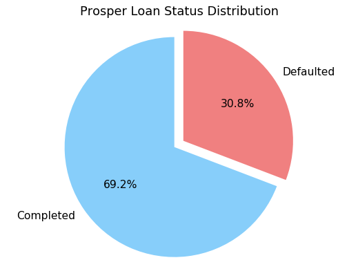

```python
# Since 'LoanStatus' only has two categories,
# a pie chart would be a good choice for visualization.

colors = ['lightcoral', 'lightskyblue']
explode = (0.1, 0)   # only "explode" the 1st slice: 'Defaulted'

plt.figure(figsize=(8, 6), dpi=80)
plt.pie(sorted_counts, explode=explode, labels= sorted_counts.index, colors=colors,
autopct='%1.1f%%', shadow=False, startangle=90, textprops={'fontsize': 14}, counterclock = False)
plt.axis('equal') # Equal aspect ratio will ensure the pie chart is drawn as a circle
plt.title('Prosper Loan Status Distribution', fontsize= 16);
```

As we can see, the overall default rate for Prosper loans is 30.8% and 69.2% of loans are completed loans.

**Next we will further explore the 'df_sub' dataset. Question #2: Of all the originated loans, what kind of loan terms are there?**  
**How many loans are there in each loan term category?**

```python
# Let's start with the 'Term' values_counts()
df_sub.Term.value_counts()
```

```
36    45096
60    3342
12    1202
Name: Term, dtype: int64
```

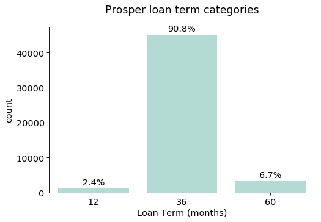

```python
# Since the loan term has three categories, I will use a barchart for visualization.
# I will also mark the percentage of each category on top of each bar as below.

# Create a barchart
plt.figure(figsize=(7, 4.5), dpi=80)
base_color = sb.color_palette("BrBG", 10)[6]
ax = sb.countplot(data = df_sub, x = 'Term', color = base_color);

n_points = df_sub.shape[0]
term_counts = df_sub.Term.value_counts()
# Obtain current tick locations and labels
locs, labels = plt.xticks()

# Loop through each location & label pair
for loc, label in zip(locs, labels):

    # Obtain text property for the label
    count = term_counts[label.get_text()]

    pct_string = '{:0.1f}%'.format(100*count/n_points)

    # print annotation on top of the barchart bars
    plt.text(loc, count+1000, pct_string, ha = 'center', color = 'black', fontsize = 13);

# Set figure title, y= 1.06 adds a little space between the title and the chart.
plt.title('Prosper loan term categories', fontsize= 15.5, y= 1.06)

# Only kept the bottom & left axes line.
ax.spines['top'].set_visible(False)
ax.spines['right'].set_visible(False)

# Define the x & y ticks/labels
plt.xticks(fontsize= 13)
plt.xlabel('Loan Term (months)', fontsize= 13)
plt.yticks(fontsize= 13)
plt.ylabel('count', fontsize= 13);
```

From the above graph, we learned that there are three different loan terms: 12 months, 36 months and 60 months for Prosper loans.  
We also discovered that majority of the loans (90.8%) are 36 month loans.

**Next, I wanted to know what percentage of borrowers are homeowners.**

```python
# To answer this question, let's obatain the 'IsBorrowerHomeowner' value counts.
owner_counts = df_sub.IsBorrowerHomeowner.value_counts()
owner_counts
```

```
False    25737
True     23903
Name: IsBorrowerHomeowner, dtype: int64
```

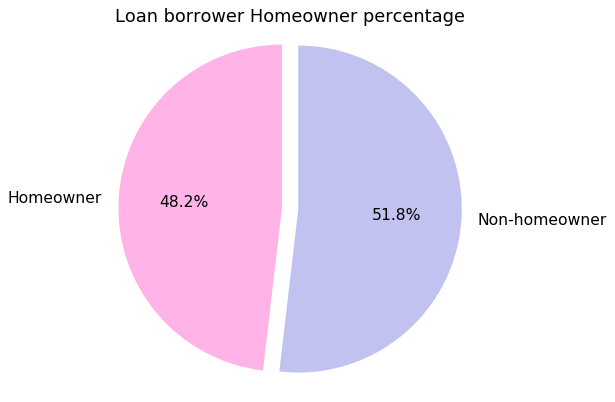

```python
# I will use a pie chart to visualize the 'IsBorrowerHomeowner' categorical variable.

colors = ['#c2c2f0','#ffb3e6']
explode = (0.1, 0) # only "explode" the 1st slice: Non-homeowner

plt.figure(figsize=(8, 6), dpi=80)
plt.pie(owner_counts, explode=explode, labels= ['Non-homeowner', 'Homeowner'], colors=colors,
autopct='%1.1f%%', shadow=False, startangle=90, textprops={'fontsize': 14}, counterclock = False)
plt.axis('equal') # Equal aspect ratio will ensure the pie chart is drawn as a circle
plt.title('Loan borrower Homeowner percentage', fontsize= 16);
```

Interestingly, about half (51.8%) of the loan borrowers do not own a house.

**What about the Borrower Rate distribution?**

```python
# Obtain summary statistics for 'BorrowerRate'.
df_sub.BorrowerRate.describe()
```

```
count    49640.000000
mean     0.197593
std      0.080562
min      0.000000
25%      0.132000
50%      0.190000
75%      0.262500
max      0.497500
Name: BorrowerRate, dtype: float64
```

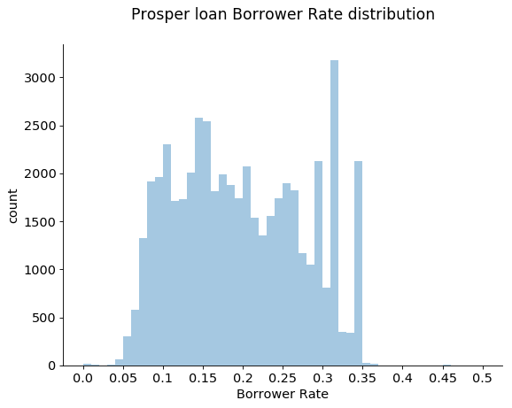

```python
# Since 'BorrowerRate' is a numeric variable, I will plot its distribution using a histogram.
plt.figure(figsize=(8, 6), dpi=80)
bin_edges = np.arange(0, df_sub.BorrowerRate.max()+0.01, 0.01)
ax = sb.distplot(df_sub.BorrowerRate, kde = False, bins= bin_edges)

# Set figure title, y= 1.06 adds a little space between the title and the chart.
plt.title('Prosper loan Borrower Rate distribution', fontsize= 15.5, y= 1.06)

# Only kept the bottom & left axes line.
ax.spines['top'].set_visible(False)
ax.spines['right'].set_visible(False)

# Define the x & y ticks/labels
rate_ticks = np.arange(0, df_sub.BorrowerRate.max()+ 0.05, 0.05)
plt.xticks(rate_ticks, rate_ticks, fontsize= 13)
plt.xlabel('Borrower Rate', fontsize= 13)
plt.yticks(fontsize= 13)
plt.ylabel('count', fontsize= 13);
```

From the histogram, we see that most of the Borrower Rate falls between 0.05 and 0.35. The distribution is roughly unimodel with several spikes seen at certain Borrower Rate (indicating certain Borrower Rates are more popular). Outliers on both the lower and upper end are observed, so let's further inspect them.

```python
# Query the dataset to return records of BorrowerRate below 0.03 or BorrowerRate above 0.4
df_sub.query('(BorrowerRate < 0.03) | (BorrowerRate > 0.4)')
```

|  | ListingKey | ListingNumber | ListingCreationDate | CreditGrade | Term | LoanStatus | ClosedDate | BorrowerAPR | BorrowerRate | LenderYield | EstimatedEffectiveYield | EstimatedLoss | EstimatedReturn | ProsperRating (numeric) | ProsperRating (Alpha) | ProsperScore | ListingCategory (numeric) | BorrowerState | Occupation | EmploymentStatus | EmploymentStatusDuration | IsBorrowerHomeowner | CurrentlyInGroup | GroupKey | DateCreditPulled | CreditScoreRangeLower | CreditScoreRangeUpper | FirstRecordedCreditLine | CurrentCreditLines | … |
| --- | --- | --- | --- | --- | --- | --- | --- | --- | --- | --- | --- | --- | --- | --- | --- | --- | --- | --- | --- | --- | --- | --- | --- | --- | --- | --- | --- | --- | --- | --- |
| 1484 | 5D523375277716429C58771 | 69022 | 2006-12-01 10:04:58.993 | E | 36 | Completed | 2008-11-21 00:00:00 | 0.01657 | 0.0100 | 0.0050 | NaN | NaN | NaN | NaN | NaN | NaN | 0 | IN | Other | Not available | NaN | False | False | NaN | 2006-11-29 03:39:44.157000000 | 580.0 | 599.0 | 1991-08-23 00:00:00 | NaN | … |
| 5823 | 2E07339232691202922692B | 156918 | 2007-06-23 10:32:34.540 | D | 36 | Completed | 2008-12-12 00:00:00 | 0.02811 | 0.0115 | 0.0015 | NaN | NaN | NaN | NaN | NaN | NaN | 0 | DE | Other | Full-time | 0.0 | False | False | NaN | 2007-06-14 06:09:39.863000000 | 600.0 | 619.0 | 2000-10-22 00:00:00 | 7.0 | … |
| 15993 | C25A3406939968877C77DD2 | 246366 | 2007-12-07 08:09:25.833 | D | 36 | Defaulted | 2009-02-13 00:00:00 | 0.01823 | 0.0100 | 0.0000 | NaN | NaN | NaN | NaN | NaN | NaN | 1 | NY | Retail Management | Full-time | 32.0 | False | False | NaN | 2007-12-07 07:45:12.470000000 | 600.0 | 619.0 | 2007-07-31 00:00:00 | 5.0 | … |
| 18326 | 0161336483146123835D6A5 | 1795 | 2006-03-11 15:43:45.393 | HR | 36 | Defaulted | 2007-01-14 00:00:00 | 0.45857 | 0.4500 | 0.4325 | NaN | NaN | NaN | NaN | NaN | NaN | 0 | NaN | NaN | NaN | NaN | False | False | F555336594467179889CEFB | 2006-02-20 16:42:34.790000000 | NaN | NaN | NaN | NaN | … |
| 22195 | 5686336572505607862C0C7 | 1849 | 2006-03-12 13:44:15.060 | HR | 36 | Defaulted | 2009-02-15 00:00:00 | 0.46201 | 0.4500 | 0.4325 | NaN | NaN | NaN | NaN | NaN | NaN | 0 | NaN | NaN | NaN | NaN | False | False | F555336594467179889CEFB | 2006-03-12 11:53:40.663000000 | NaN | NaN | NaN | NaN | … |
| 26650 | 2E09337145157954182A2D0 | 49987 | 2006-10-18 11:51:32.590 | HR | 36 | Defaulted | 2007-08-22 00:00:00 | 0.01647 | 0.0099 | 0.0049 | NaN | NaN | NaN | NaN | NaN | NaN | 0 | TX | Clerical | Not available | NaN | True | True | F3BE336490588367617A2BA | 2006-10-12 14:26:19.193000000 | 520.0 | 539.0 | 1999-08-05 00:00:00 | NaN | … |
| 29859 | 75DB3366773363492DDD729 | 34125 | 2006-08-25 11:10:06.193 | AA | 36 | Completed | 2006-10-17 00:00:00 | 0.01650 | 0.0000 | -0.0050 | NaN | NaN | NaN | NaN | NaN | NaN | 0 | IL | NaN | NaN | NaN | True | True | B0473364376920128370B13 | 2006-08-08 20:16:12.650000000 | 800.0 | 819.0 | 2002-08-09 00:00:00 | NaN | … |
| 33287 | 6F723403076471690BBA7CE | 223827 | 2007-10-31 10:31:36.283 | C | 36 | Completed | 2010-09-24 00:00:00 | 0.01657 | 0.0100 | 0.0000 | NaN | NaN | NaN | NaN | NaN | NaN | 0 | NC | Clerical | Full-time | 50.0 | False | False | NaN | 2007-10-24 09:41:47.140000000 | 660.0 | 679.0 | 1997-08-05 00:00:00 | 5.0 | … |
| 36018 | 844033650124564886B3EDC | 690 | 2006-02-23 13:57:02.087 | HR | 36 | Completed | 2006-03-14 00:00:00 | 0.51229 | 0.4975 | 0.4925 | NaN | NaN | NaN | NaN | NaN | NaN | 0 | NaN | NaN | NaN | NaN | False | False | NaN | 2006-02-23 13:57:02.087000000 | NaN | NaN | NaN | NaN | … |
| 44393 | 6B88337003023311719C524 | 47260 | 2006-10-11 15:59:42.477 | HR | 36 | Completed | 2008-05-12 00:00:00 | 0.02159 | 0.0150 | 0.0100 | NaN | NaN | NaN | NaN | NaN | NaN | 0 | KS | Sales - Retail | Not available | NaN | False | True | F3BE336490588367617A2BA | 2006-10-05 17:25:51.610000000 | 500.0 | 519.0 | 2003-08-16 00:00:00 | NaN | … |
| 44713 | 521A336561662309722D281 | 2374 | 2006-03-18 13:34:16.420 | HR | 36 | Completed | 2009-03-27 00:00:00 | 0.02659 | 0.0100 | 0.0050 | NaN | NaN | NaN | NaN | NaN | NaN | 0 | NaN | NaN | NaN | NaN | False | False | NaN | 2006-03-18 13:34:16.420000000 | NaN | NaN | NaN | NaN | … |
| 46874 | 3F5C3389508503122919326 | 143562 | 2007-05-28 06:40:54.803 | HR | 36 | Defaulted | 2010-10-05 00:00:00 | 0.01315 | 0.0000 | -0.0100 | NaN | NaN | NaN | NaN | NaN | NaN | 0 | NY | Professional | Full-time | 1.0 | False | False | NaN | 2007-05-13 08:46:25.487000000 | 520.0 | 539.0 | 2001-11-28 00:00:00 | 1.0 | … |
| 50251 | F3D634235667827325CACD4 | 357197 | 2008-06-25 17:43:40.637 | B | 36 | Completed | 2011-06-30 00:00:00 | 0.01325 | 0.0001 | -0.0099 | NaN | NaN | NaN | NaN | NaN | NaN | 1 | AR | Professional | Full-time | 12.0 | False | False | NaN | 2008-06-19 14:40:17.533000000 | 700.0 | 719.0 | 1999-02-09 00:00:00 | 4.0 | … |
| 53423 | 437334016695421433C8823 | 216769 | 2007-10-16 12:22:08.443 | B | 36 | Completed | 2008-12-04 00:00:00 | 0.01548 | 0.0005 | -0.0095 | NaN | NaN | NaN | NaN | NaN | NaN | 0 | CO | Realtor | Full-time | 0.0 | False | False | NaN | 2007-10-14 16:16:32.170000000 | 680.0 | 699.0 | 1998-08-31 00:00:00 | 14.0 | … |
| 53558 | 733033705905349923DE51A | 47411 | 2006-10-12 06:03:03.183 | HR | 36 | Defaulted | 2007-03-19 00:00:00 | 0.00864 | 0.0021 | -0.0029 | NaN | NaN | NaN | NaN | NaN | NaN | 0 | PA | Clerical | Not available | NaN | False | True | F3BE336490588367617A2BA | 2006-10-12 05:43:52.450000000 | 480.0 | 499.0 | 2000-10-01 00:00:00 | NaN | … |
| 65259 | BB4E34191946516388AD563 | 310792 | 2008-04-15 05:35:10.670 | HR | 36 | Completed | 2011-04-18 00:00:00 | 0.01987 | 0.0000 | -0.0100 | NaN | NaN | NaN | NaN | NaN | NaN | 3 | NC | Other | Full-time | 13.0 | False | False | NaN | 2008-03-23 00:11:48.863000000 | 520.0 | 539.0 | 1996-08-09 00:00:00 | 2.0 | … |
| 76035 | 18003392717086064DCD291 | 155582 | 2007-06-20 19:15:28.250 | D | 36 | Completed | 2008-02-19 00:00:00 | 0.02100 | 0.0100 | 0.0000 | NaN | NaN | NaN | NaN | NaN | NaN | 0 | OK | Other | Full-time | 13.0 | True | True | NaN | 2007-06-20 19:08:26.567000000 | 620.0 | 639.0 | 2001-05-31 00:00:00 | 10.0 | … |
| 76858 | 7ADE3385294777364BFEDD6 | 115163 | 2007-03-24 10:03:30.717 | C | 36 | Completed | 2010-03-27 00:00:00 | 0.00653 | 0.0000 | -0.0100 | NaN | NaN | NaN | NaN | NaN | NaN | 0 | MI | Food Service Management | Full-time | 152.0 | False | True | DE3D33744748484575A88D1 | 2007-03-13 23:26:35.980000000 | 660.0 | 679.0 | 1998-09-03 00:00:00 | 2.0 | … |
| 78401 | D51133706364386842C7D6B | 49783 | 2006-10-18 06:15:54.327 | D | 36 | Completed | 2009-10-23 00:00:00 | 0.00653 | 0.0000 | -0.0050 | NaN | NaN | NaN | NaN | NaN | NaN | 0 | NJ | Other | Not available | NaN | False | True | F3BE336490588367617A2BA | 2006-10-16 11:54:59.287000000 | 600.0 | 619.0 | 1977-11-01 00:00:00 | NaN | … |
| 78920 | CBC03418552010666B09260 | 319969 | 2008-04-28 11:48:10.400 | C | 36 | Completed | 2009-09-15 00:00:00 | 0.01987 | 0.0000 | -0.0100 | NaN | NaN | NaN | NaN | NaN | NaN | 1 | NJ | Dentist | Full-time | 3.0 | True | True | C506336436884701891E267 | 2008-04-28 11:45:42.977000000 | 660.0 | 679.0 | 1996-06-22 00:00:00 | 18.0 | … |
| 82043 | BBED336465905564254DC8B | 1112 | 2006-03-02 19:00:17.593 | HR | 36 | Defaulted | 2006-09-05 00:00:00 | 0.48873 | 0.4800 | 0.4750 | NaN | NaN | NaN | NaN | NaN | NaN | 0 | NaN | NaN | NaN | NaN | False | False | NaN | 2006-03-02 11:32:57.040000000 | NaN | NaN | NaN | NaN | … |
| 86048 | 4F0A3387646123176258169 | 123273 | 2007-04-13 16:18:43.147 | E | 36 | Completed | 2010-04-26 00:00:00 | 0.02323 | 0.0100 | 0.0000 | NaN | NaN | NaN | NaN | NaN | NaN | 0 | MA | Teacher | Part-time | 18.0 | False | False | NaN | 2007-04-13 15:57:33.507000000 | 580.0 | 599.0 | 2000-10-11 00:00:00 | 5.0 | … |
| 90051 | 88D333775844604529658CA | 77055 | 2006-12-21 15:20:20.630 | HR | 36 | Completed | 2007-07-24 00:00:00 | 0.01650 | 0.0000 | -0.0050 | NaN | NaN | NaN | NaN | NaN | NaN | 0 | IN | Sales - Retail | Not available | NaN | True | False | NaN | 2006-12-06 19:58:27.460000000 | 480.0 | 499.0 | 1999-02-05 00:00:00 | NaN | … |
| 95135 | 95AE33654214561955DFF1B | 20378 | 2006-06-18 19:23:28.370 | AA | 36 | Completed | 2007-01-25 00:00:00 | 0.03614 | 0.0295 | 0.0245 | NaN | NaN | NaN | NaN | NaN | NaN | 0 | NaN | NaN | NaN | NaN | False | True | 978733643891831260803F8 | 2006-06-15 19:46:51.367000000 | 780.0 | 799.0 | 1990-05-25 00:00:00 | NaN | … |
| 98696 | 92CA33952171859624D0A97 | 167417 | 2007-07-11 10:48:43.050 | HR | 36 | Completed | 2008-02-26 00:00:00 | 0.02659 | 0.0100 | 0.0000 | NaN | NaN | NaN | NaN | NaN | NaN | 0 | MO | Professional | Full-time | 18.0 | False | False | NaN | 2007-07-11 10:45:51.220000000 | 520.0 | 539.0 | 2001-05-25 00:00:00 | 5.0 | … |
| 103973 | 95ED3365915044756AB754F | 1366 | 2006-03-06 22:36:53.753 | HR | 36 | Defaulted | 2006-10-08 00:00:00 | 0.45857 | 0.4500 | 0.4325 | NaN | NaN | NaN | NaN | NaN | NaN | 0 | NaN | NaN | NaN | NaN | False | False | F555336594467179889CEFB | 2006-03-04 21:47:58.270000000 | NaN | NaN | NaN | NaN | … |
| 105191 | 0FE53410828184972447FD2 | 267017 | 2008-01-17 10:55:57.347 | HR | 36 | Defaulted | 2010-09-21 00:00:00 | 0.02998 | 0.0100 | 0.0000 | NaN | NaN | NaN | NaN | NaN | NaN | 4 | NY | Other | Self-employed | 94.0 | False | False | NaN | 2008-01-07 05:31:50.387000000 | 540.0 | 559.0 | 1999-04-02 00:00:00 | 1.0 | … |
| 112717 | C52F3426964405073574757 | 369381 | 2008-07-17 22:44:53.000 | A | 36 | Completed | 2010-10-13 00:00:00 | 0.01315 | 0.0000 | -0.0100 | NaN | NaN | NaN | NaN | NaN | NaN | 7 | CA | Analyst | Full-time | 158.0 | False | False | NaN | 2008-07-17 22:40:31.480000000 | 720.0 | 739.0 | 1993-11-15 00:00:00 | 10.0 | … |

After reviewing the 'BorrowerAPR', 'BorrowerRate' and 'LenderYield' of these outliers, it seems that they are valid loan records.  
It is also interesting that in some cases, people are willing to borrow money without charging any interests.

**What about Lender Yield? Does it have a similar distribution as the Borrower Rate?**

```python
# Again, let's start with the summary statistics for 'LenderYield'.
df_sub.LenderYield.describe()
```

```
count    49640.000000
mean     0.187469
std      0.079952
min     -0.010000
25%      0.122500
50%      0.179900
75%      0.252400
max      0.492500
Name: LenderYield, dtype: float64
```

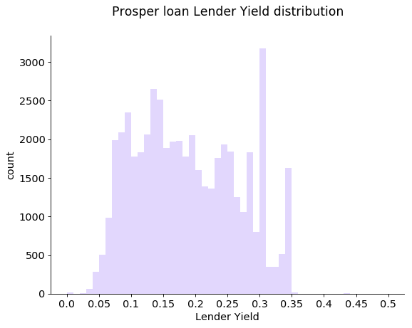

```python
# Plot the distribution of 'LenderYield' using a histogram.
plt.figure(figsize=(8, 6), dpi=80)
bin_edges = np.arange(0, df_sub.BorrowerRate.max()+0.01, 0.01)
ax = sb.distplot(df_sub.LenderYield, kde = False, bins= bin_edges, color= '#7038f8', hist_kws={'alpha': 0.2})

# Set figure title, y= 1.06 adds a little space between the title and the chart.
plt.title('Prosper loan Lender Yield distribution', fontsize= 15.5, y= 1.06)

# Only kept the bottom & left axes line.
ax.spines['top'].set_visible(False)
ax.spines['right'].set_visible(False)

# Define the x & y ticks/labels
yield_ticks = np.arange(0, df_sub.LenderYield.max()+ 0.05, 0.05)
plt.xticks(yield_ticks, yield_ticks, fontsize= 13)
plt.xlabel('Lender Yield', fontsize= 13)
plt.yticks(fontsize= 13)
plt.ylabel('count', fontsize= 13);
```

Very interestingly, the distribution of Lender Yield is indeed similar to the Borrower Rate distribution (which makes sense). However compare to the Borrower Rate distribution, we see a slight left shift in the Lender Yield distribution with variations in spike locations possibly due to Prosper fees. This might be the reason why we see negative Lender Yields returns. I assume these negative returns loans have 0% or very low Borrower Rates. Let's explore this by querying the dataset as below.

```python
# Query the records with negative 'LenderYield'
df_sub.query('LenderYield < 0')
```

|  | ListingKey | ListingNumber | ListingCreationDate | CreditGrade | Term | LoanStatus | ClosedDate | BorrowerAPR | BorrowerRate | LenderYield | EstimatedEffectiveYield | EstimatedLoss | EstimatedReturn | ProsperRating (numeric) | ProsperRating (Alpha) | ProsperScore | ListingCategory (numeric) | BorrowerState | Occupation | EmploymentStatus | EmploymentStatusDuration | IsBorrowerHomeowner | CurrentlyInGroup | GroupKey | DateCreditPulled | CreditScoreRangeLower | CreditScoreRangeUpper | FirstRecordedCreditLine | CurrentCreditLines | … |
| --- | --- | --- | --- | --- | --- | --- | --- | --- | --- | --- | --- | --- | --- | --- | --- | --- | --- | --- | --- | --- | --- | --- | --- | --- | --- | --- | --- | --- | --- | --- |
| 29859 | 75DB3366773363492DDD729 | 34125 | 2006-08-25 11:10:06.193 | AA | 36 | Completed | 2006-10-17 00:00:00 | 0.01650 | 0.0000 | -0.0050 | NaN | NaN | NaN | NaN | NaN | NaN | 0 | IL | NaN | NaN | NaN | True | True | B0473364376920128370B13 | 2006-08-08 20:16:12.650000000 | 800.0 | 819.0 | 2002-08-09 00:00:00 | NaN | … |
| 46874 | 3F5C3389508503122919326 | 143562 | 2007-05-28 06:40:54.803 | HR | 36 | Defaulted | 2010-10-05 00:00:00 | 0.01315 | 0.0000 | -0.0100 | NaN | NaN | NaN | NaN | NaN | NaN | 0 | NY | Professional | Full-time | 1.0 | False | False | NaN | 2007-05-13 08:46:25.487000000 | 520.0 | 539.0 | 2001-11-28 00:00:00 | 1.0 | … |
| 50251 | F3D634235667827325CACD4 | 357197 | 2008-06-25 17:43:40.637 | B | 36 | Completed | 2011-06-30 00:00:00 | 0.01325 | 0.0001 | -0.0099 | NaN | NaN | NaN | NaN | NaN | NaN | 1 | AR | Professional | Full-time | 12.0 | False | False | NaN | 2008-06-19 14:40:17.533000000 | 700.0 | 719.0 | 1999-02-09 00:00:00 | 4.0 | … |
| 53423 | 437334016695421433C8823 | 216769 | 2007-10-16 12:22:08.443 | B | 36 | Completed | 2008-12-04 00:00:00 | 0.01548 | 0.0005 | -0.0095 | NaN | NaN | NaN | NaN | NaN | NaN | 0 | CO | Realtor | Full-time | 0.0 | False | False | NaN | 2007-10-14 16:16:32.170000000 | 680.0 | 699.0 | 1998-08-31 00:00:00 | 14.0 | … |
| 53558 | 733033705905349923DE51A | 47411 | 2006-10-12 06:03:03.183 | HR | 36 | Defaulted | 2007-03-19 00:00:00 | 0.00864 | 0.0021 | -0.0029 | NaN | NaN | NaN | NaN | NaN | NaN | 0 | PA | Clerical | Not available | NaN | False | True | F3BE336490588367617A2BA | 2006-10-12 05:43:52.450000000 | 480.0 | 499.0 | 2000-10-01 00:00:00 | NaN | … |
| 65259 | BB4E34191946516388AD563 | 310792 | 2008-04-15 05:35:10.670 | HR | 36 | Completed | 2011-04-18 00:00:00 | 0.01987 | 0.0000 | -0.0100 | NaN | NaN | NaN | NaN | NaN | NaN | 3 | NC | Other | Full-time | 13.0 | False | False | NaN | 2008-03-23 00:11:48.863000000 | 520.0 | 539.0 | 1996-08-09 00:00:00 | 2.0 | … |
| 76858 | 7ADE3385294777364BFEDD6 | 115163 | 2007-03-24 10:03:30.717 | C | 36 | Completed | 2010-03-27 00:00:00 | 0.00653 | 0.0000 | -0.0100 | NaN | NaN | NaN | NaN | NaN | NaN | 0 | MI | Food Service Management | Full-time | 152.0 | False | True | DE3D33744748484575A88D1 | 2007-03-13 23:26:35.980000000 | 660.0 | 679.0 | 1998-09-03 00:00:00 | 2.0 | … |
| 78401 | D51133706364386842C7D6B | 49783 | 2006-10-18 06:15:54.327 | D | 36 | Completed | 2009-10-23 00:00:00 | 0.00653 | 0.0000 | -0.0050 | NaN | NaN | NaN | NaN | NaN | NaN | 0 | NJ | Other | Not available | NaN | False | True | F3BE336490588367617A2BA | 2006-10-16 11:54:59.287000000 | 600.0 | 619.0 | 1977-11-01 00:00:00 | NaN | … |
| 78920 | CBC03418552010666B09260 | 319969 | 2008-04-28 11:48:10.400 | C | 36 | Completed | 2009-09-15 00:00:00 | 0.01987 | 0.0000 | -0.0100 | NaN | NaN | NaN | NaN | NaN | NaN | 1 | NJ | Dentist | Full-time | 3.0 | True | True | C506336436884701891E267 | 2008-04-28 11:45:42.977000000 | 660.0 | 679.0 | 1996-06-22 00:00:00 | 18.0 | … |
| 90051 | 88D333775844604529658CA | 77055 | 2006-12-21 15:20:20.630 | HR | 36 | Completed | 2007-07-24 00:00:00 | 0.01650 | 0.0000 | -0.0050 | NaN | NaN | NaN | NaN | NaN | NaN | 0 | IN | Sales - Retail | Not available | NaN | True | False | NaN | 2006-12-06 19:58:27.460000000 | 480.0 | 499.0 | 1999-02-05 00:00:00 | NaN | … |
| 112717 | C52F3426964405073574757 | 369381 | 2008-07-17 22:44:53.000 | A | 36 | Completed | 2010-10-13 00:00:00 | 0.01315 | 0.0000 | -0.0100 | NaN | NaN | NaN | NaN | NaN | NaN | 7 | CA | Analyst | Full-time | 158.0 | False | False | NaN | 2008-07-17 22:40:31.480000000 | 720.0 | 739.0 | 1993-11-15 00:00:00 | 10.0 | … |

And indeed all the negative Lender Yield loans have 0% or very low Borrower Rates supporting our hypothesis.

**Moving on, let's look at the 'DebtToIncomeRatio' distribution. It is also a numeric variable, so the plot of choice is histogram.**  
Is 'DebtToIncomeRatio' evenly distributed?

```python
# Obtain summary statistics for 'DebtToIncomeRatio'.
df_sub.DebtToIncomeRatio.describe()
```

```
count    49640.000000
mean     0.255154
std      0.448187
min      0.000000
25%      0.130000
50%      0.200000
75%      0.300000
max      10.010000
Name: DebtToIncomeRatio, dtype: float64
```

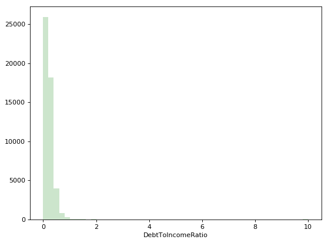

```python
# Plot the distribution of 'LenderYield' using a histogram.
plt.figure(figsize=(8, 6), dpi=80)
sb.distplot(df_sub.DebtToIncomeRatio, kde = False, color= 'g', hist_kws={'alpha': 0.2});
```

From the graph above, we see that 'DebtToIncomeRatio' distribution is highly right-skewed. Also most 'DebtToIncomeRatio' are below 1.  
Let's improve the histogram by 'log' scale transformation of x-axis and setting appropriate bin sizes.

```python
# Obtain 'log' values of the 25th Percentile, 50th Percentile, 75th Percentile for 'DebtToIncomeRatio'.
# Since the minimum value of 'DebtToIncomeRatio' is 0, if we take log 10, it would result in a warning..
np.log10(df_sub.DebtToIncomeRatio.quantile([0.25, 0.5, 0.75]))
```

```
0.25   -0.886057
0.50   -0.698970
0.75   -0.522879
Name: DebtToIncomeRatio, dtype: float64
```

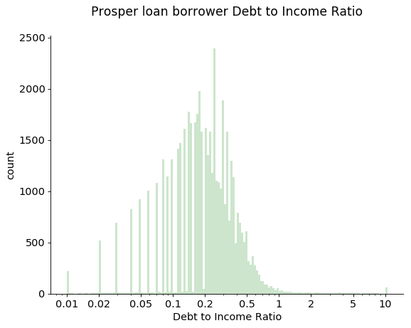

```python
# Improve the 'DebtToIncomeRatio' histogram
# with 'log' scale transformation of x-axis and setting appropriate bin sizes.

plt.figure(figsize=(8, 6), dpi=80)
bin_edges = 10 ** np.arange(-2, np.log10(df_sub.DebtToIncomeRatio.max())+0.02, 0.02)

ax = sb.distplot(df_sub.DebtToIncomeRatio, kde = False, color= 'g', bins= bin_edges, hist_kws={'alpha': 0.2})

# Set figure title, y= 1.06 adds a little space between the title and the chart.
plt.title('Prosper loan borrower Debt to Income Ratio', fontsize= 15.5, y= 1.06)

# Only kept the bottom & left axes line.
ax.spines['top'].set_visible(False)
ax.spines['right'].set_visible(False)

# Define the x & y ticks/labels

plt.xlabel('Debt to Income Ratio', fontsize= 13)
plt.yticks(fontsize= 13)
plt.ylabel('count', fontsize= 13)
plt.xscale('log')

debt_ticks = [0.01, 0.02, 0.05, 0.1, 0.2, 0.5, 1, 2, 5, 10]
plt.xticks(debt_ticks, debt_ticks, fontsize= 13);
```

After transforming the x-axis into 'log' scale, we see that the Debt to Income Ratio generally follows a unimodel distribution with many spikes. Most of the Debt to Income Ratio falls between 0.01 and 1, with noticeable outliers on the right side of the distribution. Interestingly, we do see a few Debt to Income Ratio over 10. These people carry debt more than 10 times of their income! As all the incomes for each borrower are verifiable ('IncomeVerifiable' == True) for our dataset, these outliers ('DebtToIncomeRatio' > 1) are valid values.

**Next, let's explore the borrower's 'IncomeRange'.**  
What are common Income Ranges for loan borrowers? Since 'IncomeRange' is a categorical variable, I will use a barchart for visualization.

```python
# Obtain 'IncomeRange' value_counts()
df_sub.IncomeRange.value_counts()
```

```
$25,000-49,999    14930
$50,000-74,999    11885
Not displayed     7377
$75,000-99,999    6023
$100,000+         5549
$1-24,999         3821
Not employed      55
$0                0
Name: IncomeRange, dtype: int64
```

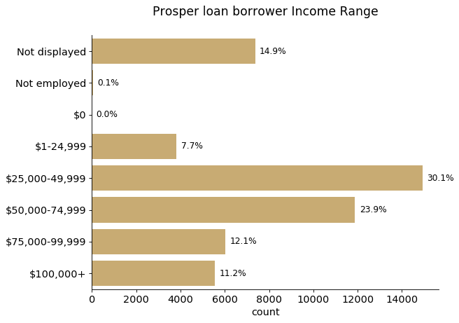

```python
# Create a barchart for 'IncomeRange' with percentage of each category on the right side of each bar.

plt.figure(figsize=(8, 6), dpi=80)
base_color = sb.color_palette("BrBG", 10)[2]
ax = sb.countplot(data = df_sub, y = 'IncomeRange', color = base_color);

n_points = df_sub.shape[0]
income_counts = df_sub.IncomeRange.value_counts()
# Obtain current tick locations and labels
locs, labels = plt.yticks()

# Loop through each location & label pair
for loc, label in zip(locs, labels):

    # Obtain text property for the label
    count = income_counts[label.get_text()]

    pct_string = '{:0.1f}%'.format(100*count/n_points)

    # print annotation on top of the barchart bars
    plt.text(count+200, loc,  pct_string, va = 'center', color = 'black', fontsize = 11);

# Set figure title, y= 1.06 adds a little space between the title and the chart.
plt.title('Prosper loan borrower Income Range', fontsize= 15.5, y= 1.06)

# Only kept the bottom & left axes line.
ax.spines['top'].set_visible(False)
ax.spines['right'].set_visible(False)

# Define the x & y ticks/labels
plt.xticks(fontsize= 13)
plt.xlabel('count', fontsize= 13)
plt.yticks(fontsize= 13)
plt.ylabel('', fontsize= 13);
```

From the above barchart, we see that 14.9% of borrower's Income range were not displayed. Only 0.1% of borrower were unemployed. Interestingly, nobody had income of \$0 (as these records have been dropped during the data wrangling stage). The most common two income ranges are \\$25,000-49,999 (30.1%) and \$50,000-\\$74,999 (23.9%) indicating more than 50% of borrower's income range are between \$25,000-\\$74,999.

**Moving on, we look into 'LoanOriginalAmount' which is another numeric variable.**  
What does the distribution of 'LoanOriginalAmount' look like? Is it a skewed distribution?

```python
# Obtain summary statistics for 'LoanOriginalAmount'.
df_sub.LoanOriginalAmount.describe()
```

```
count    49640.000000
mean     6366.238618
std      5262.099376
min      1000.000000
25%      2878.000000
50%      4800.000000
75%      8000.000000
max      35000.000000
Name: LoanOriginalAmount, dtype: float64
```

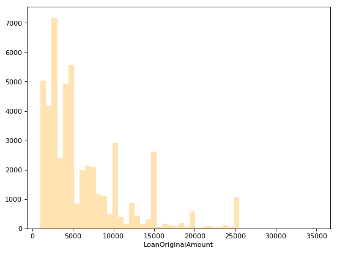

```python
# Plot the distribution of 'LoanOriginalAmount' using a histogram.
plt.figure(figsize=(8, 6), dpi=80)
sb.distplot(df_sub.LoanOriginalAmount, kde = False, color= 'orange', hist_kws={'alpha': 0.3});
```

We see that the 'LoanOriginalAmount' generally follows a right-skewed distribution, so 'log' scale transformation of x-axis might be helpful.  
We also see spikes in the distribution, indicating certain loan amounts are more popular.

```python
# Obtain 'log' values of 'LoanOriginalAmount' summary statistics.
np.log10(df_sub.LoanOriginalAmount.describe())
```

```
count    4.695832
mean     3.803883
std      3.721159
min      3.000000
25%      3.459091
50%      3.681241
75%      3.903090
max      4.544068
Name: LoanOriginalAmount, dtype: float64
```

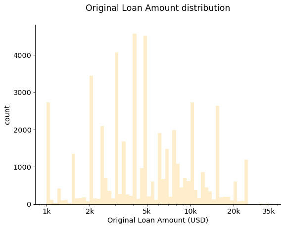

```python
# Improve the 'LoanOriginalAmount' histogram
# with 'log' scale transformation of x-axis and setting appropriate bin sizes.

plt.figure(figsize=(8, 6), dpi=80)

bin_edges = 10 ** np.arange(3, np.log10(df_sub.LoanOriginalAmount.max())+0.025, 0.025)
ax = sb.distplot(df_sub.LoanOriginalAmount, kde = False, color= 'orange', bins= bin_edges, hist_kws={'alpha': 0.2})

# Set figure title, y= 1.06 adds a little space between the title and the chart.
plt.title('Original Loan Amount distribution', fontsize= 15.5, y= 1.06)

# Only kept the bottom & left axes line.
ax.spines['top'].set_visible(False)
ax.spines['right'].set_visible(False)

# Define the x & y ticks/labels
plt.xlabel('Original Loan Amount (USD)', fontsize= 13)
plt.yticks(fontsize= 13)
plt.ylabel('count', fontsize= 13)
plt.xscale('log')
loan_ticks = [1000, 2000, 5000, 10000, 20000, 35000]
loan_labels = ['1k', '2k', '5k', '10k', '20k', '35k']
plt.xticks(loan_ticks, loan_labels, fontsize= 13);
```

Very interestingly, after log transformation of x-scale, we see there are many spikes within the original loan amount distribution.  
These spikes often shows up at \$1000 increment levels, suggesting people have certain borrowing habbits (prefer to borrow in whole thousand dollar amounts). We can perform a quick query to check if this is true.

```python
# Return the number of loans with 'LoanOriginalAmount' equal to 1000 and 2000.
df_sub[df_sub.LoanOriginalAmount == 1000].shape[0], df_sub[df_sub.LoanOriginalAmount == 2000].shape[0]
```

```
(2657, 3305)
```

As we can see, the numbers for \$1000 and \\$2000 loans matches with the above histogram, supporting our hypothesis.

**Next, we will explore 'MonthlyLoanPayment', which is another numeric variable.**  
What is the distribution of 'MonthlyLoanPayment'? Since the distribution of 'LoanOriginalAmount' is right skewed, I assume 'MonthlyLoanPayment' would be right skewed as well (higher monthly loan payments should correlate to higher loan amounts). Let's see if this is true.

```python
# Obtain summary statistics for 'MonthlyLoanPayment'.
df_sub.MonthlyLoanPayment.describe()
```

```
count    49640.000000
mean     228.381973
std      184.714347
min      16.700000
25%      102.970000
50%      173.710000
75%      303.680000
max      2251.510000
Name: MonthlyLoanPayment, dtype: float64
```

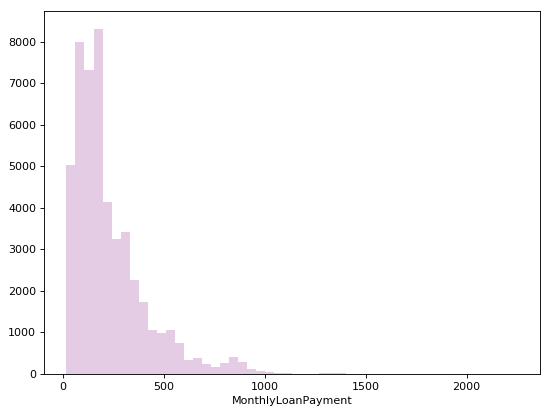

```python
# Plot the distribution of 'MonthlyLoanPayment' using a histogram.
plt.figure(figsize=(8, 6), dpi=80)
sb.distplot(df_sub.MonthlyLoanPayment, kde = False, color= 'purple', hist_kws={'alpha': 0.2});
```

No surprise, 'MonthlyLoanPayment' follows a right-skewed distribution as well.  
Let's do a 'log' scale transformation of x-axis.

```python
# Obtain 'log' values of 'MonthlyLoanPayment' summary statistics.
np.log10(df_sub.MonthlyLoanPayment.describe())
```

```
count    4.695832
mean     2.358662
std      2.266501
min      1.222716
25%      2.012711
50%      2.239825
75%      2.482416
max      3.352474
Name: MonthlyLoanPayment, dtype: float64
```

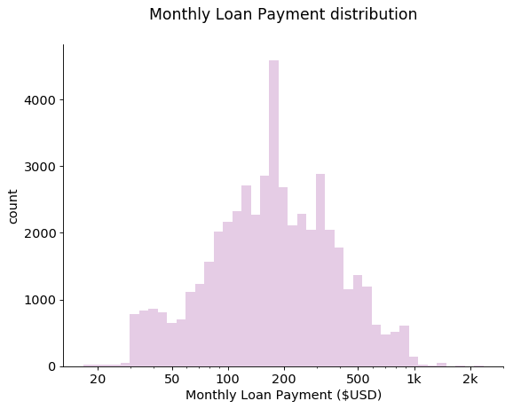

```python
# Improve the 'MonthlyLoanPayment' histogram
# with 'log' scale transformation of x-axis and setting appropriate bin sizes.

plt.figure(figsize=(8, 6), dpi=80)

bin_edges = 10 ** np.arange(1.222716, np.log10(df_sub.MonthlyLoanPayment.max())+0.05, 0.05)
ax = sb.distplot(df_sub.MonthlyLoanPayment, kde = False, color= 'purple', bins= bin_edges, hist_kws={'alpha': 0.2})

# Set figure title, y= 1.06 adds a little space between the title and the chart.
plt.title('Monthly Loan Payment distribution', fontsize= 15.5, y= 1.06)

# Only kept the bottom & left axes line.
ax.spines['top'].set_visible(False)
ax.spines['right'].set_visible(False)

# Define the x & y ticks/labels
plt.xlabel('Monthly Loan Payment ($USD)', fontsize= 13)
plt.yticks(fontsize= 13)
plt.ylabel('count', fontsize= 13)
plt.xscale('log')
payment_ticks = [20, 50, 100, 200, 500, 1000, 2000]
payment_labels = ['20', '50', '100', '200', '500', '1k', '2k']
plt.xticks(payment_ticks, payment_labels, fontsize= 13);
```

Interestingly, after the log transformation, monthly loan payment follows a near normal distribution.  
We see most monthly payments are between \$30-\\$1000 per month.

**Moving forward, we will look into 'CreditGrade'**. What is the most common credit grade loans?  
As 'CreditGrade' is used to evaluate loans originated before July 2009, we will use the 'df_old_loans' dataset.  
Since 'CreditGrade' is also a categorical variable, we will use a barchart for visualization.

```python
# Obtain value_counts() for 'CreditGrade'
df_old_loans.CreditGrade.value_counts()
```

```
C     5363
D     4872
B     4038
HR    3247
AA    3199
A     3075
E     3071
Name: CreditGrade, dtype: int64
```

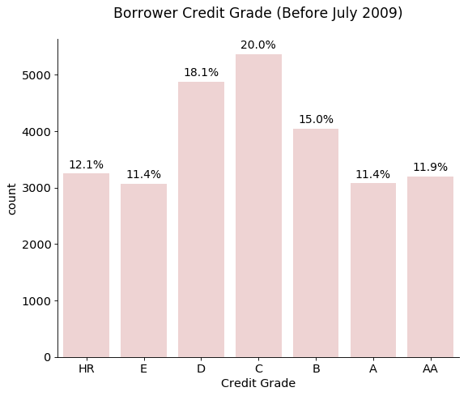

```python
# Create a barchart for 'CreditGrade'
# Mark the percentage of each category on top of each bar.

plt.figure(figsize=(8, 6.5), dpi=80)
base_color = sb.color_palette("muted", 10)[2]
ax = sb.countplot(data = df_old_loans, x = 'CreditGrade', color = base_color, alpha = 0.3);

n_points = df_old_loans.shape[0]
bins_counts = df_old_loans.CreditGrade.value_counts()
# Obtain current tick locations and labels
locs, labels = plt.xticks()

# Loop through each location & label pair
for loc, label in zip(locs, labels):

    # Obtain text property for the label
    count = bins_counts[label.get_text()]

    pct_string = '{:0.1f}%'.format(100*count/n_points)

    # print annotation on top of the barchart bars
    plt.text(loc, count+100, pct_string, ha = 'center', color = 'black', fontsize = 12.5);

# Set figure title, y= 1.05 adds a little space between the title and the chart.
plt.title('Borrower Credit Grade (Before July 2009)', fontsize= 15.5, y= 1.05)

# Only kept the bottom & left axes line.
ax.spines['top'].set_visible(False)
ax.spines['right'].set_visible(False)

# Define the x & y ticks/labels
plt.xticks(fontsize= 13)
plt.xlabel('Credit Grade', fontsize= 13)
plt.yticks(fontsize= 13)
plt.ylabel('count', fontsize= 13);
```

We see that for loans originated before July 2009, the most common credit grade is level 'C', representing 20% of the loans. Second and third popular credit grades are grade 'D' (18.1%) and grade 'B'(15.0%) loans. 'HR', 'E', 'A', 'AA' levels loans are less common, at 11.4-12.1%.

**Next, let's explore the 'ProsperRating (Alpha)' variable** It would be interesting to know what is the distribution of 'ProsperRating (Alpha)' for loans originated after July 2009. As 'ProsperRating (Alpha)' is used to evaluate loans originated after July 2009, we will use the 'df_new_loans' dataframe.  
We will use a barchart for visualization as this feature is a categorical.

```python
# Obtain value_counts() for 'ProsperRating (Alpha)'
df_new_loans['ProsperRating (Alpha)'].value_counts()
```

```
D     5022
C     3385
A     3313
E     3159
B     3090
HR    2973
AA    1637
Name: ProsperRating (Alpha), dtype: int64
```

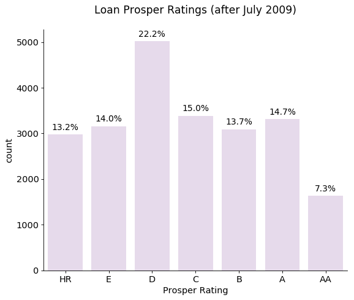

```python
# Create a barchart for 'ProsperRating (Alpha)'
# Mark the percentage of each category on top of each bar.

plt.figure(figsize=(8, 6.5), dpi=80)
base_color = sb.color_palette("muted", 10)[3]
ax = sb.countplot(data = df_new_loans, x = 'ProsperRating (Alpha)', color = base_color, alpha = 0.3);

n_points = df_new_loans.shape[0]
bins_counts = df_new_loans['ProsperRating (Alpha)'].value_counts()
# Obtain current tick locations and labels
locs, labels = plt.xticks()

# Loop through each location & label pair
for loc, label in zip(locs, labels):

    # Obtain text property for the label
    count = bins_counts[label.get_text()]

    pct_string = '{:0.1f}%'.format(100*count/n_points)

    # print annotation on top of the barchart bars
    plt.text(loc, count+100, pct_string, ha = 'center', color = 'black', fontsize = 12.5);

# Set figure title, y= 1.05 adds a little space between the title and the chart.
plt.title('Loan Prosper Ratings (after July 2009)', fontsize= 15.5, y= 1.05)

# Only kept the bottom & left axes line.
ax.spines['top'].set_visible(False)
ax.spines['right'].set_visible(False)

# Define the x & y ticks/labels
plt.xticks(fontsize= 13)
plt.xlabel('Prosper Rating', fontsize= 13)
plt.yticks(fontsize= 13)
plt.ylabel('count', fontsize= 13);
```

### Discuss the distribution(s) of your variable(s) of interest. Were there any unusual points? Did you need to perform any transformations?

In the above univariate exploration section, I explored the distribution of the below variables:

- LoanStatus
- Term
- IsBorrowerHomeowner
- BorrowerRate
- LenderYield
- DebtToIncomeRatio
- IncomeRange
- LoanOriginalAmount
- MonthlyLoanPayment
- CreditGrade (for loans originated before July 2009)
- ProsperRating (Alpha)(for loans originated after July 2009)

For the 'BorrowerRate' variable, I looked into rates below 0.03 and above 0.4. I found theses outlier records are valid.  
For the 'LenderYield' variable, I investigated negative yield loans and found they are valid as well (they are loans with 0% or very low Borrower Rate).  
For variables: 'DebtToIncomeRatio', 'LoanOriginalAmount' and 'MonthlyLoanPayment' I performed log transformation of x-scale as the distributions were right-skewed. I also discussed the 'DebtToIncomeRatio' valid outliers and the reason for keeping them.

### Of the features you investigated, were there any unusual distributions? Did you perform any operations on the data to tidy, adjust, or change the form of the data? If so, why did you do this?

Of the features I investigated, the most interesting distribution is the 'LoanOriginalAmount'. It has many spikes at $1000 increment levels, suggesting people have may like to borrow in whole thousand dollar amount.

Most of the data wrangling was performed in the preliminary wrangling section of this analysis. For the 'CreditGrade' feature, I dropped the 'NC' grade records as I could not find any information about this credit grade (they are not explained in the data dictionary file and no information could be found at Prosper's website). I also excluded the missing values for 'CrediGrade' as they are not helpful to our analysis. For the 'MonthlyLoanPayment' feature, I excluded all the records with monthly payment below \$16.66. The reason of dropping these records is that we know from the dataset: with the minimal loan amount of \\$1000, maximium loan Term of 60 months and 0% borrower rate, the minimal 'MonthlyLoanPayment' should be greater than \$16.66. So any monthly loan payment below \\$16.66 does not make sense.

## Bivariate Exploration

**Since our goal is to compare features of defaulted loans vs completed loans, let's first explore whether defaulted loan borrowers have lower rate of home ownership.** In other words, we will explore the relationship between 'LoanStatus' and 'IsBorrowerHomeowner'. As both features are categorical in nature, I will use a clustered barchart to present the data.

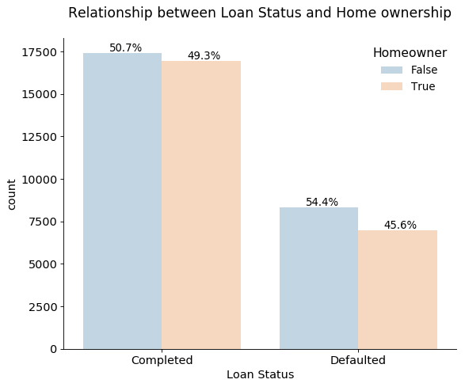

```python
# Create a clustered barchart to present the relationship between 'LoanStatus' and 'IsBorrowerHomeowner'.

plt.figure(figsize=(8, 6.5), dpi=80)

ax = sb.countplot(data = df_sub, x = 'LoanStatus', hue = 'IsBorrowerHomeowner', alpha = 0.3)

# Set figure title, y= 1.05 adds a little space between the title and the chart.
plt.title('Relationship between Loan Status and Home ownership', fontsize= 15.5, y= 1.05)

# Add percentage on top of 'Completed' loan bars.
total1 = len(df_sub.query('LoanStatus == "Completed"'))
for p in ax.patches[::2]:
    percentage = '{:.1f}%'.format(100 * p.get_height()/total1)
    width, height = p.get_width(), p.get_height()
    x, y = p.get_xy()
    ax.annotate(percentage, (x+0.13, y + height + 100), fontsize= 12)

# Add percentage on top of 'Defaulted' loan bars.
total2 = len(df_sub.query('LoanStatus == "Defaulted"'))
for p in ax.patches[1::2]:
    percentage = '{:.1f}%'.format(100 * p.get_height()/total2)
    width, height = p.get_width(), p.get_height()
    x, y = p.get_xy()
    ax.annotate(percentage, (x+0.13, y + height + 100), fontsize= 12)

# Only kept the bottom & left axes line.
ax.spines['top'].set_visible(False)
ax.spines['right'].set_visible(False)

# Define the x & y ticks/labels
plt.xticks(fontsize= 13)
plt.xlabel('Loan Status', fontsize= 13)
plt.yticks(fontsize= 13)
plt.ylabel('count', fontsize= 13)
leg = ax.legend(frameon=False)
leg.set_title('Homeowner',prop={'size':14});
```

From the above chart, we see that Defaulted loan borrowers have slightly lower home ownership rates compared to Completed loan borrowers (45.6% vs 49.3%).

**Next, let's check the relationship between 'LoanStatus' and 'BorrowerRate'. Would defaulted loans have higher 'BorrowerRate'?**  
Since 'LoanStatus' is a categorical variable and 'BorrowerRate' is a numeric variable, I will use a boxplot to reveal the data.

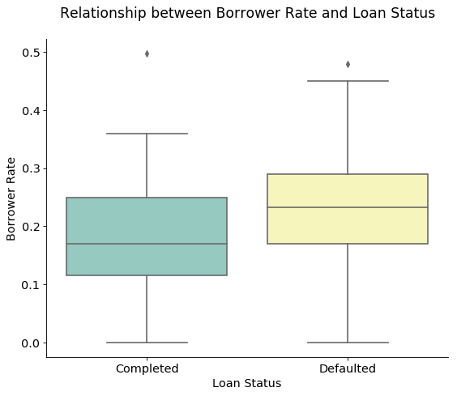

```python
# Create a boxplot to present the relationship between 'LoanStatus' and 'BorrowerRate'.
plt.figure(figsize=(8, 6.5), dpi=80)

ax = sb.boxplot(data = df_sub, x = 'LoanStatus', y = 'BorrowerRate', palette="Set3")

# Set figure title, y= 1.05 adds a little space between the title and the chart.
plt.title('Relationship between Borrower Rate and Loan Status', fontsize= 15.5, y= 1.05)

# Only kept the bottom & left axes line.
ax.spines['top'].set_visible(False)
ax.spines['right'].set_visible(False)

# Define the x & y ticks/labels
plt.xticks(fontsize= 13)
plt.xlabel('Loan Status', fontsize= 13)
plt.yticks(fontsize= 13)
plt.ylabel('Borrower Rate', fontsize= 13);
```

```python
# Obtain summary statistics for 'BorrowerRate' by 'LoanStatus' groups.
df_sub.groupby('LoanStatus').BorrowerRate.describe()
```

| LoanStatus | count | mean | std | min | 25% | 50% | 75% | max |
| --- | --- | --- | --- | --- | --- | --- | --- | --- |
| Completed | 34356.0 | 0.183475 | 0.080216 | 0.0 | 0.115 | 0.1700 | 0.249225 | 0.4975 |
| Defaulted | 15284.0 | 0.229328 | 0.071836 | 0.0 | 0.170 | 0.2325 | 0.290000 | 0.4800 |

Interestingly, we see that the defaulted loans generally have higher borrower rates compared to the completed loans. For completed loans, 50% of the borrower rate falls between 0.11 to 0.25, while for defaulted loans, 50% of the borrower rate falls between 0.17 to 0.29. And the median borrower rate of completed loans (around 0.17) is similar to the 25th Percentile borrower rate of defaulted loans. This indicates the cost of borrowing is generally higher for the defaulted loan group.

**Moving forward, let's explore the relationship between 'LoanStatus' and 'DebtToIncomeRatio'.**  
Will the defaulted loans have a higher Debt to Income Ratio? Since 'LoanStatus' is a categorical variable and 'DebtToIncomeRatio' is a numeric variable, I will use a boxplot to present the data.

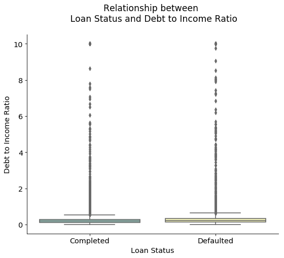

```python
# Create a boxplot to present the relationship between 'LoanStatus' and 'DebtToIncomeRatio'.
plt.figure(figsize=(8, 6.5), dpi=80)

ax = sb.boxplot(data = df_sub, x = 'LoanStatus', y = 'DebtToIncomeRatio', palette="Set3")

# Set figure title, y= 1.05 adds a little space between the title and the chart.
plt.title('Relationship between \n Loan Status and Debt to Income Ratio', fontsize= 15.5, y= 1.05)

# Only kept the bottom & left axes line.
ax.spines['top'].set_visible(False)
ax.spines['right'].set_visible(False)

# Define the x & y ticks/labels & scale
plt.xticks(fontsize= 13)
plt.xlabel('Loan Status', fontsize= 13)
plt.yticks(fontsize= 13)
plt.ylabel('Debt to Income Ratio', fontsize= 13);
```

As there are a lot of outliers for the 'DebtToIncomeRatio', it is quite difficult to interpret the above boxplot.  
Let's limit the y-axis to take a closer look at the distribution.

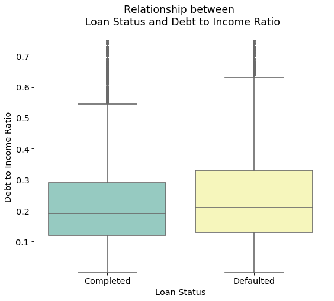

```python
# Improve the boxplot to present the relationship between 'LoanStatus' and 'DebtToIncomeRatio'.
plt.figure(figsize=(8, 6.5), dpi=80)

ax = sb.boxplot(data = df_sub, x = 'LoanStatus', y = 'DebtToIncomeRatio', palette="Set3")

# Set figure title, y= 1.05 adds a little space between the title and the chart.
plt.title('Relationship between \n Loan Status and Debt to Income Ratio', fontsize= 15.5, y= 1.05)

# Only kept the bottom & left axes line.
ax.spines['top'].set_visible(False)
ax.spines['right'].set_visible(False)

# Define the x & y ticks/labels & scale
debt_ticks = [0.1, 0.2, 0.3, 0.4, 0.5, 0.6, 0.7]
plt.xticks(fontsize= 13)
plt.xlabel('Loan Status', fontsize= 13)
plt.yticks(debt_ticks, debt_ticks, fontsize= 13)
plt.ylabel('Debt to Income Ratio', fontsize= 13)
plt.ylim((0,0.75));
```

After limiting the y-axis maximum value to 0.75, we see that completed loans have slightly lower median Debt to Income Ratio.  
The Interquartile Range (IQR) for Debt to Income Ratio is slightely larger in the defaulted group.

**Next, we will explore the relationship between 'LoanStatus' and 'LoanOriginalAmount'.**  
Would the defaulted loans have a higher original loan amount? As 'LoanStatus' is a categorical variable and 'LoanOriginalAmount' is a numeric variable, I will use a boxplot to depict the relationship.

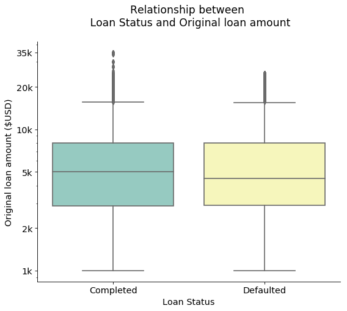

```python
# Create a boxplot to present the relationship between 'LoanStatus' and 'LoanOriginalAmount'.
plt.figure(figsize=(8, 6.5), dpi=80)

ax = sb.boxplot(data = df_sub, x = 'LoanStatus', y = 'LoanOriginalAmount', palette="Set3")

# Set figure title, y= 1.05 adds a little space between the title and the chart.
plt.title('Relationship between \n Loan Status and Original loan amount', fontsize= 15.5, y= 1.05)

# Only kept the bottom & left axes line.
ax.spines['top'].set_visible(False)
ax.spines['right'].set_visible(False)

# Define the x & y ticks/labels & scale
plt.yscale('log')
loan_ticks = [1000, 2000, 5000, 10000, 20000, 35000]
loan_labels = ['1k', '2k', '5k', '10k', '20k', '35k']
plt.xticks(fontsize= 13)
plt.xlabel('Loan Status', fontsize= 13)
plt.yticks(loan_ticks, loan_labels, fontsize= 13)
plt.ylabel('Original loan amount ($USD)', fontsize= 13);
```

As we can see, the distribution of original loan amount looks very similar among the two groups. Surprisingly, completed loans have a slightly higher median original loan amount (around \$5000) comapred to the defaulted loans (median around \\$4500). The Interquartile Range (IQR) is also quite similar among the two groups. However the range of original loan amount for the completed loans are larger than the defaulted loans.

**Moving forward, we will explore the relationship between 'LoanStatus' and 'MonthlyLoanPayment'.**  
Would defaulted loans have similar amount of monthly loan payments compared to the completed loans?  
Similar to above, for visualization of categorical vs numeric feature, boxplot would be a good choice.

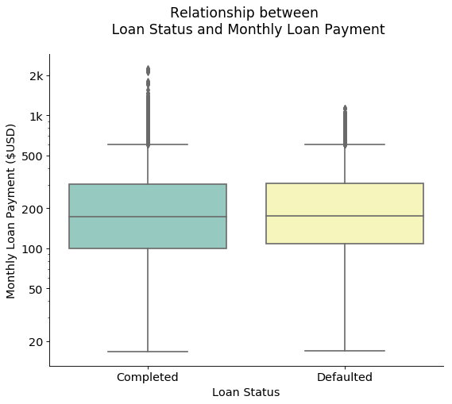

```python
# Create a boxplot to present the relationship between 'LoanStatus' and 'MonthlyLoanPayment'.
plt.figure(figsize=(8, 6.5), dpi=80)

ax = sb.boxplot(data = df_sub, x = 'LoanStatus', y = 'MonthlyLoanPayment', palette="Set3")

# Set figure title, y= 1.05 adds a little space between the title and the chart.
plt.title('Relationship between \n Loan Status and Monthly Loan Payment', fontsize= 15.5, y= 1.05)

# Only kept the bottom & left axes line.
ax.spines['top'].set_visible(False)
ax.spines['right'].set_visible(False)

# Define the x & y ticks/labels & scale
payment_ticks = [20, 50, 100, 200, 500, 1000, 2000]
payment_labels = ['20', '50', '100', '200', '500', '1k', '2k']
plt.yscale('log');
plt.xticks(fontsize= 13)
plt.xlabel('Loan Status', fontsize= 13)
plt.yticks(payment_ticks, payment_labels, fontsize= 13)
plt.ylabel('Monthly Loan Payment ($USD)', fontsize= 13);
```

```python
# Obatain summary statistics of 'MonthlyLoanPayment' by 'LoanStatus' groups.
df_sub.groupby('LoanStatus').MonthlyLoanPayment.describe()
```

| LoanStatus | count | mean | std | min | 25% | 50% | 75% | max |
| --- | --- | --- | --- | --- | --- | --- | --- | --- |
| Completed | 34356.0 | 225.524638 | 181.561468 | 16.70 | 99.930 | 173.555 | 302.14 | 2251.51 |
| Defaulted | 15284.0 | 234.804806 | 191.462703 | 17.01 | 107.875 | 173.710 | 306.15 | 1130.90 |

The graph above revealed similar distribution of the monthly loan payment between the completed and defaulted loans. Both groups have a median monthly loan payment of \$173 dollars per month. The Interquartile Range (IQR) of the completed loans are slightly larger than the defaulted loans. The range of monthly loan payment is also larger for the completed loan group which is consistant with the original loan amount distribution.

**Next, let's explore the relationship between 'LoanStatus' and 'CreditGrade'.**  
Would the distribution of Credit Grade look different between completed and defaulted loans? Since both 'LoanStatus' and 'CreditGrade' are categorical features, I will use a clustered barchart for visualization. As 'CreditGrade' is used to evaluate loans originated before July 2009, 'df_old_loans' dataset will be used. Also, I will calculate the 'CreditGrade' percentages within each 'LoanStatus' group and display them on top of each bar of the barchart.

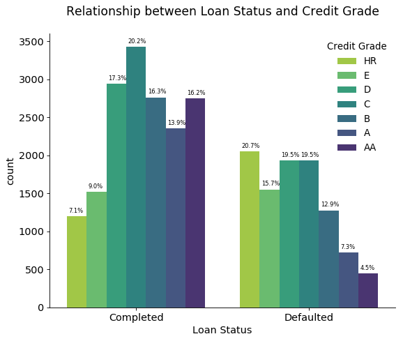

```python
# Create a clustered barchart to present the relationship between 'LoanStatus' and 'CreditGrade'.

plt.figure(figsize=(8, 6.5), dpi=80)

ax = sb.countplot(data = df_old_loans, x = 'LoanStatus', hue = 'CreditGrade', palette='viridis_r')

# Set figure title, y= 1.05 adds a little space between the title and the chart.
plt.title('Relationship between Loan Status and Credit Grade', fontsize= 15.5, y= 1.05)

# Add 'CreditGrade' percentage on top of 'Completed' loan bars.
total1 = len(df_old_loans.query('LoanStatus == "Completed"'))
for p in ax.patches[::2]:
    percentage = '{:.1f}%'.format(100 * p.get_height()/total1)
    width, height = p.get_width(), p.get_height()
    x, y = p.get_xy()
    ax.annotate(percentage, (x+0.01, y + height + 50), fontsize= 7.5)

# Add 'CreditGrade' percentage on top of 'Defaulted' loan bars.
total2 = len(df_old_loans.query('LoanStatus == "Defaulted"'))
for p in ax.patches[1::2]:
    percentage = '{:.1f}%'.format(100 * p.get_height()/total2)
    width, height = p.get_width(), p.get_height()
    x, y = p.get_xy()
    ax.annotate(percentage, (x+0.01, y + height + 50), fontsize= 7.5)

# Only kept the bottom & left axes line.
ax.spines['top'].set_visible(False)
ax.spines['right'].set_visible(False)

# Define the x & y ticks/labels
plt.xticks(fontsize= 13)
plt.xlabel('Loan Status', fontsize= 13)
plt.yticks(fontsize= 13)
plt.ylabel('count', fontsize= 13)
leg = ax.legend(frameon=False)
leg.set_title('Credit Grade',prop={'size':12});
```

Very interestingly, we see that the defaulted loans' Credit Grade seems to follow a right skewed distribution except for a lower percentage of grade 'E' loans. When compared to the completed loans, defaulted loans have much higher percentage of lower grade loans ('HR' and 'E' grade loans) and much lower percentage of higher grade loans ('A' and 'AA' grade loans). For example, defaulted loans have 20.7% 'HR' grade loans vs completed group: 7.1%. Defaulted loans have 15.7% 'E' grade loans vs completed group: 9.0%. Defaulted loans have 7.3% 'A' grade loans vs completed group: 13.9%. Defaulted loans have 4.5% 'AA' grade loans vs completed group: 16.2%. This indicates lower Credit Grade loans ('HR' and 'E') tend to have higher default rate, and higher Credit Grade loans ('A' and 'AA') tend to have lower default rate.

**Moving on, let's explore the relationship between 'LoanStatus' and 'ProsperRating (Alpha)'.**  
Would the defaulted group have more percentage of lower 'ProsperRating (Alpha)' rate loans? Since both 'LoanStatus' and 'ProsperRating (Alpha)' are categorical features, I will use a clustered barchart for visualization. As 'ProsperRating (Alpha)' is used to evaluate loans originated after July 2009, 'df_new_loans' dataset will be used. 'ProsperRating (Alpha)' percentages within each 'LoanStatus' group will be placed on top of each bar of the barchart.

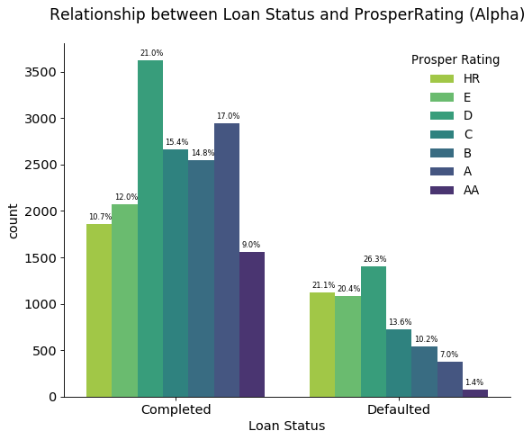

```python
# Create a clustered barchart to present the relationship between 'LoanStatus' and 'ProsperRating (Alpha)'.

plt.figure(figsize=(8, 6.5), dpi=80)

ax = sb.countplot(data = df_new_loans, x = 'LoanStatus', hue = 'ProsperRating (Alpha)', palette='viridis_r')

# Set figure title, y= 1.05 adds a little space between the title and the chart.
plt.title('Relationship between Loan Status and ProsperRating (Alpha)', fontsize= 15.5, y= 1.05)

# Add 'ProsperRating (Alpha)' percentage on top of 'Completed' loan bars.
total1 = len(df_new_loans.query('LoanStatus == "Completed"'))
for p in ax.patches[::2]:
    percentage = '{:.1f}%'.format(100 * p.get_height()/total1)
    width, height = p.get_width(), p.get_height()
    x, y = p.get_xy()
    ax.annotate(percentage, (x+0.01, y + height + 50), fontsize= 7.5)

# Add 'ProsperRating (Alpha)' percentage on top of 'Defaulted' loan bars.
total2 = len(df_new_loans.query('LoanStatus == "Defaulted"'))
for p in ax.patches[1::2]:
    percentage = '{:.1f}%'.format(100 * p.get_height()/total2)
    width, height = p.get_width(), p.get_height()
    x, y = p.get_xy()
    ax.annotate(percentage, (x+0.01, y + height + 50), fontsize= 7.5)

# Only kept the bottom & left axes line.
ax.spines['top'].set_visible(False)
ax.spines['right'].set_visible(False)

# Define the x & y ticks/labels
plt.xticks(fontsize= 13)
plt.xlabel('Loan Status', fontsize= 13)
plt.yticks(fontsize= 13)
plt.ylabel('count', fontsize= 13)
leg = ax.legend(frameon=False)
leg.set_title('Prosper Rating',prop={'size':12});
```

Interestingly, we also see that the defaulted loans' Prosper Rating seems to follow a right skewed distribution except for a higher percentage of rating 'D' loans. When compared to the completed loans, defaulted loans have much higher percentage of lower rating loans ('HR' and 'E' grade loans) and much lower percentage of higher rating loans ('A' and 'AA' grade loans) which is similar to the 'CreditGrade' vs 'LoanStatus' chart above.

Recall that previously we discovered Defaulted loans generally have a higher borrower rate. **It would be interesting to know what possible relationships are there between 'BorrowerRate' and 'CreditGrade'/'ProsperRating (Alpha)'.** Let's start with 'BorrowerRate' vs 'CreditGrade'. Since 'CreditGrade' is a categorical variable and 'BorrowerRate' is a numeric variable, I will use a boxplot to reveal the data.

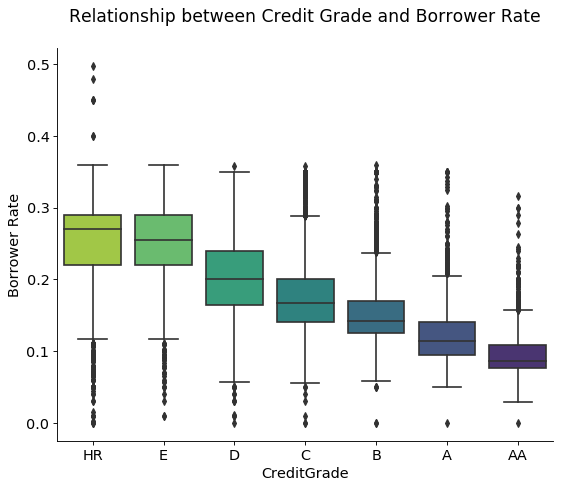

```python
# Create a boxplot to present the relationship between 'CreditGrade' and 'BorrowerRate'.
plt.figure(figsize=(8, 6.5), dpi=80)

ax = sb.boxplot(data = df_old_loans, x = 'CreditGrade', y = 'BorrowerRate', palette="viridis_r")

# Set figure title, y= 1.05 adds a little space between the title and the chart.
plt.title('Relationship between Credit Grade and Borrower Rate', fontsize= 15.5, y= 1.05)

# Only kept the bottom & left axes line.
ax.spines['top'].set_visible(False)
ax.spines['right'].set_visible(False)

# Define the x & y ticks/labels
plt.xticks(fontsize= 13)
plt.xlabel('CreditGrade', fontsize= 13)
plt.yticks(fontsize= 13)
plt.ylabel('Borrower Rate', fontsize= 13);
```

We see that as the Credit Grade increases in quality (from 'HR' to 'AA'), the median borrower rate gradually decreases from 0.28 to 0.10.

**Next, let's explore the relationship between 'BorrowerRate' and 'ProsperRating (Alpha)'.**  
Would higher 'ProsperRating (Alpha)' loans have lower 'BorrowerRate'?

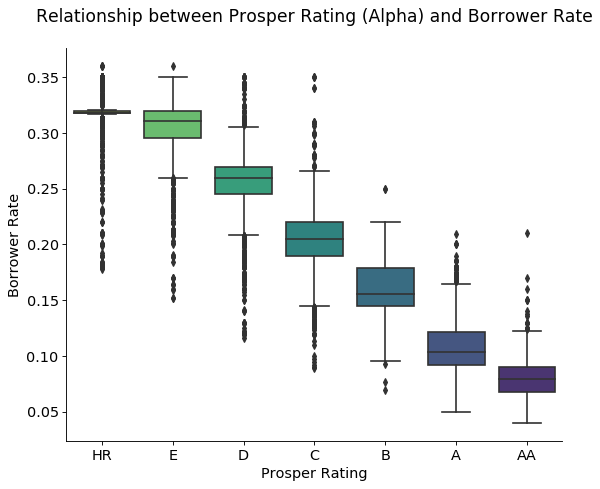

```python
# Create a boxplot to present the relationship between 'ProsperRating (Alpha)' and 'BorrowerRate'.
plt.figure(figsize=(8, 6.5), dpi=80)

ax = sb.boxplot(data = df_new_loans, x = 'ProsperRating (Alpha)', y = 'BorrowerRate', palette="viridis_r")

# Set figure title, y= 1.05 adds a little space between the title and the chart.
plt.title('Relationship between Prosper Rating (Alpha) and Borrower Rate', fontsize= 15.5, y= 1.05)

# Only kept the bottom & left axes line.
ax.spines['top'].set_visible(False)
ax.spines['right'].set_visible(False)

# Define the x & y ticks/labels
plt.xticks(fontsize= 13)
plt.xlabel('Prosper Rating', fontsize= 13)
plt.yticks(fontsize= 13)
plt.ylabel('Borrower Rate', fontsize= 13);
```

And indeed, the median borrower rate gradually decreases (from 0.32 to 0.08) as Prosper Rating increases (from 'HR' to 'AA').

**Next, I would like to know if there is any relationship between 'LoanOriginalAmount' and 'CreditGrade'/'ProsperRating (Alpha)'** Let's start with 'LoanOriginalAmount' and 'CreditGrade'. Since 'CreditGrade' is a categorical variable and 'LoanOriginalAmount' is a numeric variable, I will use a boxplot to reveal the data.

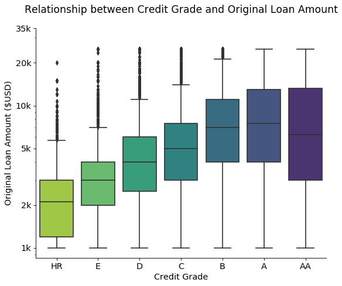

```python
# Create a boxplot to present the relationship between 'CreditGrade' and 'OriginalLoanAmount'.
plt.figure(figsize=(8, 6.5), dpi=80)

ax = sb.boxplot(data = df_old_loans, x = 'CreditGrade', y = 'LoanOriginalAmount', palette="viridis_r")

# Set figure title, y= 1.05 adds a little space between the title and the chart.
plt.title('Relationship between Credit Grade and Original Loan Amount', fontsize= 15.5, y= 1.05)

# Only kept the bottom & left axes line.
ax.spines['top'].set_visible(False)
ax.spines['right'].set_visible(False)

# Define the x & y ticks/labels
plt.yscale('log')
loan_ticks = [1000, 2000, 5000, 10000, 20000, 35000]
loan_labels = ['1k', '2k', '5k', '10k', '20k', '35k']
plt.xticks(fontsize= 13)
plt.xlabel('Credit Grade', fontsize= 13)
plt.yticks(loan_ticks, loan_labels, fontsize= 13)
plt.ylabel('Original Loan Amount ($USD)', fontsize= 13);
```

Interestingly, we see as the credit grade quality increases the median original loan amount forms an increasing trend, except the 'AA' grade loans.

**Moving on, let's explore the relationship between 'LoanOriginalAmount' and 'ProsperRating (Alpha)'**  
Would higher Prosper Rating loans also have larger original loan amounts?

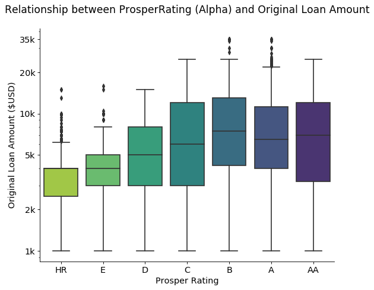

```python
# Create a boxplot to present the relationship between 'CreditGrade' and 'OriginalLoanAmount'.
plt.figure(figsize=(8, 6.5), dpi=80)

ax = sb.boxplot(data = df_new_loans, x = 'ProsperRating (Alpha)', y = 'LoanOriginalAmount', palette="viridis_r")

# Set figure title, y= 1.05 adds a little space between the title and the chart.
plt.title('Relationship between ProsperRating (Alpha) and Original Loan Amount', fontsize= 15.5, y= 1.05)

# Only kept the bottom & left axes line.
ax.spines['top'].set_visible(False)
ax.spines['right'].set_visible(False)

# Define the x & y ticks/labels
plt.yscale('log')
loan_ticks = [1000, 2000, 5000, 10000, 20000, 35000]
loan_labels = ['1k', '2k', '5k', '10k', '20k', '35k']
plt.xticks(fontsize= 13)
plt.xlabel('Prosper Rating', fontsize= 13)
plt.yticks(loan_ticks, loan_labels, fontsize= 13)
plt.ylabel('Original Loan Amount ($USD)', fontsize= 13);
```

And indeed as the Prosper Rating increases, a general increase trend of median original loan amount is observed.

### Talk about some of the relationships you observed in this part of the investigation. How did the feature(s) of interest vary with other features in the dataset?

I explored several relationships between my main feature of interest 'LoanStatus' and other features. Most interestingly, I found the defaulted loans generally have higher borrower rates compared to the completed loans. However, the distribution for Debt to Income Ratio, Original loan amount, Monthly loan payment looks similar between the defaulted loans and the completed loans. When I looked at 'CreditGrade' and 'ProsperRating (Alpha)' between the two groups, I found that the defaulted loans have much higher percentage of lower grade loans ('HR' and 'E' grade loans) and much lower percentage of higher grade loans ('A' and 'AA' grade loans). This indicates lower Credit Grade/Prosper Rating loans ('HR' and 'E') tend to have higher default rate, and higher Credit Grade/Prosper Rating loans ('A' and 'AA') tend to have lower default rate.

### Did you observe any interesting relationships between the other features (not the main feature(s) of interest)?

I explored the relationship between 'BorrowerRate' and 'CreditGrade'/'ProsperRating (Alpha)'. I found that as 'CreditGrade' or 'ProsperRating (Alpha)' increases, the median borrower rate gradually decreases which is quite interesting. I also explored the relationship between 'LoanOriginalAmount' and 'CreditGrade'/'ProsperRating (Alpha)' and found that as the 'CreditGrade' or 'ProsperRating (Alpha)' increases, the median original loan amount forms a general increases trend.

## Multivariate Exploration

Previously we looked at pairwise relationships between 'LoanStatus' vs 'BorrowerRate', 'LoanStatus' vs 'CreditGrade'/'ProsperRating (Alpha)', and 'BorrowerRate' vs 'CreditGrade'/'ProsperRating (Alpha)'. We found that defaulted loans tend to have higher borrower rates compared to completed loans. We also discovered higher Credit Grades or Prosper Rating (Alpha) tend to have lower borrower rates.**Would there be any differences in borrower rates between completed loans and defaulted loans in each sub-Credit Grade or sub-Prosper Rating (Alpha) category?** In order to find out, we can look at the relationships between 'LoanStatus', 'BorrowerRate' and 'CreditGrade'/'ProsperRating (Alpha)' in a multivariate plot. I will use pointplot to depict the relationships as 'LoanStatus', 'CreditGrade'/'ProsperRating (Alpha)' are categorical features, while 'BorrowerRate' is numeric.

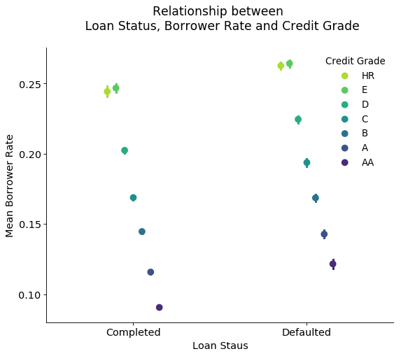

```python
# Create a pointplot to present the relationship between 'LoanStatus', 'CreditGrade' and 'BorrowerRate'.
plt.figure(figsize=(8, 6.5), dpi=80)

ax = sb.pointplot(data = df_sub, x= 'LoanStatus', y= 'BorrowerRate', hue= 'CreditGrade', linestyles="", dodge = 0.3, palette="viridis_r");

# Set figure title, y= 1.05 adds a little space between the title and the chart.
plt.title('Relationship between \n Loan Status, Borrower Rate and Credit Grade', fontsize= 15.5, y= 1.05)

# Only kept the bottom & left axes line.
ax.spines['top'].set_visible(False)
ax.spines['right'].set_visible(False)

# Define the x & y ticks/labels
tick_pos = [0.10, 0.15, 0.20, 0.25]
tick_label = ['{:0.2f}'.format(x) for x in tick_pos]
plt.xticks(fontsize= 13)
plt.xlabel('Loan Staus', fontsize= 13)
plt.yticks(tick_pos,tick_label, fontsize= 13)
plt.ylabel('Mean Borrower Rate', fontsize= 13)
leg = ax.legend(frameon=False)
leg.set_title('Credit Grade',prop={'size':12});
```

We see that for both the completed and defaulted loans, grade 'HR' and grade 'E' loans have the highest mean borrower rate. And as Credit Grade increases in quality, the mean borrower rate tend to be lower (except for 'HR' vs 'E' loans). Interestingly, the defaulted loans have higher mean borrower rate in every Credit Grade compared to the completed loans.

**Next, we will build another pointplot to depict the relationships between 'LoanStatus', 'ProsperRating (Alpha)' and 'BorrowerRate' as below.**

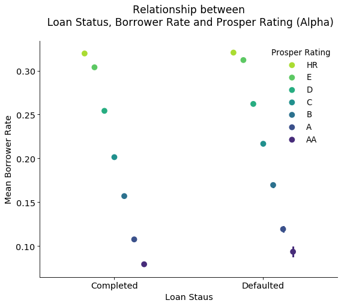

```python
# Create a pointplot to present the relationship between 'LoanStatus', 'ProsperRating (Alpha)' and 'OriginalLoanAmount'.
plt.figure(figsize=(8, 6.5), dpi=80)

ax = sb.pointplot(data = df_sub, x= 'LoanStatus', y= 'BorrowerRate', hue= 'ProsperRating (Alpha)', linestyles="", dodge = 0.4, palette="viridis_r");

# Set figure title, y= 1.05 adds a little space between the title and the chart.
plt.title('Relationship between\n Loan Status, Borrower Rate and Prosper Rating (Alpha)', fontsize= 15.5, y= 1.05)

# Only kept the bottom & left axes line.
ax.spines['top'].set_visible(False)
ax.spines['right'].set_visible(False)

# Define the x & y ticks/labels
plt.xticks(fontsize= 13)
plt.xlabel('Loan Staus', fontsize= 13)
plt.yticks(fontsize= 13)
plt.ylabel('Mean Borrower Rate', fontsize= 13)
leg = ax.legend(frameon=False)
leg.set_title('Prosper Rating',prop={'size':12});
```

Very interestingly, similar trends were observed in this multivariate plot. Prosper Rating 'HR' and 'E' loans have the highest mean borrower rate. And as Prosper Rating increases in quality, the mean borrower rate became lower. Defaulted loans tend to have higher mean borrower rate in every Prosper Rating compared to the completed loans (except for 'HR' rating loans).

Previously, we also found that the distribution of original loan amount looks very similar for defaulted and completed loans. And as Credit Grade/Prosper Rating (Alpha) increases, the median original loan amount also increases. **Would there be any differences in original loan amount between completed loans and defaulted loans in each sub-Credit Grade or sub-Prosper Rating (Alpha) category?** We can plot variables 'LoanStatus', 'CreditGrade'/'ProsperRating (Alpha)', 'LoanOriginalAmount' together in a multivariate pointplot to find out.

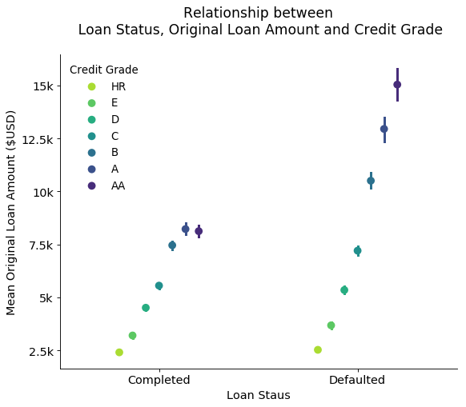

```python
# Create a pointplot to present the relationship between 'LoanStatus', 'CreditGrade' and 'LoanOriginalAmount'.
plt.figure(figsize=(8, 6.5), dpi=80)

ax = sb.pointplot(data = df_sub, x= 'LoanStatus', y= 'LoanOriginalAmount', hue= 'CreditGrade', linestyles="", dodge = 0.4, palette="viridis_r");

# Set figure title, y= 1.05 adds a little space between the title and the chart.
plt.title('Relationship between\n Loan Status, Original Loan Amount and Credit Grade', fontsize= 15.5, y= 1.05)

# Only kept the bottom & left axes line.
ax.spines['top'].set_visible(False)
ax.spines['right'].set_visible(False)

# Define the x & y ticks/labels
loan_ticks = [2500, 5000, 7500, 10000, 12500, 15000]
loan_labels = ['2.5k', '5k', '7.5k', '10k', '12.5k', '15k']
plt.xticks(fontsize= 13)
plt.xlabel('Loan Staus', fontsize= 13)
plt.yticks(loan_ticks, loan_labels, fontsize= 13)
plt.ylabel('Mean Original Loan Amount ($USD)', fontsize= 13)
leg = ax.legend(frameon=False)
leg.set_title('Credit Grade',prop={'size':12});
```

As we can see, there is a positive relationship between Credit Grade and Mean Originial Loan Amount. As Credit Grade increases in quality, the Mean Originial Loan Amount also increases in both the Defaulted and Completed loan groups. However, we can clearly see that for each Credit Grade defaulted loans have higher Mean Originial Loan Amount. This trend is most obvious in the grade 'B', 'A' and 'AA' loans.

**Next, we will use another pointplot to depict the relationships between 'LoanStatus', 'ProsperRating (Alpha)' and 'LoanOriginalAmount'.**

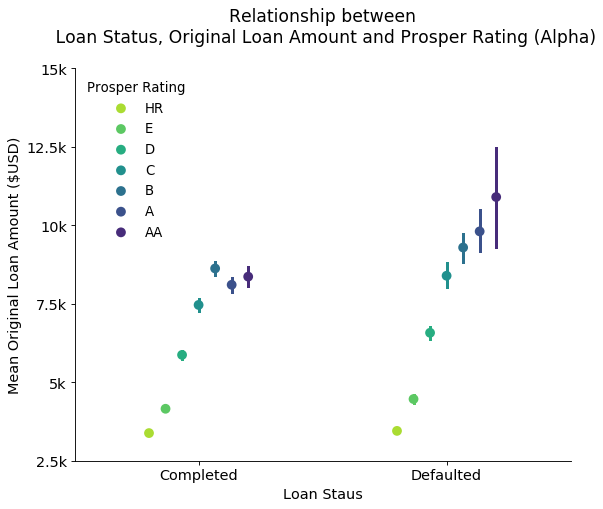

```python
# Create a pointplot to present the relationship between 'LoanStatus', 'CreditGrade' and 'LoanOriginalAmount'.
plt.figure(figsize=(8, 6.5), dpi=80)

ax = sb.pointplot(data = df_sub, x= 'LoanStatus', y= 'LoanOriginalAmount', hue= 'ProsperRating (Alpha)', linestyles="", dodge = 0.4, palette="viridis_r");

# Set figure title, y= 1.05 adds a little space between the title and the chart.
plt.title('Relationship between\n Loan Status, Original Loan Amount and Prosper Rating (Alpha)', fontsize= 15.5, y= 1.05)

# Only kept the bottom & left axes line.
ax.spines['top'].set_visible(False)
ax.spines['right'].set_visible(False)

# Define the x & y ticks/labels
loan_ticks = [2500, 5000, 7500, 10000, 12500, 15000]
loan_labels = ['2.5k', '5k', '7.5k', '10k', '12.5k', '15k']
plt.xticks(fontsize= 13)
plt.xlabel('Loan Staus', fontsize= 13)
plt.yticks(loan_ticks, loan_labels, fontsize= 13)
plt.ylabel('Mean Original Loan Amount ($USD)', fontsize= 13)
leg = ax.legend(frameon=False)
leg.set_title('Prosper Rating',prop={'size':12});
```

Similar trends were seen with 'ProsperRating (Alpha)'. As the Prosper rating increases, the Mean Original Loan Amount also tend to increase in both the Defaulted and Completed loan groups. Compared to the completed loans, the defaulted loan group have a higher Mean Original Loan Amount. The differences are most obvious in the Prosper Rating 'B', 'A' and 'AA' loans. I also noticed the Mean Original Loan Amount differences between defaulted and completed loans for Credit Grade 'B', 'A' and 'AA' loans are larger.

**Finally, we will explore whether 'MonthlyLoanPayment' would also be higher in each sub-Credit Grade or sub-Prosper Rating (Alpha) category for the defaulted loan group.** This might not be the case as Original Loan Amount is not the only factor affecting monthly loan payments. Let's find out with another pointplot.

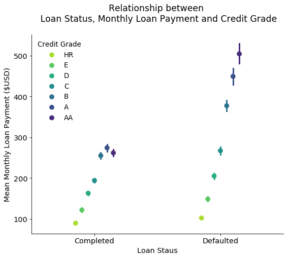

```python
# Create a pointplot to present the relationship between 'LoanStatus', 'CreditGrade' and 'MonthlyLoanPayment'.
plt.figure(figsize=(8, 6.5), dpi=80)

ax = sb.pointplot(data = df_sub, x= 'LoanStatus', y= 'MonthlyLoanPayment', hue= 'CreditGrade', linestyles="", dodge = 0.3, palette="viridis_r");

# Set figure title, y= 1.05 adds a little space between the title and the chart.
plt.title('Relationship between \n Loan Status, Monthly Loan Payment and Credit Grade', fontsize= 15.5, y= 1.05)

# Only kept the bottom & left axes line.
ax.spines['top'].set_visible(False)
ax.spines['right'].set_visible(False)

# Define the x & y ticks/labels

plt.xticks(fontsize= 13)
plt.xlabel('Loan Staus', fontsize= 13)
plt.yticks(fontsize= 13)
plt.ylabel('Mean Monthly Loan Payment ($USD)', fontsize= 13)
leg = ax.legend(frameon=False)
leg.set_title('Credit Grade',prop={'size':12});
```

Very interestingly, we see a positive relationship between Credit Grade and Mean Monthly Loan Payment amounts. As Credit Grade increases in quality, the Mean Monthly Loan Payment amount also increases in both the completed and defaulted loans. And we do see that the defaulted loans indeed have higher Mean Monthly Loan Payment in every Credit Grade sub-group! Again, the differences are most obvious in Grade 'B', 'A' and 'AA' loans. Let's see if we could see a similar trend with 'ProsperRating (Alpha)'.

**Build a pointplot to depict the relationships between 'LoanStatus', 'ProsperRating (Alpha)' and 'MonthlyLoanPayment'.**

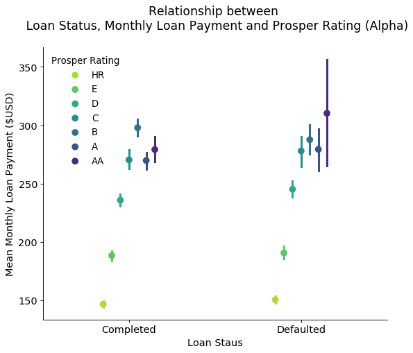

```python
# Create a pointplot to present the relationship between 'LoanStatus', 'ProsperRating (Alpha)' and 'MonthlyLoanPayment'.
plt.figure(figsize=(8, 6.5), dpi=80)

ax = sb.pointplot(data = df_sub, x= 'LoanStatus', y= 'MonthlyLoanPayment', hue= 'ProsperRating (Alpha)', linestyles="", dodge = 0.3, palette="viridis_r");

# Set figure title, y= 1.05 adds a little space between the title and the chart.
plt.title('Relationship between \n Loan Status, Monthly Loan Payment and Prosper Rating (Alpha)', fontsize= 15.5, y= 1.05)

# Only kept the bottom & left axes line.
ax.spines['top'].set_visible(False)
ax.spines['right'].set_visible(False)

# Define the x & y ticks/labels

plt.xticks(fontsize= 13)
plt.xlabel('Loan Staus', fontsize= 13)
plt.yticks(fontsize= 13)
plt.ylabel('Mean Monthly Loan Payment ($USD)', fontsize= 13)
leg = ax.legend(frameon=False)
leg.set_title('Prosper Rating',prop={'size':12});
```

From the graph above, we see that as Prosper Rating increases from 'HR' to 'C', the Mean Monthly Loan Payment also increases in both the completed and defaulted loan groups. However, there is a slight decrease in Mean Monthly Loan Payment for rating 'A' loans, then another increase for 'AA' loans. Compared to the Completed loan group, the Defaulted loans only have a slight increase in Mean Monthly Loan Payment in Prosper Rating 'HR', 'E', 'D', 'C', 'A', 'AA' loans. For 'B' rating loans, the Mean Monthly Loan Payment is actually lower in the Defaulted group.

### Talk about some of the relationships you observed in this part of the investigation. Were there features that strengthened each other in terms of looking at your feature(s) of interest?

In the multivariate exploration part, I first explored the effects of Loan Status, Credit Grade/Prosper Rating on Borrower Rate. I found that for both the completed and defaulted loans, lower Credit grade 'HR' and 'E' loans have the highest Mean Borrower Rate. And as Credit Grade increases in quality (from 'HR' to 'AA'), the Mean Borrower Rate tend to be lower (except for 'HR' vs 'E' loans). Interestingly, the defaulted loans have higher Mean Borrower Rate in every Credit Grade compared to the completed loans. I also discovered lower Prosper Rating 'HR' and 'E' loans have the highest Mean Borrower Rate. And as Prosper Rating increases in quality (from 'HR' to 'AA'), the Mean Borrower Rate became lower. Very interestingly, Defaulted loans also tend to have higher Mean Borrower Rate in every Prosper Rating category compared to the completed loans (except for 'HR' rating loans). Then I investigated the effects of Loan Status, Credit Grade/Prosper Rating on Originial Loan Amount. I found a positive relationship between Credit Grade and Mean Originial Loan Amount. As Credit Grade increases in quality, the Mean Originial Loan Amount also increases in both the Defaulted and Completed loan groups. However for each Credit Grade, defaulted loans have higher Mean Originial Loan Amount. And this trend is most obvious in the grade 'B', 'A' and 'AA' loans. I also discovered as Prosper rating increases, the Mean Original Loan Amount also tend to increase in both the Defaulted and Completed loan groups. Compared to the completed loans, the defaulted loan group have a higher Mean Original Loan Amount. The differences are most obvious in the Prosper Rating 'B', 'A' and 'AA' loans. I noticed the Mean Original Loan Amount differences between defaulted and completed loans for Credit Grade 'B', 'A' and 'AA' loans were larger. Finally, I looked into the effects of Loan Status, Credit Grade/Prosper Rating on monthly loan payment. I saw a positive relationship between Credit Grade and Mean Monthly Loan Payment amounts. As Credit Grade increases in quality, the Mean Monthly Loan Payment amount also increases in both the completed and defaulted loans. Defaulted loans indeed have higher Mean Monthly Loan Payment in every Credit Grade sub-group. Again, the differences are most obvious in Grade 'B', 'A' and 'AA' loans. I also found that as Prosper Rating increases from 'HR' to 'C', the Mean Monthly Loan Payment also increases in both the completed and defaulted loan groups. However, there is a slight decrease in Mean Monthly Loan Payment for rating 'A' loans, then another increase for 'AA' loans. Compared to the Completed loan group, the Defaulted loans only have a slight increase in Mean Monthly Loan Payment in Prosper Rating 'HR', 'E', 'D', 'C', 'A', 'AA' loans. And for 'B' rating loans, the Mean Monthly Loan Payment is actually lower in the Defaulted group.

### Were there any interesting or surprising interactions between features?

I found the interaction between Loan Status, Credit Grade/Prosper Rating on Borrower Rate quite interesting and used it as my Explainatory analysis presentation.